# SENSITIVITY ANALYSES II (missing assessments not removed)- Beyond main effects? Affect level as a moderator in the relation between affect dynamics and depressive symptoms

Dominique F. Maciejewski

24 augustus, 2023

This is the sensitivity analysis for the main findings of the paper, where no missing assessments were removed for the calculation of affect dynamics.

# 1 LIBRARY

```r
options(scipen=999) #to prevent scientific notation


library(haven)  #for reading in SPSS files
library(esmpack) #for data preparation of ESM data
library(data.table) #for data.tables, subsetting
library(psych) #for descriptives and affective dynamics calculations (count, M, SD)
library(DescTools) #for winsorizing outliers
library(tibble) #for reshaping
library(tidyverse) #for data wrangling
library(Hmisc) #for correlations
library(here) #for finding files
library(plyr) #for data wrangling
```

```r
library(dplyr)#for data wrangling
library(ggplot2) #for data visualization
library(ggpubr) #for data visualization
library(lme4) #for autocorrelation and ICCs
library(optimx) #optimizer for MLM models
library(lavaan) #for MCFA's
library(performance) #for ICC
library(fastDummies) #for making dummy variables
library(multilevelTools) #for omega calculation
library(pander) #for tables
library(knitr) #for tables
library(interactions) #for Johnson-Neyman
library(apaTables) #for apaTables
library(jtools) #for nice regression tables
library(car) #for VIF
library(metafor) #for pooled correlations
set.alignment('left', row.names = 'right') #for alignment of tables
```

# 2 FUNCTIONS

```r
#######FUNCTION 1: add missing days after each day/week (Daily Diary/ESM)
##this is important, because for the MSSD, we do not want to calculate the
##difference between the last beep of one day/week and the first beep of the next day/week
##For the autocorrelation, the lagged function from the esmpack takes care of that automatically

insert_NA <- function(df, ...){
  df_selected <- df %>% dplyr::select(...) %>% unique()
  result <- plyr::rbind.fill(df, df_selected) %>%
    dplyr::arrange(...)
  return(result)
}

#######FUNCTION 2: MSSD
##from https://quantdev.ssri.psu.edu/tutorials/analysis-experience-sampling-ema-data-chapter-22-univariate-intraindividual-variability

my.mssd <- function(data)
{
    diffToNext<-data[2:length(data)]-data[1:(length(data)-1)] #this computes the difference between each value and the next
    diffToNext2<-diffToNext^2                  #this squares the difference
    SSdiff<- sum(diffToNext2,na.rm=TRUE)       #this takes the sum of the squared differences
    denominator<-sum(!is.na(diffToNext))       #this computes the number of non-missing elements (denominator)
                                               #which corresponds to the t-1 value
    mssd<-sqrt(SSdiff/denominator)             #this computes the rMSSD
    return(mssd)
}

#######FUNCTION 3: Cohen's f2
##to calculate the effect size of regression models. From https://stackoverflow.com/questions/72229235/cohens-f2-in-r
cohen_f2 <- function(fit, fit2){
  R2 <- summary(fit)$r.squared
  if(missing(fit2)) {
    R2/(1 - R2)
  } else {
    R2B <- summary(fit2)$r.squared
    (R2B - R2)/(1 - R2B)
  }
}
```

# 3 DATAPREPARATION PER DATASET

## 3.1 DATASET 1 - RADAR

### 3.1.1 Read in data and datapreparation

```r
####################### Read in data #######################
dataset1_RADAR_processed<-read.csv(here::here("data", "2_processed_data_for_OSF", "dataset1_RADAR_processed.csv"), sep=",",
                             na.strings="NA")

####################### number of participants with valid Daily Diary data #####################
dataset1_RADAR_processed$count<-calc.nomiss(PAff, ID, dataset1_RADAR_processed, prop=FALSE, expand=TRUE)
range(dataset1_RADAR_processed$count)
```

```
## [1]  0 75
```

```r
# exclude those with not valid daily diary data
n_RADAR_orig<-nsub(ID, dataset1_RADAR_processed)
n_RADAR_orig
```

```
## [1] 497
```

```r
dataset1_RADAR_processed <-subset(dataset1_RADAR_processed, count > 0)
range(dataset1_RADAR_processed$count)
```

```
## [1]  1 75
```

```r
n_RADAR_orig<-nsub(ID, dataset1_RADAR_processed)
n_RADAR_orig
```

```
## [1] 487
```

### 3.1.2 Exclusion and Compliance

```r
##################### Details study design #####################
#### Total beeps ####
tot_ass_RADAR<-75
#### Total weeks ####
tot_weeks_RADAR <- 15
#### Total beeps per day ####
tot_b_d_RADAR<-1

#### Number of valid beeps before exclusion ####
mean(calc.mean(count, ID, data=dataset1_RADAR_processed))
```

```
## [1] 45.94867
```

```r
#### Percentage of valid beeps before exclusion ####
dataset1_RADAR_processed$perc<-100*(calc.nomiss(PAff, ID, dataset1_RADAR_processed, prop=TRUE, expand=TRUE))
mean(calc.mean(perc, ID, data=dataset1_RADAR_processed))
```

```
## [1] 61.26489
```

```r
###### Removing participants with compliance below 33% ####  ####

## 33% of beeps ##
valbeep_RADAR <- (tot_ass_RADAR/100)*33
valbeep_RADAR
```

```
## [1] 24.75
```

```r
## excluding those with fewer than 33% ##
dataset1_RADAR_processed <-subset(dataset1_RADAR_processed, count > valbeep_RADAR)



#### Delete participants without any variance on NAff and PAff ####
## n before ##
nsub(ID, dataset1_RADAR_processed)
```

```
## [1] 372
```

```r
## deleting ##
dataset1_RADAR_processed <- check.timeinvar(NAff, ID, dataset1_RADAR_processed, out = 3)
dataset1_RADAR_processed <- check.timeinvar(PAff, ID, dataset1_RADAR_processed, out = 3)


## n after ##
nsub(ID, dataset1_RADAR_processed) #no participants excluded
```

```
## [1] 372
```

```r
#### final sample ####
n_fin_RADAR<-nsub(ID, dataset1_RADAR_processed)
n_fin_RADAR #number
```

```
## [1] 372
```

```r
perc_inc_RADAR <- (100/n_RADAR_orig)*n_fin_RADAR
perc_inc_RADAR #percentage
```

```
## [1] 76.38604
```

```r
#### mean of valid beeps per participant ####
mean_comp_RADAR<-mean(calc.mean(count, ID, data=dataset1_RADAR_processed))
mean_comp_RADAR
```

```
## [1] 56.52151
```

```r
#### percentage of valid beeps per participant ####
mean_com_per_RADAR<-mean(calc.mean(perc, ID, data=dataset1_RADAR_processed))
mean_com_per_RADAR
```

```
## [1] 75.36201
```

### 3.1.3 Calculation of affective dynamics

#### 3.1.3.1 Datapreparation

```r
#####################  sort by ID and time #####################
dataset1_RADAR_processed<-dataset1_RADAR_processed[order(dataset1_RADAR_processed$ID,dataset1_RADAR_processed$time) , ]

##################### subset most important variables #####################
dataset1_RADAR_processed_affdyn <- subset(dataset1_RADAR_processed, select=c("ID","time","week","PAff","NAff"))


##################### make a new time variable #####################
dataset1_RADAR_processed_affdyn<-dataset1_RADAR_processed_affdyn %>% group_by(ID) %>% dplyr::mutate(time = rank(time, ties.method = 'first'))%>% arrange(time)

##################### add missing days after each week #####################
#this is important, because for the MSSD, we do not want to calculate the
#difference between the last beep of one day and the first beep of the next day/week
dataset1_RADAR_processed_affdyn_NA <-insert_NA(dataset1_RADAR_processed_affdyn, ID, week)
```

#### 3.1.3.2 Calculation

For count, M, SD, MSSD, see https://quantdev.ssri.psu.edu/tutorials/analysis-experience-sampling-ema-data-chapter-22-univariate-intraindividual-variability

For autocorrelation, see de Haan-Rietdijk et al. (2016)

```r
##################### Calculate affective dynamics #####################
#### Mean, SD ####

aff_dyn_RADAR <- ddply(dataset1_RADAR_processed_affdyn_NA, "ID",  plyr::summarize,
                           icountNA = sum(!is.na(NAff)),  #count of observations
                           imeanNA  = mean(NAff, na.rm=TRUE), #imean (continuous)
                           isdNA   = sd(NAff, na.rm=TRUE), #isd (continuous)
                           icountPA = sum(!is.na(PAff)),  #count of observations
                           imeanPA  = mean(PAff, na.rm=TRUE), #imean (continuous)
                           isdPA    = sd(PAff, na.rm=TRUE)   #isd   (continuous)
                           )

#### MSSD ####
mssd.stats.NA <- ddply(dataset1_RADAR_processed_affdyn_NA, "ID", plyr::summarize, iMSSDNA=my.mssd(NAff))
mssd.stats.PA <- ddply(dataset1_RADAR_processed_affdyn_NA, "ID", plyr::summarize, iMSSDPA=my.mssd(PAff))

aff_dyn_RADAR <- merge(aff_dyn_RADAR,mssd.stats.NA,by="ID",all=TRUE)
aff_dyn_RADAR <- merge(aff_dyn_RADAR,mssd.stats.PA,by="ID",all=TRUE)


#### autocorrelation ####

## Lagged effect ##
dataset1_RADAR_processed_affdyn$NAff_lag<-lagvar(NAff, id=ID, obs=time, day=week,data=dataset1_RADAR_processed_affdyn)
dataset1_RADAR_processed_affdyn$PAff_lag<-lagvar(PAff, id=ID, obs=time, day=week,data=dataset1_RADAR_processed_affdyn)

## Mixed model ##
auto_NA <- lmer(NAff ~ 1 + NAff_lag + (1 + NAff_lag | ID),
                     data = dataset1_RADAR_processed_affdyn, REML = TRUE,
                     control = lmerControl(optimizer ='optimx', optCtrl=list(method='nlminb')))
summary(auto_NA)
```

```
## Linear mixed model fit by REML ['lmerMod']
## Formula: NAff ~ 1 + NAff_lag + (1 + NAff_lag | ID)
##    Data: dataset1_RADAR_processed_affdyn
## Control: lmerControl(optimizer = "optimx", optCtrl = list(method = "nlminb"))
##
## REML criterion at convergence: 38603.9
##
## Scaled residuals:
##     Min      1Q  Median      3Q     Max
## -6.1872 -0.3973 -0.1143  0.2377  8.0515
##
## Random effects:
##  Groups   Name        Variance Std.Dev. Corr
##  ID       (Intercept) 0.28452  0.5334
##           NAff_lag    0.04438  0.2107   -0.44
##  Residual             0.73477  0.8572
## Number of obs: 14727, groups:  ID, 372
##
## Fixed effects:
##             Estimate Std. Error t value
## (Intercept)  1.09136    0.03361   32.47
## NAff_lag     0.43373    0.01473   29.45
##
## Correlation of Fixed Effects:
##          (Intr)
## NAff_lag -0.599
```

```r
auto_PA <- lmer(PAff ~ 1 + PAff_lag + (1 + PAff_lag | ID),
                     data = dataset1_RADAR_processed_affdyn, REML = TRUE,
                     control = lmerControl(optimizer ='optimx', optCtrl=list(method='nlminb')))
summary(auto_PA)
```

```
## Linear mixed model fit by REML ['lmerMod']
## Formula: PAff ~ 1 + PAff_lag + (1 + PAff_lag | ID)
##    Data: dataset1_RADAR_processed_affdyn
## Control: lmerControl(optimizer = "optimx", optCtrl = list(method = "nlminb"))
##
## REML criterion at convergence: 46743.9
##
## Scaled residuals:
##     Min      1Q  Median      3Q     Max
## -6.8126 -0.3998  0.0755  0.4966  4.5267
##
## Random effects:
##  Groups   Name        Variance Std.Dev. Corr
##  ID       (Intercept) 1.91934  1.3854
##           PAff_lag    0.03208  0.1791   -0.87
##  Residual             1.27866  1.1308
## Number of obs: 14727, groups:  ID, 372
##
## Fixed effects:
##             Estimate Std. Error t value
## (Intercept)  4.18355    0.09401   44.50
## PAff_lag     0.40242    0.01251   32.17
##
## Correlation of Fixed Effects:
##          (Intr)
## PAff_lag -0.920
```

```r
## Extract individual slopes ##
beta_NA<-tibble::rownames_to_column(coef(auto_NA)$ID)
beta_NA<-plyr::rename(beta_NA,
                c("NAff_lag" = "autocorNA",
                  "rowname" =  "ID"))

beta_PA<-tibble::rownames_to_column(coef(auto_PA)$ID)
beta_PA<-plyr::rename(beta_PA,
                c("PAff_lag" = "autocorPA",
                  "rowname" =  "ID"))


##################### Merge data #####################
aff_dyn_RADAR <- merge(aff_dyn_RADAR,beta_NA,by="ID",all=TRUE)
aff_dyn_RADAR <- merge(aff_dyn_RADAR,beta_PA,by="ID",all=TRUE)

##################### Delete intercept from aff_dyn files #####################
aff_dyn_RADAR<-subset(aff_dyn_RADAR, select=c(1:9,11,13))
names(aff_dyn_RADAR)
```

```
##  [1] "ID"        "icountNA"  "imeanNA"   "isdNA"     "icountPA"  "imeanPA"
##  [7] "isdPA"     "iMSSDNA"   "iMSSDPA"   "autocorNA" "autocorPA"
```

### 3.1.4 Merging

```r
##################### restructure depression/demographics data #####################
#The dataset was in longformat, however the affective dynamics measures are in wide format
#Thus, I restructure the dataset (which only contain time-invariant variables anyway)
#and merge with the affective dynamics data
data_id_dep_RADAR <- subset(dataset1_RADAR_processed, select=c("ID","Sex","Age","DepB","DepF"))
data_id_dep_RADAR<-data_id_dep_RADAR %>% group_by(ID) %>% summarise_all(mean)

##################### Merge affective dynamics and depression/demographics data #####################
datasetRADAR_final <- merge(data_id_dep_RADAR,aff_dyn_RADAR,by="ID",all=TRUE)
names(datasetRADAR_final)
```

```
##  [1] "ID"        "Sex"       "Age"       "DepB"      "DepF"      "icountNA"
##  [7] "imeanNA"   "isdNA"     "icountPA"  "imeanPA"   "isdPA"     "iMSSDNA"
## [13] "iMSSDPA"   "autocorNA" "autocorPA"
```

### 3.1.5 Winzorising and transformation of skewed variables

```r
##################### winsorizing #####################
names(datasetRADAR_final)
```

```
##  [1] "ID"        "Sex"       "Age"       "DepB"      "DepF"      "icountNA"
##  [7] "imeanNA"   "isdNA"     "icountPA"  "imeanPA"   "isdPA"     "iMSSDNA"
## [13] "iMSSDPA"   "autocorNA" "autocorPA"
```

```r
datasetRADAR_final<-datasetRADAR_final[order(datasetRADAR_final$ID) , ]

psych::describe(datasetRADAR_final)
```

```
##           vars   n   mean     sd median trimmed    mad   min    max  range
## ID*          1 372 186.50 107.53 186.50  186.50 137.88  1.00 372.00 371.00
## Sex          2 372   0.43   0.50   0.00    0.42   0.00  0.00   1.00   1.00
## Age          3 372  13.01   0.44  13.01   12.99   0.41 11.68  15.56   3.88
## DepB         4 368   1.63   0.49   1.52    1.57   0.45  1.00   3.70   2.70
## DepF         5 334   1.58   0.54   1.43    1.51   0.48  1.00   3.83   2.83
## icountNA     6 372  56.52  12.17  58.00   57.60  13.34 25.00  75.00  50.00
## imeanNA      7 372   2.12   1.03   1.84    1.97   0.89  1.00   6.26   5.26
## isdNA        8 372   0.89   0.53   0.81    0.85   0.58  0.01   2.66   2.64
## icountPA     9 372  56.52  12.17  58.00   57.60  13.34 25.00  75.00  50.00
## imeanPA     10 372   6.92   1.11   6.89    6.92   1.29  4.24   8.99   4.75
## isdPA       11 372   1.20   0.52   1.15    1.17   0.48  0.08   3.44   3.36
## iMSSDNA     12 372   0.92   0.55   0.82    0.88   0.53  0.02   2.97   2.96
## iMSSDPA     13 372   1.31   0.61   1.19    1.27   0.54  0.08   4.57   4.49
## autocorNA   14 372   0.43   0.16   0.41    0.43   0.13 -0.01   0.88   0.89
## autocorPA   15 372   0.40   0.13   0.40    0.40   0.11 -0.10   0.91   1.01
##            skew kurtosis   se
## ID*        0.00    -1.21 5.58
## Sex        0.27    -1.93 0.03
## Age        0.87     2.89 0.02
## DepB       1.07     1.04 0.03
## DepF       1.26     1.51 0.03
## icountNA  -0.67    -0.27 0.63
## imeanNA    1.19     0.89 0.05
## isdNA      0.59    -0.24 0.03
## icountPA  -0.67    -0.27 0.63
## imeanPA    0.04    -0.82 0.06
## isdPA      0.66     1.18 0.03
## iMSSDNA    0.84     0.65 0.03
## iMSSDPA    0.97     2.12 0.03
## autocorNA  0.30     0.13 0.01
## autocorPA -0.14     1.19 0.01
```

```r
dataRADAR_finalW<-data.frame(datasetRADAR_final)

#select predictors and outcome variables (affective dynamics and depression)
predictor_wins<-c(4,5,7,8,10:15)

#winsorizing
dataRADAR_finalW<-apply(dataRADAR_finalW[,predictor_wins],
                                 2,
                                 Winsorize, probs=c(0.01,0.99), na.rm = TRUE)



dataRADAR_finalW<-data.frame(dataRADAR_finalW)

psych::describe(dataRADAR_finalW)
```

```
##           vars   n mean   sd median trimmed  mad  min  max range  skew kurtosis
## DepB         1 368 1.62 0.47   1.52    1.57 0.45 1.00 3.00  2.00  0.89     0.16
## DepF         2 334 1.58 0.53   1.43    1.51 0.48 1.00 3.29  2.29  1.09     0.62
## imeanNA      3 372 2.11 1.02   1.84    1.97 0.89 1.01 5.04  4.03  1.09     0.38
## isdNA        4 372 0.88 0.52   0.81    0.85 0.58 0.04 2.18  2.14  0.48    -0.66
## imeanPA      5 372 6.92 1.10   6.89    6.92 1.29 4.70 8.97  4.28  0.06    -0.86
## isdPA        6 372 1.20 0.50   1.15    1.17 0.48 0.14 2.62  2.49  0.44     0.19
## iMSSDNA      7 372 0.92 0.54   0.82    0.88 0.53 0.04 2.53  2.49  0.73     0.20
## iMSSDPA      8 372 1.31 0.58   1.19    1.27 0.54 0.18 2.94  2.76  0.61     0.09
## autocorNA    9 372 0.43 0.16   0.41    0.43 0.13 0.06 0.82  0.76  0.32    -0.03
## autocorPA   10 372 0.40 0.13   0.40    0.40 0.11 0.04 0.72  0.68 -0.16     0.41
##             se
## DepB      0.02
## DepF      0.03
## imeanNA   0.05
## isdNA     0.03
## imeanPA   0.06
## isdPA     0.03
## iMSSDNA   0.03
## iMSSDPA   0.03
## autocorNA 0.01
## autocorPA 0.01
```

```r
#add id number
dataRADAR_finalW$ID <- datasetRADAR_final$ID

#make subset of variables that were not included in the winsorizing
sub1<-subset(datasetRADAR_final, select=c(1:3,6,9))

#Merge files
dataRADAR_finalW <- merge(dataRADAR_finalW,sub1,by="ID",all=TRUE)

##################### Transforming ######################
#if skewness is > 3 (Kline, 2011)

#### identifying ####
skew<-skew(select(dataRADAR_finalW, -ID))>3
skew
```

```
##  [1] FALSE FALSE FALSE FALSE FALSE FALSE FALSE FALSE FALSE FALSE FALSE FALSE
## [13] FALSE FALSE
```

```r
length(skew[skew== TRUE]) #no transformations necessary
```

```
## [1] 0
```

```r
names(dataRADAR_finalW)
```

```
##  [1] "ID"        "DepB"      "DepF"      "imeanNA"   "isdNA"     "imeanPA"
##  [7] "isdPA"     "iMSSDNA"   "iMSSDPA"   "autocorNA" "autocorPA" "Sex"
## [13] "Age"       "icountNA"  "icountPA"
```

### 3.1.6 Center/standardize study variables

- Center of predictors (for moderation)
- Standardization of the depression scale

```r
names(dataRADAR_finalW)
```

```
##  [1] "ID"        "DepB"      "DepF"      "imeanNA"   "isdNA"     "imeanPA"
##  [7] "isdPA"     "iMSSDNA"   "iMSSDPA"   "autocorNA" "autocorPA" "Sex"
## [13] "Age"       "icountNA"  "icountPA"
```

```r
psych::describe(dataRADAR_finalW)
```

```
##           vars   n   mean     sd median trimmed    mad   min    max  range
## ID*          1 372 186.50 107.53 186.50  186.50 137.88  1.00 372.00 371.00
## DepB         2 368   1.62   0.47   1.52    1.57   0.45  1.00   3.00   2.00
## DepF         3 334   1.58   0.53   1.43    1.51   0.48  1.00   3.29   2.29
## imeanNA      4 372   2.11   1.02   1.84    1.97   0.89  1.01   5.04   4.03
## isdNA        5 372   0.88   0.52   0.81    0.85   0.58  0.04   2.18   2.14
## imeanPA      6 372   6.92   1.10   6.89    6.92   1.29  4.70   8.97   4.28
## isdPA        7 372   1.20   0.50   1.15    1.17   0.48  0.14   2.62   2.49
## iMSSDNA      8 372   0.92   0.54   0.82    0.88   0.53  0.04   2.53   2.49
## iMSSDPA      9 372   1.31   0.58   1.19    1.27   0.54  0.18   2.94   2.76
## autocorNA   10 372   0.43   0.16   0.41    0.43   0.13  0.06   0.82   0.76
## autocorPA   11 372   0.40   0.13   0.40    0.40   0.11  0.04   0.72   0.68
## Sex         12 372   0.43   0.50   0.00    0.42   0.00  0.00   1.00   1.00
## Age         13 372  13.01   0.44  13.01   12.99   0.41 11.68  15.56   3.88
## icountNA    14 372  56.52  12.17  58.00   57.60  13.34 25.00  75.00  50.00
## icountPA    15 372  56.52  12.17  58.00   57.60  13.34 25.00  75.00  50.00
##            skew kurtosis   se
## ID*        0.00    -1.21 5.58
## DepB       0.89     0.16 0.02
## DepF       1.09     0.62 0.03
## imeanNA    1.09     0.38 0.05
## isdNA      0.48    -0.66 0.03
## imeanPA    0.06    -0.86 0.06
## isdPA      0.44     0.19 0.03
## iMSSDNA    0.73     0.20 0.03
## iMSSDPA    0.61     0.09 0.03
## autocorNA  0.32    -0.03 0.01
## autocorPA -0.16     0.41 0.01
## Sex        0.27    -1.93 0.03
## Age        0.87     2.89 0.02
## icountNA  -0.67    -0.27 0.63
## icountPA  -0.67    -0.27 0.63
```

```r
##################### center predictors #####################
predictor_scale<-c(4:11)

dataRADAR_finalWC<-apply(dataRADAR_finalW[,predictor_scale],
                           2,
                           scale, scale = FALSE)

dataRADAR_finalWC<-data.frame(dataRADAR_finalWC)

psych::describe(dataRADAR_finalWC)
```

```
##           vars   n mean   sd median trimmed  mad   min  max range  skew
## imeanNA      1 372    0 1.02  -0.27   -0.15 0.89 -1.11 2.92  4.03  1.09
## isdNA        2 372    0 0.52  -0.08   -0.03 0.58 -0.85 1.30  2.14  0.48
## imeanPA      3 372    0 1.10  -0.03   -0.01 1.29 -2.23 2.05  4.28  0.06
## isdPA        4 372    0 0.50  -0.05   -0.02 0.48 -1.06 1.43  2.49  0.44
## iMSSDNA      5 372    0 0.54  -0.10   -0.04 0.53 -0.88 1.61  2.49  0.73
## iMSSDPA      6 372    0 0.58  -0.11   -0.04 0.54 -1.12 1.64  2.76  0.61
## autocorNA    7 372    0 0.16  -0.02   -0.01 0.13 -0.38 0.38  0.76  0.32
## autocorPA    8 372    0 0.13   0.00    0.00 0.11 -0.36 0.32  0.68 -0.16
##           kurtosis   se
## imeanNA       0.38 0.05
## isdNA        -0.66 0.03
## imeanPA      -0.86 0.06
## isdPA         0.19 0.03
## iMSSDNA       0.20 0.03
## iMSSDPA       0.09 0.03
## autocorNA    -0.03 0.01
## autocorPA     0.41 0.01
```

```r
#add id number
dataRADAR_finalWC$ID<- dataRADAR_finalW$ID

#make subset of variables that were not included in the standardization
sub2<-subset(dataRADAR_finalW, select=c(1:3,12:15))

#####################Merge files #####################
dataRADAR_finalWC <- merge(dataRADAR_finalWC,sub2,by="ID",all=TRUE)


##################### standardize Depression #####################
dataRADAR_finalWC$DepB<-scale(dataRADAR_finalWC$DepB, center = TRUE, scale = TRUE)
dataRADAR_finalWC$DepF<-scale(dataRADAR_finalWC$DepF, center = TRUE, scale = TRUE)
psych::describe(dataRADAR_finalWC)
```

```
##           vars   n   mean     sd median trimmed    mad   min    max  range
## ID*          1 372 186.50 107.53 186.50  186.50 137.88  1.00 372.00 371.00
## imeanNA      2 372   0.00   1.02  -0.27   -0.15   0.89 -1.11   2.92   4.03
## isdNA        3 372   0.00   0.52  -0.08   -0.03   0.58 -0.85   1.30   2.14
## imeanPA      4 372   0.00   1.10  -0.03   -0.01   1.29 -2.23   2.05   4.28
## isdPA        5 372   0.00   0.50  -0.05   -0.02   0.48 -1.06   1.43   2.49
## iMSSDNA      6 372   0.00   0.54  -0.10   -0.04   0.53 -0.88   1.61   2.49
## iMSSDPA      7 372   0.00   0.58  -0.11   -0.04   0.54 -1.12   1.64   2.76
## autocorNA    8 372   0.00   0.16  -0.02   -0.01   0.13 -0.38   0.38   0.76
## autocorPA    9 372   0.00   0.13   0.00    0.00   0.11 -0.36   0.32   0.68
## DepB        10 368   0.00   1.00  -0.22   -0.11   0.95 -1.32   2.90   4.22
## DepF        11 334   0.00   1.00  -0.27   -0.13   0.91 -1.09   3.23   4.32
## Sex         12 372   0.43   0.50   0.00    0.42   0.00  0.00   1.00   1.00
## Age         13 372  13.01   0.44  13.01   12.99   0.41 11.68  15.56   3.88
## icountNA    14 372  56.52  12.17  58.00   57.60  13.34 25.00  75.00  50.00
## icountPA    15 372  56.52  12.17  58.00   57.60  13.34 25.00  75.00  50.00
##            skew kurtosis   se
## ID*        0.00    -1.21 5.58
## imeanNA    1.09     0.38 0.05
## isdNA      0.48    -0.66 0.03
## imeanPA    0.06    -0.86 0.06
## isdPA      0.44     0.19 0.03
## iMSSDNA    0.73     0.20 0.03
## iMSSDPA    0.61     0.09 0.03
## autocorNA  0.32    -0.03 0.01
## autocorPA -0.16     0.41 0.01
## DepB       0.89     0.16 0.05
## DepF       1.09     0.62 0.05
## Sex        0.27    -1.93 0.03
## Age        0.87     2.89 0.02
## icountNA  -0.67    -0.27 0.63
## icountPA  -0.67    -0.27 0.63
```

```r
names(dataRADAR_finalWC)
```

```
##  [1] "ID"        "imeanNA"   "isdNA"     "imeanPA"   "isdPA"     "iMSSDNA"
##  [7] "iMSSDPA"   "autocorNA" "autocorPA" "DepB"      "DepF"      "Sex"
## [13] "Age"       "icountNA"  "icountPA"
```

## 3.2 DATASET 2 - SWINGING MOODS

### 3.2.1 Read in data and datapreparation

```r
####################### Read in data #######################
dataset2_SM_processed<-read.csv(here::here("data", "2_processed_data_for_OSF", "dataset2_SM_processed.csv"), sep=",",
                                   na.strings="NA")

####################### number of participants with valid ESM data #####################
dataset2_SM_processed$count<-calc.nomiss(PAff, ID, dataset2_SM_processed, prop=FALSE, expand=TRUE)
range(dataset2_SM_processed$count)
```

```
## [1]  2 54
```

```r
# exclude those with not valid daily diary data
n_SM_orig<-nsub(ID, dataset2_SM_processed)
n_SM_orig
```

```
## [1] 303
```

```r
dataset2_SM_processed <-subset(dataset2_SM_processed, count > 0)
range(dataset2_SM_processed$count)
```

```
## [1]  2 54
```

```r
n_SM_orig<-nsub(ID, dataset2_SM_processed)
n_SM_orig
```

```
## [1] 303
```

### 3.2.2 Exclusion and Compliance

```r
##################### Details study design #####################
#### Total beeps ####
tot_ass_SM<-54
#### Total days ####
tot_days_SM <- 6
#### Total beeps per day ####
tot_b_d_SM<-9

#### Number of valid beeps before exclusion ####
mean(calc.mean(count, ID, data=dataset2_SM_processed))
```

```
## [1] 36.30033
```

```r
#### Percentage of valid beeps before exclusion ####
dataset2_SM_processed$perc<-(100/tot_ass_SM)*dataset2_SM_processed$count
mean(calc.mean(perc, ID, data=dataset2_SM_processed))
```

```
## [1] 67.22283
```

```r
#### Number of participants before exclusion ####
n_SM<-nsub(ID, dataset2_SM_processed)
n_SM
```

```
## [1] 303
```

```r
###### Removing participants with compliance below 33% ####  ####

## 33% of beeps ##
valbeep_SM <- (tot_ass_SM/100)*33
valbeep_SM
```

```
## [1] 17.82
```

```r
## excluding those with fewer than 33% ##
dataset2_SM_processed <-subset(dataset2_SM_processed, count > valbeep_SM)

#### Delete participants without any variance on NAff and PAff ####
## n before ##
nsub(ID, dataset2_SM_processed)
```

```
## [1] 285
```

```r
## deleting ##
dataset2_SM_processed <- check.timeinvar(NAff, ID, dataset2_SM_processed, out = 3)
dataset2_SM_processed <- check.timeinvar(PAff, ID, dataset2_SM_processed, out = 3)

## n after ##
nsub(ID, dataset2_SM_processed) #2 participants excluded
```

```
## [1] 283
```

```r
#### final sample ####
n_fin_SM<-nsub(ID, dataset2_SM_processed)
n_fin_SM
```

```
## [1] 283
```

```r
perc_inc_SM <- (100/n_SM_orig)*n_fin_SM
perc_inc_SM
```

```
## [1] 93.39934
```

```r
#### mean of valid beeps per participant ####
mean_comp_SM<-mean(calc.mean(count, ID, data=dataset2_SM_processed))
mean_comp_SM
```

```
## [1] 37.89399
```

```r
#### percentage of valid beeps per participant ####
mean_com_per_SM<-mean(calc.mean(perc, ID, data=dataset2_SM_processed))
mean_com_per_SM
```

```
## [1] 70.17406
```

### 3.2.3 Calculation of affective dynamics

#### 3.2.3.1 Datapreparation

```r
##################### Deleting rows with missings on days #####################
#beeps were not always all sent out for all days.
#(later no NA's are allowed on days for the lagging of variables for the autocorrelation)
dataset2_SM_processed<-dataset2_SM_processed[!is.na(dataset2_SM_processed$Day),]

##################### sort by ID and time #####################
dataset2_SM_processed<-dataset2_SM_processed[order(dataset2_SM_processed$ID,dataset2_SM_processed$time) , ]

##################### subset most important variables #####################
dataset2_SM_processed_affdyn <- subset(dataset2_SM_processed, select=c("ID","time","Day","PAff","NAff"))



##################### make a new time variable #####################
dataset2_SM_processed_affdyn<-dataset2_SM_processed_affdyn %>% group_by(ID) %>% dplyr::mutate(time = rank(time, ties.method = 'first'))%>% arrange(time)

##################### add missing days after each week #####################
#this is important, because for the MSSD, we do not want to calculate the
#difference between the last beep of one day and the first beep of the next day/week

dataset2_SM_processed_affdyn_NA <-insert_NA(dataset2_SM_processed_affdyn, ID, Day)
```

#### 3.2.3.2 Calculation

```r
##################### Calculate affective dynamics #####################
#### Mean, SD ####

aff_dyn_SM <- ddply(dataset2_SM_processed_affdyn_NA, "ID",  plyr::summarize,
                           icountNA = sum(!is.na(NAff)),  #count of observations
                           imeanNA  = mean(NAff, na.rm=TRUE), #imean (continuous)
                           isdNA   = sd(NAff, na.rm=TRUE), #isd (continuous)
                           icountPA = sum(!is.na(PAff)),  #count of observations
                           imeanPA  = mean(PAff, na.rm=TRUE), #imean (continuous)
                           isdPA    = sd(PAff, na.rm=TRUE)   #isd   (continuous)
                           )
#### MSSD ####

mssd.stats.NA <- ddply(dataset2_SM_processed_affdyn_NA, "ID", plyr::summarize, iMSSDNA=my.mssd(NAff))
mssd.stats.PA <- ddply(dataset2_SM_processed_affdyn_NA, "ID", plyr::summarize, iMSSDPA=my.mssd(PAff))

aff_dyn_SM <- merge(aff_dyn_SM,mssd.stats.NA,by="ID",all=TRUE)
aff_dyn_SM <- merge(aff_dyn_SM,mssd.stats.PA,by="ID",all=TRUE)


#### autocorrelation ####

## Lagged effect ##
dataset2_SM_processed_affdyn$NAff_lag<-lagvar(NAff, id=ID, obs=time, day=Day,data=dataset2_SM_processed_affdyn)
dataset2_SM_processed_affdyn$PAff_lag<-lagvar(PAff, id=ID, obs=time, day=Day,data=dataset2_SM_processed_affdyn)

## Mixed model ##
auto_NA <- lmer(NAff ~ 1 + NAff_lag + (1 + NAff_lag | ID),
                     data = dataset2_SM_processed_affdyn, REML = TRUE,
                     control = lmerControl(optimizer ='optimx', optCtrl=list(method='nlminb')))
summary(auto_NA)
```

```
## Linear mixed model fit by REML ['lmerMod']
## Formula: NAff ~ 1 + NAff_lag + (1 + NAff_lag | ID)
##    Data: dataset2_SM_processed_affdyn
## Control: lmerControl(optimizer = "optimx", optCtrl = list(method = "nlminb"))
##
## REML criterion at convergence: 21025.6
##
## Scaled residuals:
##     Min      1Q  Median      3Q     Max
## -4.8319 -0.4510 -0.1798  0.2580  9.5988
##
## Random effects:
##  Groups   Name        Variance Std.Dev. Corr
##  ID       (Intercept) 0.21374  0.4623
##           NAff_lag    0.02992  0.1730   -0.47
##  Residual             0.54353  0.7372
## Number of obs: 9054, groups:  ID, 283
##
## Fixed effects:
##             Estimate Std. Error t value
## (Intercept)  1.22964    0.03485   35.28
## NAff_lag     0.26539    0.01619   16.39
##
## Correlation of Fixed Effects:
##          (Intr)
## NAff_lag -0.664
```

```r
auto_PA <- lmer(PAff ~ 1 + PAff_lag + (1 + PAff_lag | ID),
                     data = dataset2_SM_processed_affdyn, REML = TRUE,
                     control = lmerControl(optimizer ='optimx', optCtrl=list(method='nlminb')))
summary(auto_PA)
```

```
## Linear mixed model fit by REML ['lmerMod']
## Formula: PAff ~ 1 + PAff_lag + (1 + PAff_lag | ID)
##    Data: dataset2_SM_processed_affdyn
## Control: lmerControl(optimizer = "optimx", optCtrl = list(method = "nlminb"))
##
## REML criterion at convergence: 27898.8
##
## Scaled residuals:
##     Min      1Q  Median      3Q     Max
## -5.6674 -0.4632  0.0804  0.5686  4.7580
##
## Random effects:
##  Groups   Name        Variance Std.Dev. Corr
##  ID       (Intercept) 1.61710  1.2717
##           PAff_lag    0.02939  0.1714   -0.87
##  Residual             1.15690  1.0756
## Number of obs: 9054, groups:  ID, 283
##
## Fixed effects:
##             Estimate Std. Error t value
## (Intercept)  4.44666    0.10522   42.26
## PAff_lag     0.32253    0.01492   21.62
##
## Correlation of Fixed Effects:
##          (Intr)
## PAff_lag -0.928
```

```r
## Extract individual slopes ##
beta_NA<-tibble::rownames_to_column(coef(auto_NA)$ID)
beta_NA<-plyr::rename(beta_NA,
                c("NAff_lag" = "autocorNA",
                  "rowname" =  "ID"))

beta_PA<-tibble::rownames_to_column(coef(auto_PA)$ID)
beta_PA<-plyr::rename(beta_PA,
                c("PAff_lag" = "autocorPA",
                  "rowname" =  "ID"))

##################### Merge data #####################
aff_dyn_SM <- merge(aff_dyn_SM,beta_NA,by="ID",all=TRUE)
aff_dyn_SM <- merge(aff_dyn_SM,beta_PA,by="ID",all=TRUE)

##################### Delete intercept from aff_dyn files #####################
aff_dyn_SM<-subset(aff_dyn_SM, select=c(1:9,11,13))
names(aff_dyn_SM)
```

```
##  [1] "ID"        "icountNA"  "imeanNA"   "isdNA"     "icountPA"  "imeanPA"
##  [7] "isdPA"     "iMSSDNA"   "iMSSDPA"   "autocorNA" "autocorPA"
```

### 3.2.4 Merging

```r
##################### restructure depression/demographics data #####################
#The dataset was in longformat, however the affective dynamics measures are in wide format
#Thus, I restructure the dataset (which only contain time-invariant variables anyway)
#and merge with the affective dynamics data
data_id_dep_SM <- subset(dataset2_SM_processed, select=c("ID","Sex","Age","DepB","DepF"))
data_id_dep_SM<-data_id_dep_SM %>% group_by(ID) %>% summarise_all(mean)


##################### Merge affective dynamics and depression/demographics data #####################
datasetSM_final <- merge(data_id_dep_SM,aff_dyn_SM,by="ID",all=TRUE)
names(datasetSM_final)
```

```
##  [1] "ID"        "Sex"       "Age"       "DepB"      "DepF"      "icountNA"
##  [7] "imeanNA"   "isdNA"     "icountPA"  "imeanPA"   "isdPA"     "iMSSDNA"
## [13] "iMSSDPA"   "autocorNA" "autocorPA"
```

### 3.2.5 Winzorising and transformation of skewed variables

```r
##################### winsorizing #####################
names(datasetSM_final)
```

```
##  [1] "ID"        "Sex"       "Age"       "DepB"      "DepF"      "icountNA"
##  [7] "imeanNA"   "isdNA"     "icountPA"  "imeanPA"   "isdPA"     "iMSSDNA"
## [13] "iMSSDPA"   "autocorNA" "autocorPA"
```

```r
datasetSM_final<-datasetSM_final[order(datasetSM_final$ID) , ]

psych::describe(datasetSM_final)
```

```
##           vars   n   mean    sd median trimmed    mad   min    max  range  skew
## ID*          1 283 142.00 81.84 142.00  142.00 105.26  1.00 283.00 282.00  0.00
## Sex          2 280   0.59  0.49   1.00    0.62   0.00  0.00   1.00   1.00 -0.38
## Age          3 281  14.19  0.54  14.00   14.17   0.00 13.00  16.00   3.00  0.52
## DepB         4 278   1.52  0.42   1.42    1.46   0.33  1.00   3.30   2.30  1.39
## DepF         5 184   1.49  0.41   1.40    1.44   0.37  1.00   3.12   2.12  1.11
## icountNA     6 283  37.89  8.41  39.00   38.35   7.41 18.00  54.00  36.00 -0.45
## imeanNA      7 283   1.73  0.67   1.54    1.62   0.50  1.01   4.64   3.63  1.63
## isdNA        8 283   0.69  0.39   0.61    0.65   0.37  0.08   1.91   1.83  0.88
## icountPA     9 283  37.89  8.41  39.00   38.35   7.41 18.00  54.00  36.00 -0.45
## imeanPA     10 283   6.49  0.95   6.49    6.52   1.06  3.71   8.48   4.77 -0.28
## isdPA       11 283   1.10  0.40   1.06    1.07   0.43  0.25   2.57   2.32  0.55
## iMSSDNA     12 283   0.84  0.49   0.74    0.78   0.45  0.09   2.42   2.33  1.02
## iMSSDPA     13 283   1.28  0.49   1.20    1.25   0.53  0.30   2.95   2.65  0.62
## autocorNA   14 283   0.27  0.11   0.26    0.26   0.08 -0.02   0.68   0.69  0.68
## autocorPA   15 283   0.32  0.12   0.32    0.32   0.10 -0.05   0.69   0.74 -0.26
##           kurtosis   se
## ID*          -1.21 4.86
## Sex          -1.87 0.03
## Age           0.85 0.03
## DepB          2.21 0.03
## DepF          0.90 0.03
## icountNA     -0.48 0.50
## imeanNA       2.89 0.04
## isdNA         0.10 0.02
## icountPA     -0.48 0.50
## imeanPA      -0.34 0.06
## isdPA         0.07 0.02
## iMSSDNA       0.58 0.03
## iMSSDPA       0.00 0.03
## autocorNA     1.50 0.01
## autocorPA     0.79 0.01
```

```r
dataSM_finalW<-data.frame(datasetSM_final)

#select predictors and outcome variables (affective dynamics and depression)
predictor_wins<-c(4,5,7,8,10:15)

#winsorizing
dataSM_finalW<-apply(dataSM_finalW[,predictor_wins],
                                 2,
                                 Winsorize, probs=c(0.01,0.99), na.rm = TRUE)



dataSM_finalW<-data.frame(dataSM_finalW)

psych::describe(dataSM_finalW)
```

```
##           vars   n mean   sd median trimmed  mad   min  max range  skew
## DepB         1 278 1.52 0.41   1.42    1.46 0.33  1.00 2.96  1.96  1.28
## DepF         2 184 1.49 0.40   1.40    1.44 0.37  1.00 2.53  1.53  0.93
## imeanNA      3 283 1.73 0.65   1.54    1.62 0.50  1.03 4.10  3.07  1.53
## isdNA        4 283 0.69 0.39   0.61    0.65 0.37  0.09 1.79  1.70  0.85
## imeanPA      5 283 6.49 0.95   6.49    6.52 1.06  4.11 8.32  4.22 -0.25
## isdPA        6 283 1.10 0.39   1.06    1.07 0.43  0.37 2.07  1.70  0.44
## iMSSDNA      7 283 0.84 0.49   0.74    0.78 0.45  0.13 2.25  2.12  0.98
## iMSSDPA      8 283 1.28 0.49   1.20    1.25 0.53  0.50 2.61  2.10  0.56
## autocorNA    9 283 0.27 0.11   0.26    0.26 0.08  0.03 0.60  0.57  0.63
## autocorPA   10 283 0.32 0.11   0.32    0.32 0.10 -0.01 0.58  0.60 -0.30
##           kurtosis   se
## DepB          1.60 0.02
## DepF          0.00 0.03
## imeanNA       2.24 0.04
## isdNA        -0.03 0.02
## imeanPA      -0.47 0.06
## isdPA        -0.45 0.02
## iMSSDNA       0.39 0.03
## iMSSDPA      -0.31 0.03
## autocorNA     1.08 0.01
## autocorPA     0.37 0.01
```

```r
#add id number
dataSM_finalW$ID <- datasetSM_final$ID

#make subset of variables that were not included in the winsorizing
sub1<-subset(datasetSM_final, select=c(1:3,6,9))

#Merge files
dataSM_finalW <- merge(dataSM_finalW,sub1,by="ID",all=TRUE)

##################### Transforming ######################
#if skewness is > 3 (Kline, 2011)

#### identifying ####
skew<-skew(select(dataSM_finalW, -ID))>3
skew
```

```
##  [1] FALSE FALSE FALSE FALSE FALSE FALSE FALSE FALSE FALSE FALSE FALSE FALSE
## [13] FALSE FALSE
```

```r
length(skew[skew== TRUE])
```

```
## [1] 0
```

```r
#no transformations necessary

names(dataSM_finalW)
```

```
##  [1] "ID"        "DepB"      "DepF"      "imeanNA"   "isdNA"     "imeanPA"
##  [7] "isdPA"     "iMSSDNA"   "iMSSDPA"   "autocorNA" "autocorPA" "Sex"
## [13] "Age"       "icountNA"  "icountPA"
```

### 3.2.6 Center/standardize study variables

- Center of predictors (for moderation)
- Standardization of the depression scale

```r
names(dataSM_finalW)
```

```
##  [1] "ID"        "DepB"      "DepF"      "imeanNA"   "isdNA"     "imeanPA"
##  [7] "isdPA"     "iMSSDNA"   "iMSSDPA"   "autocorNA" "autocorPA" "Sex"
## [13] "Age"       "icountNA"  "icountPA"
```

```r
psych::describe(dataSM_finalW)
```

```
##           vars   n   mean    sd median trimmed    mad   min    max  range  skew
## ID*          1 283 142.00 81.84 142.00  142.00 105.26  1.00 283.00 282.00  0.00
## DepB         2 278   1.52  0.41   1.42    1.46   0.33  1.00   2.96   1.96  1.28
## DepF         3 184   1.49  0.40   1.40    1.44   0.37  1.00   2.53   1.53  0.93
## imeanNA      4 283   1.73  0.65   1.54    1.62   0.50  1.03   4.10   3.07  1.53
## isdNA        5 283   0.69  0.39   0.61    0.65   0.37  0.09   1.79   1.70  0.85
## imeanPA      6 283   6.49  0.95   6.49    6.52   1.06  4.11   8.32   4.22 -0.25
## isdPA        7 283   1.10  0.39   1.06    1.07   0.43  0.37   2.07   1.70  0.44
## iMSSDNA      8 283   0.84  0.49   0.74    0.78   0.45  0.13   2.25   2.12  0.98
## iMSSDPA      9 283   1.28  0.49   1.20    1.25   0.53  0.50   2.61   2.10  0.56
## autocorNA   10 283   0.27  0.11   0.26    0.26   0.08  0.03   0.60   0.57  0.63
## autocorPA   11 283   0.32  0.11   0.32    0.32   0.10 -0.01   0.58   0.60 -0.30
## Sex         12 280   0.59  0.49   1.00    0.62   0.00  0.00   1.00   1.00 -0.38
## Age         13 281  14.19  0.54  14.00   14.17   0.00 13.00  16.00   3.00  0.52
## icountNA    14 283  37.89  8.41  39.00   38.35   7.41 18.00  54.00  36.00 -0.45
## icountPA    15 283  37.89  8.41  39.00   38.35   7.41 18.00  54.00  36.00 -0.45
##           kurtosis   se
## ID*          -1.21 4.86
## DepB          1.60 0.02
## DepF          0.00 0.03
## imeanNA       2.24 0.04
## isdNA        -0.03 0.02
## imeanPA      -0.47 0.06
## isdPA        -0.45 0.02
## iMSSDNA       0.39 0.03
## iMSSDPA      -0.31 0.03
## autocorNA     1.08 0.01
## autocorPA     0.37 0.01
## Sex          -1.87 0.03
## Age           0.85 0.03
## icountNA     -0.48 0.50
## icountPA     -0.48 0.50
```

```r
##################### center predictors #####################
predictor_scale<-c(4:11)

dataSM_finalWC<-apply(dataSM_finalW[,predictor_scale],
                           2,
                           scale, scale = FALSE)

dataSM_finalWC<-data.frame(dataSM_finalWC)

psych::describe(dataSM_finalWC)
```

```
##           vars   n mean   sd median trimmed  mad   min  max range  skew
## imeanNA      1 283    0 0.65  -0.19   -0.11 0.50 -0.70 2.37  3.07  1.53
## isdNA        2 283    0 0.39  -0.08   -0.04 0.37 -0.60 1.10  1.70  0.85
## imeanPA      3 283    0 0.95   0.00    0.03 1.06 -2.39 1.83  4.22 -0.25
## isdPA        4 283    0 0.39  -0.04   -0.02 0.43 -0.72 0.98  1.70  0.44
## iMSSDNA      5 283    0 0.49  -0.10   -0.06 0.45 -0.71 1.41  2.12  0.98
## iMSSDPA      6 283    0 0.49  -0.08   -0.03 0.53 -0.78 1.32  2.10  0.56
## autocorNA    7 283    0 0.11   0.00   -0.01 0.08 -0.23 0.34  0.57  0.63
## autocorPA    8 283    0 0.11   0.00    0.00 0.10 -0.34 0.26  0.60 -0.30
##           kurtosis   se
## imeanNA       2.24 0.04
## isdNA        -0.03 0.02
## imeanPA      -0.47 0.06
## isdPA        -0.45 0.02
## iMSSDNA       0.39 0.03
## iMSSDPA      -0.31 0.03
## autocorNA     1.08 0.01
## autocorPA     0.37 0.01
```

```r
#add id number
dataSM_finalWC$ID<- dataSM_finalW$ID

#make subset of variables that were not included in the standardization
sub2<-subset(dataSM_finalW, select=c(1:3,12:15))

#Merge files
dataSM_finalWC <- merge(dataSM_finalWC,sub2,by="ID",all=TRUE)

##################### standardize Depression #####################
dataSM_finalWC$DepB<-scale(dataSM_finalWC$DepB, center = TRUE, scale = TRUE)
dataSM_finalWC$DepF<-scale(dataSM_finalWC$DepF, center = TRUE, scale = TRUE)
psych::describe(dataSM_finalWC)
```

```
##           vars   n   mean    sd median trimmed    mad   min    max  range  skew
## ID*          1 283 142.00 81.84 142.00  142.00 105.26  1.00 283.00 282.00  0.00
## imeanNA      2 283   0.00  0.65  -0.19   -0.11   0.50 -0.70   2.37   3.07  1.53
## isdNA        3 283   0.00  0.39  -0.08   -0.04   0.37 -0.60   1.10   1.70  0.85
## imeanPA      4 283   0.00  0.95   0.00    0.03   1.06 -2.39   1.83   4.22 -0.25
## isdPA        5 283   0.00  0.39  -0.04   -0.02   0.43 -0.72   0.98   1.70  0.44
## iMSSDNA      6 283   0.00  0.49  -0.10   -0.06   0.45 -0.71   1.41   2.12  0.98
## iMSSDPA      7 283   0.00  0.49  -0.08   -0.03   0.53 -0.78   1.32   2.10  0.56
## autocorNA    8 283   0.00  0.11   0.00   -0.01   0.08 -0.23   0.34   0.57  0.63
## autocorPA    9 283   0.00  0.11   0.00    0.00   0.10 -0.34   0.26   0.60 -0.30
## DepB        10 278   0.00  1.00  -0.22   -0.14   0.80 -1.24   3.49   4.73  1.28
## DepF        11 184   0.00  1.00  -0.22   -0.12   0.93 -1.23   2.63   3.86  0.93
## Sex         12 280   0.59  0.49   1.00    0.62   0.00  0.00   1.00   1.00 -0.38
## Age         13 281  14.19  0.54  14.00   14.17   0.00 13.00  16.00   3.00  0.52
## icountNA    14 283  37.89  8.41  39.00   38.35   7.41 18.00  54.00  36.00 -0.45
## icountPA    15 283  37.89  8.41  39.00   38.35   7.41 18.00  54.00  36.00 -0.45
##           kurtosis   se
## ID*          -1.21 4.86
## imeanNA       2.24 0.04
## isdNA        -0.03 0.02
## imeanPA      -0.47 0.06
## isdPA        -0.45 0.02
## iMSSDNA       0.39 0.03
## iMSSDPA      -0.31 0.03
## autocorNA     1.08 0.01
## autocorPA     0.37 0.01
## DepB          1.60 0.06
## DepF          0.00 0.07
## Sex          -1.87 0.03
## Age           0.85 0.03
## icountNA     -0.48 0.50
## icountPA     -0.48 0.50
```

```r
names(dataSM_finalWC)
```

```
##  [1] "ID"        "imeanNA"   "isdNA"     "imeanPA"   "isdPA"     "iMSSDNA"
##  [7] "iMSSDPA"   "autocorNA" "autocorPA" "DepB"      "DepF"      "Sex"
## [13] "Age"       "icountNA"  "icountPA"
```

## 3.3 DATASET 3 - MOOD IN EMERGING ADULTS

### 3.3.1 Read in data and datapreparation

```r
####################### Read in data #######################
dataset3_MA_processed<-read.csv(here::here("data", "2_processed_data_for_OSF", "dataset3_MA_processed.csv"), sep=",",
                                na.strings="NA")

####################### number of participants with valid ESM data #####################
dataset3_MA_processed$count<-calc.nomiss(PAff, ID, dataset3_MA_processed, prop=FALSE, expand=TRUE)
range(dataset3_MA_processed$count)
```

```
## [1] 20 55
```

```r
# exclude those with not valid daily diary data
n_MA_orig<-nsub(ID, dataset3_MA_processed)
n_MA_orig
```

```
## [1] 228
```

```r
dataset3_MA_processed <-subset(dataset3_MA_processed, count > 0)
range(dataset3_MA_processed$count)
```

```
## [1] 20 55
```

```r
n_MA_orig<-nsub(ID, dataset3_MA_processed)
n_MA_orig
```

```
## [1] 228
```

### 3.3.2 Exclusion and Compliance

```r
##################### Details study design #####################
#### Total beeps ####
tot_ass_MA<-55
#### Total days ####
tot_days_MA <-11
#### Total beeps per day ####
tot_b_d_MA<-5

#### Number of valid beeps before exclusion ####
mean(calc.mean(count, ID, data=dataset3_MA_processed))
```

```
## [1] 48.75
```

```r
#### Percentage of valid beeps before exclusion ####
dataset3_MA_processed$perc<-(100/tot_ass_MA)*dataset3_MA_processed$count
mean(calc.mean(perc, ID, data=dataset3_MA_processed))
```

```
## [1] 88.63636
```

```r
#### Number of participants before exclusion ####
n_MA<-nsub(ID, dataset3_MA_processed)
n_MA
```

```
## [1] 228
```

```r
#### Removing participants with compliance below 33% ####

## 33% of beeps ##
valbeep_MA <- (tot_ass_MA/100)*33
valbeep_MA
```

```
## [1] 18.15
```

```r
## excluding those with fewer than 33% ##
dataset3_MA_processed <-subset(dataset3_MA_processed, count > valbeep_MA)

#### Delete participants without any variance on NAff and PAff ###
## n before ##
nsub(ID, dataset3_MA_processed)
```

```
## [1] 228
```

```r
#### Delete participants without any variance on NAff and PAff ####
dataset3_MA_processed <- check.timeinvar(NAff, ID, dataset3_MA_processed, out = 3)
dataset3_MA_processed <- check.timeinvar(PAff, ID, dataset3_MA_processed, out = 3)

## n after ##
nsub(ID, dataset3_MA_processed) #no participants excluded
```

```
## [1] 228
```

```r
#### final sample ####
n_fin_MA<-nsub(ID, dataset3_MA_processed)
n_fin_MA
```

```
## [1] 228
```

```r
perc_inc_MA <- (100/n_MA_orig)*n_fin_MA
perc_inc_MA
```

```
## [1] 100
```

```r
#### mean of valid beeps per participant ####
mean_comp_MA<-mean(calc.mean(count, ID, data=dataset3_MA_processed))
mean_comp_MA
```

```
## [1] 48.75
```

```r
#### percentage of valid beeps per participant ####
mean_com_per_MA<-mean(calc.mean(perc, ID, data=dataset3_MA_processed))
mean_com_per_MA
```

```
## [1] 88.63636
```

### 3.3.3 Calculation of affective dynamics

#### 3.3.3.1 Datapreparation

```r
##################### Deleting rows with missings on days #####################
#beeps were not always all sent out for all days.
#(later no NA's are allowed on days for the lagging of variables for the autocorrelation)
dataset3_MA_processed<-dataset3_MA_processed[!is.na(dataset3_MA_processed$Day),]

##################### sort by ID and time #####################
dataset3_MA_processed<-dataset3_MA_processed[order(dataset3_MA_processed$ID,dataset3_MA_processed$time) , ]

##################### subset most important variables #####################
dataset3_MA_processed_affdyn <- subset(dataset3_MA_processed, select=c("ID","time","Day","PAff","NAff"))



##################### make a new time variable #####################
dataset3_MA_processed_affdyn<-dataset3_MA_processed_affdyn %>% group_by(ID) %>% dplyr::mutate(time = rank(time, ties.method = 'first'))%>% arrange(time)

##################### add missing days after each week #####################
#this is important, because for the MSSD, we do not want to calculate the
#difference between the last beep of one day and the first beep of the next day/week
dataset3_MA_processed_affdyn_NA <-insert_NA(dataset3_MA_processed_affdyn, ID, Day)
```

#### 3.3.3.2 Calculation

```r
##################### Calculate affective dynamics #####################
#### Mean, SD ####


aff_dyn_MA <- ddply(dataset3_MA_processed_affdyn_NA, "ID",  plyr::summarize,
                           icountNA = sum(!is.na(NAff)),  #count of observations
                           imeanNA  = mean(NAff, na.rm=TRUE), #imean (continuous)
                           isdNA   = sd(NAff, na.rm=TRUE), #isd (continuous)
                           icountPA = sum(!is.na(PAff)),  #count of observations
                           imeanPA  = mean(PAff, na.rm=TRUE), #imean (continuous)
                           isdPA    = sd(PAff, na.rm=TRUE)   #isd   (continuous)
                           )
#### MSSD ####

mssd.stats.NA <- ddply(dataset3_MA_processed_affdyn_NA, "ID", plyr::summarize, iMSSDNA=my.mssd(NAff))
mssd.stats.PA <- ddply(dataset3_MA_processed_affdyn_NA, "ID", plyr::summarize, iMSSDPA=my.mssd(PAff))

aff_dyn_MA <- merge(aff_dyn_MA,mssd.stats.NA,by="ID",all=TRUE)
aff_dyn_MA <- merge(aff_dyn_MA,mssd.stats.PA,by="ID",all=TRUE)


#### autocorrelation ####

## Lagged effect ##

dataset3_MA_processed_affdyn$NAff_lag<-lagvar(NAff, id=ID, obs=time, day=Day,data=dataset3_MA_processed_affdyn)
dataset3_MA_processed_affdyn$PAff_lag<-lagvar(PAff, id=ID, obs=time, day=Day,data=dataset3_MA_processed_affdyn)

## Mixed model ##
auto_NA <- lmer(NAff ~ 1 + NAff_lag + (1 + NAff_lag | ID),
                     data = dataset3_MA_processed_affdyn, REML = TRUE,
                     control = lmerControl(optimizer ='optimx', optCtrl=list(method='nlminb')))
summary(auto_NA)
```

```
## Linear mixed model fit by REML ['lmerMod']
## Formula: NAff ~ 1 + NAff_lag + (1 + NAff_lag | ID)
##    Data: dataset3_MA_processed_affdyn
## Control: lmerControl(optimizer = "optimx", optCtrl = list(method = "nlminb"))
##
## REML criterion at convergence: 17208.2
##
## Scaled residuals:
##     Min      1Q  Median      3Q     Max
## -8.9628 -0.4483 -0.1606  0.2676  7.4042
##
## Random effects:
##  Groups   Name        Variance Std.Dev. Corr
##  ID       (Intercept) 0.11119  0.3335
##           NAff_lag    0.03099  0.1760   -0.39
##  Residual             0.39541  0.6288
## Number of obs: 8623, groups:  ID, 228
##
## Fixed effects:
##             Estimate Std. Error t value
## (Intercept)  1.00744    0.02982   33.79
## NAff_lag     0.37656    0.01666   22.60
##
## Correlation of Fixed Effects:
##          (Intr)
## NAff_lag -0.643
```

```r
auto_PA <- lmer(PAff ~ 1 + PAff_lag + (1 + PAff_lag | ID),
                     data = dataset3_MA_processed_affdyn, REML = TRUE,
                     control = lmerControl(optimizer ='optimx', optCtrl=list(method='nlminb')))
summary(auto_PA)
```

```
## Linear mixed model fit by REML ['lmerMod']
## Formula: PAff ~ 1 + PAff_lag + (1 + PAff_lag | ID)
##    Data: dataset3_MA_processed_affdyn
## Control: lmerControl(optimizer = "optimx", optCtrl = list(method = "nlminb"))
##
## REML criterion at convergence: 24463.7
##
## Scaled residuals:
##     Min      1Q  Median      3Q     Max
## -6.3789 -0.4901  0.0560  0.5489  5.2893
##
## Random effects:
##  Groups   Name        Variance Std.Dev. Corr
##  ID       (Intercept) 1.04002  1.0198
##           PAff_lag    0.02241  0.1497   -0.80
##  Residual             0.91086  0.9544
## Number of obs: 8623, groups:  ID, 228
##
## Fixed effects:
##             Estimate Std. Error t value
## (Intercept)  3.57124    0.09568   37.32
## PAff_lag     0.41265    0.01468   28.11
##
## Correlation of Fixed Effects:
##          (Intr)
## PAff_lag -0.895
```

```r
## Extract individual slopes ##
beta_NA<-tibble::rownames_to_column(coef(auto_NA)$ID)
beta_NA<-plyr::rename(beta_NA,
                c("NAff_lag" = "autocorNA",
                  "rowname" =  "ID"))

beta_PA<-tibble::rownames_to_column(coef(auto_PA)$ID)
beta_PA<-plyr::rename(beta_PA,
                c("PAff_lag" = "autocorPA",
                  "rowname" =  "ID"))

##################### Merge data #####################
aff_dyn_MA <- merge(aff_dyn_MA,beta_NA,by="ID",all=TRUE)
aff_dyn_MA <- merge(aff_dyn_MA,beta_PA,by="ID",all=TRUE)

##################### Delete intercept from aff_dyn files #####################
aff_dyn_MA<-subset(aff_dyn_MA, select=c(1:9,11,13))
names(aff_dyn_MA)
```

```
##  [1] "ID"        "icountNA"  "imeanNA"   "isdNA"     "icountPA"  "imeanPA"
##  [7] "isdPA"     "iMSSDNA"   "iMSSDPA"   "autocorNA" "autocorPA"
```

### 3.3.4 Merging

```r
##################### restructure depression/demographics data #####################
#The dataset was in longformat, however the affective dynamics measures are in wide format
#Thus, I restructure the dataset (which only contain time-invariant variables anyway)
#and merge with the affective dynamics data
data_id_dep_MA <- subset(dataset3_MA_processed, select=c("ID","Sex","Age","DepB","DepF"))
data_id_dep_MA<-data_id_dep_MA %>% group_by(ID) %>% summarise_all(mean)


##################### Merge affective dynamics and depression/demographics data #####################
datasetMA_final <- merge(data_id_dep_MA,aff_dyn_MA,by="ID",all=TRUE)
names(datasetMA_final)
```

```
##  [1] "ID"        "Sex"       "Age"       "DepB"      "DepF"      "icountNA"
##  [7] "imeanNA"   "isdNA"     "icountPA"  "imeanPA"   "isdPA"     "iMSSDNA"
## [13] "iMSSDPA"   "autocorNA" "autocorPA"
```

### 3.3.5 Winzorising and transformation of skewed variables

```r
##################### winsorizing #####################
names(datasetMA_final)
```

```
##  [1] "ID"        "Sex"       "Age"       "DepB"      "DepF"      "icountNA"
##  [7] "imeanNA"   "isdNA"     "icountPA"  "imeanPA"   "isdPA"     "iMSSDNA"
## [13] "iMSSDPA"   "autocorNA" "autocorPA"
```

```r
datasetMA_final<-datasetMA_final[order(datasetMA_final$ID) , ]

psych::describe(datasetMA_final)
```

```
##           vars   n   mean    sd median trimmed   mad   min    max  range  skew
## ID*          1 228 114.50 65.96 114.50  114.50 84.51  1.00 228.00 227.00  0.00
## Sex          2 228   0.91  0.29   1.00    1.00  0.00  0.00   1.00   1.00 -2.80
## Age          3 226  19.58  1.48  19.00   19.39  1.48 18.00  28.00  10.00  2.20
## DepB         4 228   1.64  0.38   1.55    1.60  0.30  1.05   3.35   2.30  1.06
## DepF         5 209   1.59  0.44   1.50    1.54  0.44  1.00   3.80   2.80  1.16
## icountNA     6 228  48.75  5.34  50.00   49.54  2.97 20.00  55.00  35.00 -2.06
## imeanNA      7 228   1.77  0.78   1.51    1.62  0.48  1.01   5.38   4.37  2.07
## isdNA        8 228   0.64  0.34   0.58    0.61  0.29  0.07   2.59   2.52  1.41
## icountPA     9 228  48.75  5.34  50.00   49.54  2.97 20.00  55.00  35.00 -2.06
## imeanPA     10 228   6.05  1.05   6.04    6.10  0.97  2.50   8.75   6.25 -0.45
## isdPA       11 228   1.00  0.37   0.90    0.95  0.29  0.37   2.49   2.12  1.26
## iMSSDNA     12 228   0.69  0.36   0.63    0.66  0.33  0.05   1.97   1.93  0.89
## iMSSDPA     13 228   1.09  0.42   1.01    1.04  0.34  0.28   2.97   2.69  1.40
## autocorNA   14 228   0.38  0.13   0.37    0.37  0.11  0.10   0.77   0.67  0.68
## autocorPA   15 228   0.41  0.10   0.41    0.41  0.09  0.10   0.75   0.65  0.12
##           kurtosis   se
## ID*          -1.22 4.37
## Sex           5.88 0.02
## Age           7.69 0.10
## DepB          1.56 0.03
## DepF          2.09 0.03
## icountNA      6.24 0.35
## imeanNA       4.77 0.05
## isdNA         4.21 0.02
## icountPA      6.24 0.35
## imeanPA       0.56 0.07
## isdPA         1.86 0.02
## iMSSDNA       0.71 0.02
## iMSSDPA       2.71 0.03
## autocorNA     0.82 0.01
## autocorPA     0.77 0.01
```

```r
dataMA_finalW<-data.frame(datasetMA_final)

#select predictors and outcome variables (affective dynamics and depression)
predictor_wins<-c(4,5,7,8,10:15)

#winsorizing
dataMA_finalW<-apply(dataMA_finalW[,predictor_wins],
                                 2,
                                 Winsorize, probs=c(0.01,0.99), na.rm = TRUE)



dataMA_finalW<-data.frame(dataMA_finalW)

psych::describe(dataMA_finalW)
```

```
##           vars   n mean   sd median trimmed  mad  min  max range  skew kurtosis
## DepB         1 228 1.63 0.37   1.55    1.60 0.30 1.05 2.71  1.66  0.80     0.24
## DepF         2 209 1.58 0.42   1.50    1.54 0.44 1.00 2.74  1.74  0.78    -0.15
## imeanNA      3 228 1.76 0.76   1.51    1.62 0.48 1.03 4.63  3.60  1.88     3.52
## isdNA        4 228 0.64 0.32   0.58    0.61 0.29 0.13 1.69  1.55  0.89     0.75
## imeanPA      5 228 6.06 1.02   6.04    6.10 0.97 3.31 8.20  4.89 -0.38     0.03
## isdPA        6 228 1.00 0.36   0.90    0.95 0.29 0.42 2.12  1.69  1.11     1.08
## iMSSDNA      7 228 0.69 0.35   0.63    0.66 0.33 0.12 1.75  1.63  0.82     0.35
## iMSSDPA      8 228 1.09 0.41   1.01    1.04 0.34 0.49 2.52  2.03  1.23     1.62
## autocorNA    9 228 0.38 0.13   0.37    0.37 0.11 0.11 0.74  0.64  0.65     0.73
## autocorPA   10 228 0.41 0.10   0.41    0.41 0.09 0.18 0.68  0.50  0.09     0.09
##             se
## DepB      0.02
## DepF      0.03
## imeanNA   0.05
## isdNA     0.02
## imeanPA   0.07
## isdPA     0.02
## iMSSDNA   0.02
## iMSSDPA   0.03
## autocorNA 0.01
## autocorPA 0.01
```

```r
#add id number
dataMA_finalW$ID <- datasetMA_final$ID

#make subset of variables that were not included in the winsorizing
sub1<-subset(datasetMA_final, select=c(1:3,6,9))

#Merge files
dataMA_finalW <- merge(dataMA_finalW,sub1,by="ID",all=TRUE)

##################### Transforming ######################
#if skewness is > 3 (Kline, 2011)
#### identifying ####
skew<-skew(select(dataMA_finalW, -ID))>3
skew
```

```
##  [1] FALSE FALSE FALSE FALSE FALSE FALSE FALSE FALSE FALSE FALSE FALSE FALSE
## [13] FALSE FALSE
```

```r
length(skew[skew== TRUE])
```

```
## [1] 0
```

```r
#no transformations necessary

names(dataMA_finalW)
```

```
##  [1] "ID"        "DepB"      "DepF"      "imeanNA"   "isdNA"     "imeanPA"
##  [7] "isdPA"     "iMSSDNA"   "iMSSDPA"   "autocorNA" "autocorPA" "Sex"
## [13] "Age"       "icountNA"  "icountPA"
```

### 3.3.6 Center/standardize study variables

- Center of predictors (for moderation)
- Standardization of the depression scale

```r
names(dataMA_finalW)
```

```
##  [1] "ID"        "DepB"      "DepF"      "imeanNA"   "isdNA"     "imeanPA"
##  [7] "isdPA"     "iMSSDNA"   "iMSSDPA"   "autocorNA" "autocorPA" "Sex"
## [13] "Age"       "icountNA"  "icountPA"
```

```r
psych::describe(dataMA_finalW)
```

```
##           vars   n   mean    sd median trimmed   mad   min    max  range  skew
## ID*          1 228 114.50 65.96 114.50  114.50 84.51  1.00 228.00 227.00  0.00
## DepB         2 228   1.63  0.37   1.55    1.60  0.30  1.05   2.71   1.66  0.80
## DepF         3 209   1.58  0.42   1.50    1.54  0.44  1.00   2.74   1.74  0.78
## imeanNA      4 228   1.76  0.76   1.51    1.62  0.48  1.03   4.63   3.60  1.88
## isdNA        5 228   0.64  0.32   0.58    0.61  0.29  0.13   1.69   1.55  0.89
## imeanPA      6 228   6.06  1.02   6.04    6.10  0.97  3.31   8.20   4.89 -0.38
## isdPA        7 228   1.00  0.36   0.90    0.95  0.29  0.42   2.12   1.69  1.11
## iMSSDNA      8 228   0.69  0.35   0.63    0.66  0.33  0.12   1.75   1.63  0.82
## iMSSDPA      9 228   1.09  0.41   1.01    1.04  0.34  0.49   2.52   2.03  1.23
## autocorNA   10 228   0.38  0.13   0.37    0.37  0.11  0.11   0.74   0.64  0.65
## autocorPA   11 228   0.41  0.10   0.41    0.41  0.09  0.18   0.68   0.50  0.09
## Sex         12 228   0.91  0.29   1.00    1.00  0.00  0.00   1.00   1.00 -2.80
## Age         13 226  19.58  1.48  19.00   19.39  1.48 18.00  28.00  10.00  2.20
## icountNA    14 228  48.75  5.34  50.00   49.54  2.97 20.00  55.00  35.00 -2.06
## icountPA    15 228  48.75  5.34  50.00   49.54  2.97 20.00  55.00  35.00 -2.06
##           kurtosis   se
## ID*          -1.22 4.37
## DepB          0.24 0.02
## DepF         -0.15 0.03
## imeanNA       3.52 0.05
## isdNA         0.75 0.02
## imeanPA       0.03 0.07
## isdPA         1.08 0.02
## iMSSDNA       0.35 0.02
## iMSSDPA       1.62 0.03
## autocorNA     0.73 0.01
## autocorPA     0.09 0.01
## Sex           5.88 0.02
## Age           7.69 0.10
## icountNA      6.24 0.35
## icountPA      6.24 0.35
```

```r
##################### center predictors #####################
predictor_scale<-c(4:11)

dataMA_finalWC<-apply(dataMA_finalW[,predictor_scale],
                           2,
                           scale, scale = FALSE)

dataMA_finalWC<-data.frame(dataMA_finalWC)

psych::describe(dataMA_finalWC)
```

```
##           vars   n mean   sd median trimmed  mad   min  max range  skew
## imeanNA      1 228    0 0.76  -0.25   -0.14 0.48 -0.73 2.87  3.60  1.88
## isdNA        2 228    0 0.32  -0.06   -0.03 0.29 -0.51 1.05  1.55  0.89
## imeanPA      3 228    0 1.02  -0.02    0.04 0.97 -2.75 2.15  4.89 -0.38
## isdPA        4 228    0 0.36  -0.09   -0.04 0.29 -0.57 1.12  1.69  1.11
## iMSSDNA      5 228    0 0.35  -0.06   -0.03 0.33 -0.57 1.06  1.63  0.82
## iMSSDPA      6 228    0 0.41  -0.07   -0.05 0.34 -0.59 1.43  2.03  1.23
## autocorNA    7 228    0 0.13  -0.01   -0.01 0.11 -0.27 0.37  0.64  0.65
## autocorPA    8 228    0 0.10   0.00    0.00 0.09 -0.24 0.26  0.50  0.09
##           kurtosis   se
## imeanNA       3.52 0.05
## isdNA         0.75 0.02
## imeanPA       0.03 0.07
## isdPA         1.08 0.02
## iMSSDNA       0.35 0.02
## iMSSDPA       1.62 0.03
## autocorNA     0.73 0.01
## autocorPA     0.09 0.01
```

```r
#add id number
dataMA_finalWC$ID<- dataMA_finalW$ID

#make subset of variables that were not included in the standardization
sub2<-subset(dataMA_finalW, select=c(1:3,12:15))

#Merge files
dataMA_finalWC <- merge(dataMA_finalWC,sub2,by="ID",all=TRUE)

##################### standardize Depression #####################
dataMA_finalWC$DepB<-scale(dataMA_finalWC$DepB, center = TRUE, scale = TRUE)
dataMA_finalWC$DepF<-scale(dataMA_finalWC$DepF, center = TRUE, scale = TRUE)
psych::describe(dataMA_finalWC)
```

```
##           vars   n   mean    sd median trimmed   mad   min    max  range  skew
## ID*          1 228 114.50 65.96 114.50  114.50 84.51  1.00 228.00 227.00  0.00
## imeanNA      2 228   0.00  0.76  -0.25   -0.14  0.48 -0.73   2.87   3.60  1.88
## isdNA        3 228   0.00  0.32  -0.06   -0.03  0.29 -0.51   1.05   1.55  0.89
## imeanPA      4 228   0.00  1.02  -0.02    0.04  0.97 -2.75   2.15   4.89 -0.38
## isdPA        5 228   0.00  0.36  -0.09   -0.04  0.29 -0.57   1.12   1.69  1.11
## iMSSDNA      6 228   0.00  0.35  -0.06   -0.03  0.33 -0.57   1.06   1.63  0.82
## iMSSDPA      7 228   0.00  0.41  -0.07   -0.05  0.34 -0.59   1.43   2.03  1.23
## autocorNA    8 228   0.00  0.13  -0.01   -0.01  0.11 -0.27   0.37   0.64  0.65
## autocorPA    9 228   0.00  0.10   0.00    0.00  0.09 -0.24   0.26   0.50  0.09
## DepB        10 228   0.00  1.00  -0.22   -0.09  0.81 -1.59   2.94   4.53  0.80
## DepF        11 209   0.00  1.00  -0.20   -0.10  1.05 -1.38   2.73   4.11  0.78
## Sex         12 228   0.91  0.29   1.00    1.00  0.00  0.00   1.00   1.00 -2.80
## Age         13 226  19.58  1.48  19.00   19.39  1.48 18.00  28.00  10.00  2.20
## icountNA    14 228  48.75  5.34  50.00   49.54  2.97 20.00  55.00  35.00 -2.06
## icountPA    15 228  48.75  5.34  50.00   49.54  2.97 20.00  55.00  35.00 -2.06
##           kurtosis   se
## ID*          -1.22 4.37
## imeanNA       3.52 0.05
## isdNA         0.75 0.02
## imeanPA       0.03 0.07
## isdPA         1.08 0.02
## iMSSDNA       0.35 0.02
## iMSSDPA       1.62 0.03
## autocorNA     0.73 0.01
## autocorPA     0.09 0.01
## DepB          0.24 0.07
## DepF         -0.15 0.07
## Sex           5.88 0.02
## Age           7.69 0.10
## icountNA      6.24 0.35
## icountPA      6.24 0.35
```

```r
names(dataMA_finalWC)
```

```
##  [1] "ID"        "imeanNA"   "isdNA"     "imeanPA"   "isdPA"     "iMSSDNA"
##  [7] "iMSSDPA"   "autocorNA" "autocorPA" "DepB"      "DepF"      "Sex"
## [13] "Age"       "icountNA"  "icountPA"
```

## 3.4 DATASET 4: EMOTIONS IN DAILY LIFE

### 3.4.1 Read in data and datapreparation

```r
####################### Read in data #######################
dataset4_ED_processed<-read.csv(here::here("data", "2_processed_data_for_OSF", "dataset4_ED_processed.csv"), sep=",",
                                na.strings="NA")

####################### number of participants with valid ESM data #####################
dataset4_ED_processed$count<-calc.nomiss(PAff, ID, dataset4_ED_processed, prop=FALSE, expand=TRUE)
range(dataset4_ED_processed$count)
```

```
## [1]  0 69
```

```r
# exclude those with not valid daily diary data
n_ED_orig<-nsub(ID, dataset4_ED_processed)
n_ED_orig
```

```
## [1] 201
```

```r
dataset4_ED_processed <-subset(dataset4_ED_processed, count > 0)
range(dataset4_ED_processed$count)
```

```
## [1]  1 69
```

```r
n_ED_orig<-nsub(ID, dataset4_ED_processed)
n_ED_orig
```

```
## [1] 199
```

### 3.4.2 Exclusion and Compliance

```r
##################### Details study design #####################
#### Total beeps ####
tot_ass_ED<-70
#### Total days ####
tot_days_ED <- 14
#### Total beeps per day ####
tot_b_d_ED<-5

#### Number of valid beeps before exclusion ####
mean(calc.mean(count, ID, data=dataset4_ED_processed))
```

```
## [1] 41.73869
```

```r
#### Percentage of valid beeps before exclusion ####
dataset4_ED_processed$perc<-(100/tot_ass_ED)*dataset4_ED_processed$count
mean(calc.mean(perc, ID, data=dataset4_ED_processed))
```

```
## [1] 59.6267
```

```r
#### Number of participants before exclusion ####
n_ED<-nsub(ID, dataset4_ED_processed)
n_ED
```

```
## [1] 199
```

```r
#### Removing participants with compliance below 33% ####

## 33% of beeps ##
valbeep_ED <- (tot_ass_ED/100)*33
valbeep_ED
```

```
## [1] 23.1
```

```r
## excluding those with fewer than 33% ##
dataset4_ED_processed <-subset(dataset4_ED_processed, count > valbeep_ED)

#### Delete participants without any variance on NAff and PAff ###
## n before ##
nsub(ID, dataset4_ED_processed)
```

```
## [1] 156
```

```r
#### Delete participants without any variance on NAff and PAff ####
dataset4_ED_processed <- check.timeinvar(NAff, ID, dataset4_ED_processed, out = 3)
dataset4_ED_processed <- check.timeinvar(PAff, ID, dataset4_ED_processed, out = 3)

## n after ##
nsub(ID, dataset4_ED_processed) #no participant excluded
```

```
## [1] 156
```

```r
#### final sample ####
n_fin_ED<-nsub(ID, dataset4_ED_processed)
n_fin_ED
```

```
## [1] 156
```

```r
perc_inc_ED <- (100/n_ED_orig)*n_fin_ED
perc_inc_ED
```

```
## [1] 78.39196
```

```r
#### mean of valid beeps per participant ####
mean_comp_ED<-mean(calc.mean(count, ID, data=dataset4_ED_processed))
mean_comp_ED
```

```
## [1] 50.24359
```

```r
#### percentage of valid beeps per participant ####
mean_com_per_ED<-mean(calc.mean(perc, ID, data=dataset4_ED_processed))
mean_com_per_ED
```

```
## [1] 71.77656
```

### 3.4.3 Calculation of affective dynamics

#### 3.4.3.1 Datapreparation

```r
##################### Deleting rows with missings on days #####################
#(later no NA's are allowed on days for the lagging of variables for the autocorrelation)
dataset4_ED_processed<-dataset4_ED_processed[!is.na(dataset4_ED_processed$Day),]

##################### sort by ID and time #####################
dataset4_ED_processed<-dataset4_ED_processed[order(dataset4_ED_processed$ID,dataset4_ED_processed$time) , ]

##################### subset most important variables #####################
dataset4_ED_processed_affdyn <- subset(dataset4_ED_processed, select=c("ID","time","Day","PAff","NAff"))


##################### make a new time variable #####################


dataset4_ED_processed_affdyn<-dataset4_ED_processed_affdyn %>% group_by(ID) %>% dplyr::mutate(time = rank(time, ties.method = 'first'))%>% arrange(time)

##################### add missing days after each week #####################
#this is important, because for the MSSD, we do not want to calculate the
#difference between the last beep of one day and the first beep of the next day/week
dataset4_ED_processed_affdyn_NA <-insert_NA(dataset4_ED_processed_affdyn, ID, Day)
```

#### 3.4.3.2 Calculation

```r
##################### Calculate affective dynamics #####################
#### Mean, SD ####


aff_dyn_ED <- ddply(dataset4_ED_processed_affdyn_NA, "ID",  plyr::summarize,
                           icountNA = sum(!is.na(NAff)),  #count of observations
                           imeanNA  = mean(NAff, na.rm=TRUE), #imean (continuous)
                           isdNA   = sd(NAff, na.rm=TRUE), #isd (continuous)
                           icountPA = sum(!is.na(PAff)),  #count of observations
                           imeanPA  = mean(PAff, na.rm=TRUE), #imean (continuous)
                           isdPA    = sd(PAff, na.rm=TRUE)   #isd   (continuous)
                           )
#### MSSD ####

mssd.stats.NA <- ddply(dataset4_ED_processed_affdyn_NA, "ID", plyr::summarize, iMSSDNA=my.mssd(NAff))
mssd.stats.PA <- ddply(dataset4_ED_processed_affdyn_NA, "ID", plyr::summarize, iMSSDPA=my.mssd(PAff))

aff_dyn_ED <- merge(aff_dyn_ED,mssd.stats.NA,by="ID",all=TRUE)
aff_dyn_ED <- merge(aff_dyn_ED,mssd.stats.PA,by="ID",all=TRUE)


#### autocorrelation ####

## Lagged effect ##

dataset4_ED_processed_affdyn$NAff_lag<-lagvar(NAff, id=ID, obs=time, day=Day,data=dataset4_ED_processed_affdyn)
dataset4_ED_processed_affdyn$PAff_lag<-lagvar(PAff, id=ID, obs=time, day=Day,data=dataset4_ED_processed_affdyn)

## Mixed model ##
auto_NA <- lmer(NAff ~ 1 + NAff_lag + (1 + NAff_lag | ID),
                     data = dataset4_ED_processed_affdyn, REML = TRUE,
                     control = lmerControl(optimizer ='optimx', optCtrl=list(method='nlminb')))
summary(auto_NA)
```

```
## Linear mixed model fit by REML ['lmerMod']
## Formula: NAff ~ 1 + NAff_lag + (1 + NAff_lag | ID)
##    Data: dataset4_ED_processed_affdyn
## Control: lmerControl(optimizer = "optimx", optCtrl = list(method = "nlminb"))
##
## REML criterion at convergence: 11470
##
## Scaled residuals:
##     Min      1Q  Median      3Q     Max
## -4.1244 -0.5603 -0.1928  0.3881  5.8680
##
## Random effects:
##  Groups   Name        Variance Std.Dev. Corr
##  ID       (Intercept) 0.20137  0.4487
##           NAff_lag    0.01782  0.1335   -0.38
##  Residual             0.50618  0.7115
## Number of obs: 5099, groups:  ID, 156
##
## Fixed effects:
##             Estimate Std. Error t value
## (Intercept)  1.47065    0.04864   30.24
## NAff_lag     0.32101    0.01797   17.86
##
## Correlation of Fixed Effects:
##          (Intr)
## NAff_lag -0.670
```

```r
auto_PA <- lmer(PAff ~ 1 + PAff_lag + (1 + PAff_lag | ID),
                     data = dataset4_ED_processed_affdyn, REML = TRUE,
                     control = lmerControl(optimizer ='optimx', optCtrl=list(method='nlminb')))
summary(auto_PA)
```

```
## Linear mixed model fit by REML ['lmerMod']
## Formula: PAff ~ 1 + PAff_lag + (1 + PAff_lag | ID)
##    Data: dataset4_ED_processed_affdyn
## Control: lmerControl(optimizer = "optimx", optCtrl = list(method = "nlminb"))
##
## REML criterion at convergence: 14314.6
##
## Scaled residuals:
##     Min      1Q  Median      3Q     Max
## -4.6507 -0.5764  0.0345  0.6034  4.9116
##
## Random effects:
##  Groups   Name        Variance Std.Dev. Corr
##  ID       (Intercept) 0.92493  0.9617
##           PAff_lag    0.02803  0.1674   -0.84
##  Residual             0.87886  0.9375
## Number of obs: 5105, groups:  ID, 156
##
## Fixed effects:
##             Estimate Std. Error t value
## (Intercept)  2.81521    0.10107   27.86
## PAff_lag     0.39807    0.01917   20.77
##
## Correlation of Fixed Effects:
##          (Intr)
## PAff_lag -0.896
```

```r
## Extract individual slopes ##
beta_NA<-tibble::rownames_to_column(coef(auto_NA)$ID)
beta_NA<-plyr::rename(beta_NA,
                c("NAff_lag" = "autocorNA",
                  "rowname" =  "ID"))

beta_PA<-tibble::rownames_to_column(coef(auto_PA)$ID)
beta_PA<-plyr::rename(beta_PA,
                c("PAff_lag" = "autocorPA",
                  "rowname" =  "ID"))

##################### Merge data #####################
aff_dyn_ED <- merge(aff_dyn_ED,beta_NA,by="ID",all=TRUE)
aff_dyn_ED <- merge(aff_dyn_ED,beta_PA,by="ID",all=TRUE)

##################### Delete intercept from aff_dyn files #####################
aff_dyn_ED<-subset(aff_dyn_ED, select=c(1:9,11,13))
names(aff_dyn_ED)
```

```
##  [1] "ID"        "icountNA"  "imeanNA"   "isdNA"     "icountPA"  "imeanPA"
##  [7] "isdPA"     "iMSSDNA"   "iMSSDPA"   "autocorNA" "autocorPA"
```

### 3.4.4 Merging

```r
##################### restructure depression/demographics data #####################
#The dataset was in longformat, however the affective dynamics measures are in wide format
#Thus, I restructure the dataset (which only contain time-invariant variables anyway)
#and merge with the affective dynamics data
data_id_dep_ED <- subset(dataset4_ED_processed, select=c("ID","Sex","Age","DepB"))
data_id_dep_ED<-data_id_dep_ED %>% group_by(ID) %>% summarise_all(mean)


##################### Merge affective dynamics and depression/demographics data #####################
datasetED_final <- merge(data_id_dep_ED,aff_dyn_ED,by="ID",all=TRUE)
names(datasetED_final)
```

```
##  [1] "ID"        "Sex"       "Age"       "DepB"      "icountNA"  "imeanNA"
##  [7] "isdNA"     "icountPA"  "imeanPA"   "isdPA"     "iMSSDNA"   "iMSSDPA"
## [13] "autocorNA" "autocorPA"
```

### 3.4.5 Winzorising and transformation of skewed variables

```r
##################### winsorizing #####################
names(datasetED_final)
```

```
##  [1] "ID"        "Sex"       "Age"       "DepB"      "icountNA"  "imeanNA"
##  [7] "isdNA"     "icountPA"  "imeanPA"   "isdPA"     "iMSSDNA"   "iMSSDPA"
## [13] "autocorNA" "autocorPA"
```

```r
datasetED_final<-datasetED_final[order(datasetED_final$ID) , ]

psych::describe(datasetED_final)
```

```
##           vars   n  mean    sd median trimmed   mad   min    max  range  skew
## ID*          1 156 78.50 45.18  78.50   78.50 57.82  1.00 156.00 155.00  0.00
## Sex          2 156  0.76  0.43   1.00    0.82  0.00  0.00   1.00   1.00 -1.18
## Age          3 156 21.42  2.56  20.78   21.06  2.07 18.32  29.92  11.59  1.23
## DepB         4 156  0.47  0.33   0.40    0.44  0.32  0.00   1.43   1.43  0.85
## icountNA     5 156 50.22 10.63  53.00   50.75 10.38 24.00  69.00  45.00 -0.46
## imeanNA      6 156  2.22  0.71   2.07    2.13  0.56  1.02   4.94   3.92  1.31
## isdNA        7 156  0.73  0.29   0.70    0.72  0.29  0.09   1.60   1.51  0.43
## icountPA     8 156 50.24 10.66  53.00   50.79 10.38 24.00  69.00  45.00 -0.46
## imeanPA      9 156  4.64  0.95   4.58    4.64  0.77  1.88   7.55   5.68  0.06
## isdPA       10 156  1.01  0.29   0.96    0.98  0.27  0.39   1.83   1.43  0.67
## iMSSDNA     11 156  0.85  0.35   0.80    0.84  0.36  0.13   1.74   1.61  0.38
## iMSSDPA     12 156  1.12  0.35   1.09    1.09  0.31  0.42   2.19   1.76  0.64
## autocorNA   13 156  0.32  0.08   0.32    0.32  0.07  0.13   0.55   0.42  0.36
## autocorPA   14 156  0.40  0.12   0.40    0.40  0.11  0.09   0.75   0.66  0.11
##           kurtosis   se
## ID*          -1.22 3.62
## Sex          -0.60 0.03
## Age           1.11 0.20
## DepB          0.31 0.03
## icountNA     -0.72 0.85
## imeanNA       2.25 0.06
## isdNA         0.01 0.02
## icountPA     -0.73 0.85
## imeanPA       0.52 0.08
## isdPA         0.31 0.02
## iMSSDNA      -0.33 0.03
## iMSSDPA       0.61 0.03
## autocorNA    -0.03 0.01
## autocorPA     0.07 0.01
```

```r
dataED_finalW<-data.frame(datasetED_final)

#select predictors and outcome variables (affective dynamics and depression)
predictor_wins<-c(4,6,7,9:14)

#winsorizing
dataED_finalW<-apply(dataED_finalW[,predictor_wins],
                                 2,
                                 Winsorize, probs=c(0.01,0.99), na.rm = TRUE)

dataED_finalW<-data.frame(dataED_finalW)

psych::describe(dataED_finalW)
```

```
##           vars   n mean   sd median trimmed  mad  min  max range skew kurtosis
## DepB         1 156 0.47 0.32   0.40    0.44 0.32 0.00 1.38  1.38 0.84     0.26
## imeanNA      2 156 2.21 0.70   2.07    2.13 0.56 1.04 4.52  3.48 1.23     1.83
## isdNA        3 156 0.73 0.28   0.70    0.72 0.29 0.14 1.45  1.31 0.38    -0.22
## imeanPA      4 156 4.64 0.92   4.58    4.64 0.77 2.29 6.89  4.60 0.04     0.04
## isdPA        5 156 1.01 0.29   0.96    0.98 0.27 0.43 1.81  1.38 0.68     0.27
## iMSSDNA      6 156 0.85 0.35   0.80    0.84 0.36 0.15 1.69  1.54 0.38    -0.37
## iMSSDPA      7 156 1.12 0.35   1.09    1.09 0.31 0.45 2.10  1.64 0.61     0.48
## autocorNA    8 156 0.32 0.08   0.32    0.32 0.07 0.16 0.52  0.36 0.38    -0.16
## autocorPA    9 156 0.40 0.11   0.40    0.40 0.11 0.14 0.66  0.52 0.07    -0.24
##             se
## DepB      0.03
## imeanNA   0.06
## isdNA     0.02
## imeanPA   0.07
## isdPA     0.02
## iMSSDNA   0.03
## iMSSDPA   0.03
## autocorNA 0.01
## autocorPA 0.01
```

```r
#add id number
dataED_finalW$ID <- datasetED_final$ID

#make subset of variables that were not included in the winsorizing
sub1<-subset(datasetED_final, select=c(1:3,5,8))

#Merge files
dataED_finalW <- merge(dataED_finalW,sub1,by="ID",all=TRUE)

##################### Transforming ######################
#if skewness is > 3 (Kline, 2011)
#### identifying ####
skew<-skew(select(dataED_finalW, -ID))>3
skew
```

```
##  [1] FALSE FALSE FALSE FALSE FALSE FALSE FALSE FALSE FALSE FALSE FALSE FALSE
## [13] FALSE
```

```r
length(skew[skew== TRUE])
```

```
## [1] 0
```

```r
#no transformations necessary

names(dataED_finalW)
```

```
##  [1] "ID"        "DepB"      "imeanNA"   "isdNA"     "imeanPA"   "isdPA"
##  [7] "iMSSDNA"   "iMSSDPA"   "autocorNA" "autocorPA" "Sex"       "Age"
## [13] "icountNA"  "icountPA"
```

### 3.4.6 Center/standardize study variables

- Center of predictors (for moderation)
- Standardization of the depression scale

```r
names(dataED_finalW)
```

```
##  [1] "ID"        "DepB"      "imeanNA"   "isdNA"     "imeanPA"   "isdPA"
##  [7] "iMSSDNA"   "iMSSDPA"   "autocorNA" "autocorPA" "Sex"       "Age"
## [13] "icountNA"  "icountPA"
```

```r
psych::describe(dataED_finalW)
```

```
##           vars   n  mean    sd median trimmed   mad   min    max  range  skew
## ID*          1 156 78.50 45.18  78.50   78.50 57.82  1.00 156.00 155.00  0.00
## DepB         2 156  0.47  0.32   0.40    0.44  0.32  0.00   1.38   1.38  0.84
## imeanNA      3 156  2.21  0.70   2.07    2.13  0.56  1.04   4.52   3.48  1.23
## isdNA        4 156  0.73  0.28   0.70    0.72  0.29  0.14   1.45   1.31  0.38
## imeanPA      5 156  4.64  0.92   4.58    4.64  0.77  2.29   6.89   4.60  0.04
## isdPA        6 156  1.01  0.29   0.96    0.98  0.27  0.43   1.81   1.38  0.68
## iMSSDNA      7 156  0.85  0.35   0.80    0.84  0.36  0.15   1.69   1.54  0.38
## iMSSDPA      8 156  1.12  0.35   1.09    1.09  0.31  0.45   2.10   1.64  0.61
## autocorNA    9 156  0.32  0.08   0.32    0.32  0.07  0.16   0.52   0.36  0.38
## autocorPA   10 156  0.40  0.11   0.40    0.40  0.11  0.14   0.66   0.52  0.07
## Sex         11 156  0.76  0.43   1.00    0.82  0.00  0.00   1.00   1.00 -1.18
## Age         12 156 21.42  2.56  20.78   21.06  2.07 18.32  29.92  11.59  1.23
## icountNA    13 156 50.22 10.63  53.00   50.75 10.38 24.00  69.00  45.00 -0.46
## icountPA    14 156 50.24 10.66  53.00   50.79 10.38 24.00  69.00  45.00 -0.46
##           kurtosis   se
## ID*          -1.22 3.62
## DepB          0.26 0.03
## imeanNA       1.83 0.06
## isdNA        -0.22 0.02
## imeanPA       0.04 0.07
## isdPA         0.27 0.02
## iMSSDNA      -0.37 0.03
## iMSSDPA       0.48 0.03
## autocorNA    -0.16 0.01
## autocorPA    -0.24 0.01
## Sex          -0.60 0.03
## Age           1.11 0.20
## icountNA     -0.72 0.85
## icountPA     -0.73 0.85
```

```r
##################### center predictors #####################
predictor_scale<-c(3:10)

dataED_finalWC<-apply(dataED_finalW[,predictor_scale],
                           2,
                           scale, scale = FALSE)

dataED_finalWC<-data.frame(dataED_finalWC)

psych::describe(dataED_finalWC)
```

```
##           vars   n mean   sd median trimmed  mad   min  max range skew kurtosis
## imeanNA      1 156    0 0.70  -0.14   -0.08 0.56 -1.17 2.31  3.48 1.23     1.83
## isdNA        2 156    0 0.28  -0.03   -0.01 0.29 -0.59 0.72  1.31 0.38    -0.22
## imeanPA      3 156    0 0.92  -0.06    0.00 0.77 -2.35 2.25  4.60 0.04     0.04
## isdPA        4 156    0 0.29  -0.05   -0.02 0.27 -0.58 0.80  1.38 0.68     0.27
## iMSSDNA      5 156    0 0.35  -0.06   -0.02 0.36 -0.70 0.84  1.54 0.38    -0.37
## iMSSDPA      6 156    0 0.35  -0.03   -0.02 0.31 -0.66 0.98  1.64 0.61     0.48
## autocorNA    7 156    0 0.08  -0.01    0.00 0.07 -0.16 0.20  0.36 0.38    -0.16
## autocorPA    8 156    0 0.11   0.00    0.00 0.11 -0.26 0.26  0.52 0.07    -0.24
##             se
## imeanNA   0.06
## isdNA     0.02
## imeanPA   0.07
## isdPA     0.02
## iMSSDNA   0.03
## iMSSDPA   0.03
## autocorNA 0.01
## autocorPA 0.01
```

```r
#add id number
dataED_finalWC$ID<- dataED_finalW$ID

#make subset of variables that were not included in the standardization
sub2<-subset(dataED_finalW, select=c(1:2,11:14))

#Merge files
dataED_finalWC <- merge(dataED_finalWC,sub2,by="ID",all=TRUE)

##################### standardize Depression #####################
dataED_finalWC$DepB<-scale(dataED_finalWC$DepB, center = TRUE, scale = TRUE)
psych::describe(dataED_finalWC)
```

```
##           vars   n  mean    sd median trimmed   mad   min    max  range  skew
## ID*          1 156 78.50 45.18  78.50   78.50 57.82  1.00 156.00 155.00  0.00
## imeanNA      2 156  0.00  0.70  -0.14   -0.08  0.56 -1.17   2.31   3.48  1.23
## isdNA        3 156  0.00  0.28  -0.03   -0.01  0.29 -0.59   0.72   1.31  0.38
## imeanPA      4 156  0.00  0.92  -0.06    0.00  0.77 -2.35   2.25   4.60  0.04
## isdPA        5 156  0.00  0.29  -0.05   -0.02  0.27 -0.58   0.80   1.38  0.68
## iMSSDNA      6 156  0.00  0.35  -0.06   -0.02  0.36 -0.70   0.84   1.54  0.38
## iMSSDPA      7 156  0.00  0.35  -0.03   -0.02  0.31 -0.66   0.98   1.64  0.61
## autocorNA    8 156  0.00  0.08  -0.01    0.00  0.07 -0.16   0.20   0.36  0.38
## autocorPA    9 156  0.00  0.11   0.00    0.00  0.11 -0.26   0.26   0.52  0.07
## DepB        10 156  0.00  1.00  -0.20   -0.10  0.98 -1.44   2.81   4.25  0.84
## Sex         11 156  0.76  0.43   1.00    0.82  0.00  0.00   1.00   1.00 -1.18
## Age         12 156 21.42  2.56  20.78   21.06  2.07 18.32  29.92  11.59  1.23
## icountNA    13 156 50.22 10.63  53.00   50.75 10.38 24.00  69.00  45.00 -0.46
## icountPA    14 156 50.24 10.66  53.00   50.79 10.38 24.00  69.00  45.00 -0.46
##           kurtosis   se
## ID*          -1.22 3.62
## imeanNA       1.83 0.06
## isdNA        -0.22 0.02
## imeanPA       0.04 0.07
## isdPA         0.27 0.02
## iMSSDNA      -0.37 0.03
## iMSSDPA       0.48 0.03
## autocorNA    -0.16 0.01
## autocorPA    -0.24 0.01
## DepB          0.26 0.08
## Sex          -0.60 0.03
## Age           1.11 0.20
## icountNA     -0.72 0.85
## icountPA     -0.73 0.85
```

```r
names(dataED_finalWC)
```

```
##  [1] "ID"        "imeanNA"   "isdNA"     "imeanPA"   "isdPA"     "iMSSDNA"
##  [7] "iMSSDPA"   "autocorNA" "autocorPA" "DepB"      "Sex"       "Age"
## [13] "icountNA"  "icountPA"
```

## 3.5 DATASET 5: EMOTION REGULATION IN ACTION

### 3.5.1 Read in data and datapreparation

```r
####################### Read in data #######################
dataset5_EA_processed<-read.csv(here::here("data", "2_processed_data_for_OSF", "dataset5_EA_processed.csv"), sep=",",
                                na.strings="NA")

####################### number of participants with valid ESM data #####################
dataset5_EA_processed$count<-calc.nomiss(PAff, ID, dataset5_EA_processed, prop=FALSE, expand=TRUE)
range(dataset5_EA_processed$count)
```

```
## [1] 16 43
```

```r
# exclude those with not valid daily diary data
n_EA_orig<-nsub(ID, dataset5_EA_processed)
n_EA_orig
```

```
## [1] 68
```

```r
dataset5_EA_processed <-subset(dataset5_EA_processed, count > 0)
range(dataset5_EA_processed$count)
```

```
## [1] 16 43
```

```r
n_EA_orig<-nsub(ID, dataset5_EA_processed)
n_EA_orig
```

```
## [1] 68
```

### 3.5.2 Exclusion and Compliance

```r
##################### Details study design #####################
#### Total beeps ####
tot_ass_EA<-44
#### Total days #### (2 Fridays, 2 Saturdays, 2 Sundays)
tot_days_EA <- 6
#### Total beeps per day ####
tot_b_d_EA_F<-4 #Friday
tot_b_d_EA_SS<-9 #Saturday/Sunday

#### Number of valid beeps before exclusion ####
mean(calc.mean(count, ID, data=dataset5_EA_processed))
```

```
## [1] 31.51471
```

```r
#### Percentage of valid beeps before exclusion ####
possassEA<-tot_ass_EA*n_EA_orig #possible assessments
validassEA<-sum(calc.mean(count, ID, data=dataset5_EA_processed)) #number of all valid assessments
((100/possassEA)*validassEA) #percentage of valid beeps
```

```
## [1] 71.62433
```

```r
dataset5_EA_processed$perc<-(100/tot_ass_EA)*dataset5_EA_processed$count
mean(calc.mean(perc, ID, data=dataset5_EA_processed))
```

```
## [1] 71.62433
```

```r
#### Number of participants before exclusion ####
n_EA<-nsub(ID, dataset5_EA_processed)
n_EA
```

```
## [1] 68
```

```r
#### Removing participants with compliance below 33% ####

## 33% of beeps ##
valbeep_EA <- (tot_ass_EA/100)*33
valbeep_EA
```

```
## [1] 14.52
```

```r
## excluding those with fewer than 33% ##
dataset5_EA_processed <-subset(dataset5_EA_processed, count > valbeep_EA)

#### Delete participants without any variance on NAff and PAff ###
## n before ##
nsub(ID, dataset5_EA_processed)
```

```
## [1] 68
```

```r
#### Delete participants without any variance on NAff and PAff ####
dataset5_EA_processed <- check.timeinvar(NAff, ID, dataset5_EA_processed, out = 3)
dataset5_EA_processed <- check.timeinvar(PAff, ID, dataset5_EA_processed, out = 3)

## n after ##
nsub(ID, dataset5_EA_processed) #no participants excluded
```

```
## [1] 68
```

```r
#### final sample ####
n_fin_EA<-nsub(ID, dataset5_EA_processed)
n_fin_EA
```

```
## [1] 68
```

```r
perc_inc_EA <- (100/n_EA_orig)*n_fin_EA
perc_inc_EA
```

```
## [1] 100
```

```r
#### mean of valid beeps per participant ####
mean_comp_EA<-mean(calc.mean(count, ID, data=dataset5_EA_processed))
mean_comp_EA
```

```
## [1] 31.51471
```

```r
#### percentage of valid beeps per participant ####
validassEA<-sum(calc.mean(count, ID, data=dataset5_EA_processed)) #number of all valid assessments
mean_com_per_EA<-((100/possassEA)*validassEA) #percentage of valid beeps
mean_com_per_EA
```

```
## [1] 71.62433
```

### 3.5.3 Calculation of affective dynamics

#### 3.5.3.1 Datapreparation

```r
##################### sort by ID and time #####################
dataset5_EA_processed<-dataset5_EA_processed[order(dataset5_EA_processed$ID,dataset5_EA_processed$time) , ]

##################### subset most important variables #####################
dataset5_EA_processed_affdyn <- subset(dataset5_EA_processed, select=c("ID","time","Day","PAff","NAff"))



##################### make a new time variable #####################


dataset5_EA_processed_affdyn<-dataset5_EA_processed_affdyn %>% group_by(ID) %>% dplyr::mutate(time = rank(time, ties.method = 'first'))%>% arrange(time)

##################### add missing days after each week #####################
#this is important, because for the MSSD, we do not want to calculate the
#difference between the last beep of one day and the first beep of the next day/week
dataset5_EA_processed_affdyn_NA <-insert_NA(dataset5_EA_processed_affdyn, ID, Day)
```

#### 3.5.3.2 Calculation

```r
##################### Calculate affective dynamics #####################
#### Mean, SD ####


aff_dyn_EA <- ddply(dataset5_EA_processed_affdyn_NA, "ID",  plyr::summarize,
                           icountNA = sum(!is.na(NAff)),  #count of observations
                           imeanNA  = mean(NAff, na.rm=TRUE), #imean (continuous)
                           isdNA   = sd(NAff, na.rm=TRUE), #isd (continuous)
                           icountPA = sum(!is.na(PAff)),  #count of observations
                           imeanPA  = mean(PAff, na.rm=TRUE), #imean (continuous)
                           isdPA    = sd(PAff, na.rm=TRUE)   #isd   (continuous)
                           )
#### MSSD ####

mssd.stats.NA <- ddply(dataset5_EA_processed_affdyn_NA, "ID", plyr::summarize, iMSSDNA=my.mssd(NAff))
mssd.stats.PA <- ddply(dataset5_EA_processed_affdyn_NA, "ID", plyr::summarize, iMSSDPA=my.mssd(PAff))

aff_dyn_EA <- merge(aff_dyn_EA,mssd.stats.NA,by="ID",all=TRUE)
aff_dyn_EA <- merge(aff_dyn_EA,mssd.stats.PA,by="ID",all=TRUE)


#### autocorrelation ####
## Lagged effect ##

dataset5_EA_processed_affdyn$NAff_lag<-lagvar(NAff, id=ID, obs=time, day=Day,data=dataset5_EA_processed_affdyn)
dataset5_EA_processed_affdyn$PAff_lag<-lagvar(PAff, id=ID, obs=time, day=Day,data=dataset5_EA_processed_affdyn)

## Mixed model ##
auto_NA <- lmer(NAff ~ 1 + NAff_lag + (1 + NAff_lag | ID),
                     data = dataset5_EA_processed_affdyn, REML = TRUE,
                     control = lmerControl(optimizer ='optimx', optCtrl=list(method='nlminb')))
summary(auto_NA)
```

```
## Linear mixed model fit by REML ['lmerMod']
## Formula: NAff ~ 1 + NAff_lag + (1 + NAff_lag | ID)
##    Data: dataset5_EA_processed_affdyn
## Control: lmerControl(optimizer = "optimx", optCtrl = list(method = "nlminb"))
##
## REML criterion at convergence: 4512.4
##
## Scaled residuals:
##     Min      1Q  Median      3Q     Max
## -4.9899 -0.4393 -0.1508  0.2435  7.9845
##
## Random effects:
##  Groups   Name        Variance Std.Dev. Corr
##  ID       (Intercept) 0.18205  0.4267
##           NAff_lag    0.04152  0.2038   -0.37
##  Residual             0.69435  0.8333
## Number of obs: 1750, groups:  ID, 68
##
## Fixed effects:
##             Estimate Std. Error t value
## (Intercept)  1.18071    0.07405  15.944
## NAff_lag     0.33196    0.03898   8.516
##
## Correlation of Fixed Effects:
##          (Intr)
## NAff_lag -0.662
```

```r
auto_PA <- lmer(PAff ~ 1 + PAff_lag + (1 + PAff_lag | ID),
                     data = dataset5_EA_processed_affdyn, REML = TRUE,
                     control = lmerControl(optimizer ='optimx', optCtrl=list(method='nlminb')))
summary(auto_PA)
```

```
## Linear mixed model fit by REML ['lmerMod']
## Formula: PAff ~ 1 + PAff_lag + (1 + PAff_lag | ID)
##    Data: dataset5_EA_processed_affdyn
## Control: lmerControl(optimizer = "optimx", optCtrl = list(method = "nlminb"))
##
## REML criterion at convergence: 5978
##
## Scaled residuals:
##     Min      1Q  Median      3Q     Max
## -3.5790 -0.5039  0.0651  0.5602  3.4026
##
## Random effects:
##  Groups   Name        Variance Std.Dev. Corr
##  ID       (Intercept) 1.0243   1.0121
##           PAff_lag    0.0303   0.1741   -0.72
##  Residual             1.5925   1.2620
## Number of obs: 1750, groups:  ID, 68
##
## Fixed effects:
##             Estimate Std. Error t value
## (Intercept)  3.16417    0.17655   17.92
## PAff_lag     0.35633    0.03171   11.24
##
## Correlation of Fixed Effects:
##          (Intr)
## PAff_lag -0.844
```

```r
## Extract individual slopes ##
beta_NA<-tibble::rownames_to_column(coef(auto_NA)$ID)
beta_NA<-plyr::rename(beta_NA,
                c("NAff_lag" = "autocorNA",
                  "rowname" =  "ID"))

beta_PA<-tibble::rownames_to_column(coef(auto_PA)$ID)
beta_PA<-plyr::rename(beta_PA,
                c("PAff_lag" = "autocorPA",
                  "rowname" =  "ID"))

##################### Merge data #####################
aff_dyn_EA <- merge(aff_dyn_EA,beta_NA,by="ID",all=TRUE)
aff_dyn_EA <- merge(aff_dyn_EA,beta_PA,by="ID",all=TRUE)

##################### Delete intercept from aff_dyn files #####################
aff_dyn_EA<-subset(aff_dyn_EA, select=c(1:9,11,13))
names(aff_dyn_EA)
```

```
##  [1] "ID"        "icountNA"  "imeanNA"   "isdNA"     "icountPA"  "imeanPA"
##  [7] "isdPA"     "iMSSDNA"   "iMSSDPA"   "autocorNA" "autocorPA"
```

### 3.5.4 Merging

```r
##################### restructure depression/demographics data #####################
#The dataset was in longformat, however the affective dynamics measures are in wide format
#Thus, I restructure the dataset (which only contain time-invariant variables anyway)
#and merge with the affective dynamics data
data_id_dep_EA <- subset(dataset5_EA_processed, select=c("ID","Sex","Age","DepB"))
data_id_dep_EA<-data_id_dep_EA %>% group_by(ID) %>% summarise_all(mean)

length(data_id_dep_EA$ID)
```

```
## [1] 68
```

```r
##################### Merge affective dynamics and depression/demographics data #####################
datasetEA_final <- merge(data_id_dep_EA,aff_dyn_EA,by="ID",all=TRUE)
names(datasetEA_final)
```

```
##  [1] "ID"        "Sex"       "Age"       "DepB"      "icountNA"  "imeanNA"
##  [7] "isdNA"     "icountPA"  "imeanPA"   "isdPA"     "iMSSDNA"   "iMSSDPA"
## [13] "autocorNA" "autocorPA"
```

### 3.5.5 Winzorising and transformation of skewed variables

```r
##################### winsorizing #####################
names(datasetEA_final)
```

```
##  [1] "ID"        "Sex"       "Age"       "DepB"      "icountNA"  "imeanNA"
##  [7] "isdNA"     "icountPA"  "imeanPA"   "isdPA"     "iMSSDNA"   "iMSSDPA"
## [13] "autocorNA" "autocorPA"
```

```r
datasetEA_final<-datasetEA_final[order(datasetEA_final$ID) , ]

psych::describe(datasetEA_final)
```

```
##           vars  n  mean    sd median trimmed   mad   min   max range  skew
## ID*          1 68 34.50 19.77  34.50   34.50 25.20  1.00 68.00 67.00  0.00
## Sex          2 68  0.71  0.46   1.00    0.75  0.00  0.00  1.00  1.00 -0.88
## Age          3 68 13.95  0.94  13.77   13.88  0.79 12.09 16.90  4.81  0.79
## DepB         4 68  1.33  0.20   1.29    1.32  0.20  1.04  1.81  0.77  0.63
## icountNA     5 68 31.51  7.73  32.50   31.88  8.15 16.00 43.00 27.00 -0.33
## imeanNA      6 68  1.88  0.85   1.56    1.73  0.54  1.02  5.62  4.60  1.98
## isdNA        7 68  0.78  0.47   0.68    0.74  0.44  0.07  2.18  2.11  0.73
## icountPA     8 68 31.51  7.73  32.50   31.88  8.15 16.00 43.00 27.00 -0.33
## imeanPA      9 68  5.03  1.27   4.97    5.02  1.20  1.24  7.52  6.29 -0.09
## isdPA       10 68  1.27  0.42   1.22    1.25  0.45  0.55  2.37  1.82  0.41
## iMSSDNA     11 68  0.89  0.52   0.77    0.83  0.45  0.09  2.49  2.40  1.06
## iMSSDPA     12 68  1.49  0.54   1.37    1.47  0.52  0.55  2.85  2.29  0.45
## autocorNA   13 68  0.33  0.14   0.30    0.32  0.10  0.00  0.76  0.76  0.74
## autocorPA   14 68  0.36  0.12   0.36    0.36  0.13  0.03  0.53  0.50 -0.39
##           kurtosis   se
## ID*          -1.25 2.40
## Sex          -1.24 0.06
## Age           0.49 0.11
## DepB         -0.39 0.02
## icountNA     -0.84 0.94
## imeanNA       4.82 0.10
## isdNA        -0.10 0.06
## icountPA     -0.84 0.94
## imeanPA       0.06 0.15
## isdPA        -0.47 0.05
## iMSSDNA       0.94 0.06
## iMSSDPA      -0.53 0.07
## autocorNA     0.92 0.02
## autocorPA    -0.51 0.01
```

```r
dataEA_finalW<-data.frame(datasetEA_final)

predictor_wins<-c(4,6,7,9:14)

dataEA_finalW<-apply(dataEA_finalW[,predictor_wins],
                                 2,
                                 Winsorize, probs=c(0.01,0.99), na.rm = TRUE)

dataEA_finalW<-data.frame(dataEA_finalW)

psych::describe(dataEA_finalW)
```

```
##           vars  n mean   sd median trimmed  mad  min  max range  skew kurtosis
## DepB         1 68 1.33 0.19   1.29    1.32 0.20 1.04 1.78  0.74  0.61    -0.43
## imeanNA      2 68 1.86 0.80   1.56    1.73 0.54 1.03 4.77  3.74  1.62     2.59
## isdNA        3 68 0.78 0.46   0.68    0.74 0.44 0.13 1.98  1.85  0.64    -0.46
## imeanPA      4 68 5.04 1.23   4.97    5.02 1.20 2.18 7.48  5.30  0.11    -0.47
## isdPA        5 68 1.27 0.41   1.22    1.25 0.45 0.61 2.29  1.68  0.39    -0.59
## iMSSDNA      6 68 0.89 0.52   0.77    0.83 0.45 0.19 2.43  2.24  1.06     0.87
## iMSSDPA      7 68 1.49 0.54   1.37    1.47 0.52 0.57 2.79  2.22  0.44    -0.59
## autocorNA    8 68 0.33 0.13   0.30    0.32 0.10 0.07 0.69  0.62  0.75     0.39
## autocorPA    9 68 0.36 0.12   0.36    0.36 0.13 0.08 0.53  0.45 -0.29    -0.79
##             se
## DepB      0.02
## imeanNA   0.10
## isdNA     0.06
## imeanPA   0.15
## isdPA     0.05
## iMSSDNA   0.06
## iMSSDPA   0.07
## autocorNA 0.02
## autocorPA 0.01
```

```r
#add id number
dataEA_finalW$ID <- datasetEA_final$ID

#make subset of variables that were not included in the winsorizing
sub1<-subset(datasetEA_final, select=c(1:3,5,8))

#Merge files
dataEA_finalW <- merge(dataEA_finalW,sub1,by="ID",all=TRUE)

##################### Transforming ######################
#if skewness is > 3 (Kline, 2011)
#### identifying ####
skew<-skew(select(dataEA_finalW, -ID))>3
skew
```

```
##  [1] FALSE FALSE FALSE FALSE FALSE FALSE FALSE FALSE FALSE FALSE FALSE FALSE
## [13] FALSE
```

```r
length(skew[skew== TRUE])
```

```
## [1] 0
```

```r
#no transformations necessary

names(dataEA_finalW)
```

```
##  [1] "ID"        "DepB"      "imeanNA"   "isdNA"     "imeanPA"   "isdPA"
##  [7] "iMSSDNA"   "iMSSDPA"   "autocorNA" "autocorPA" "Sex"       "Age"
## [13] "icountNA"  "icountPA"
```

### 3.5.6 Center/standardize study variables

- Center of predictors (for moderation)
- Standardization of the depression scale

```r
names(dataEA_finalW)
```

```
##  [1] "ID"        "DepB"      "imeanNA"   "isdNA"     "imeanPA"   "isdPA"
##  [7] "iMSSDNA"   "iMSSDPA"   "autocorNA" "autocorPA" "Sex"       "Age"
## [13] "icountNA"  "icountPA"
```

```r
psych::describe(dataEA_finalW)
```

```
##           vars  n  mean    sd median trimmed   mad   min   max range  skew
## ID*          1 68 34.50 19.77  34.50   34.50 25.20  1.00 68.00 67.00  0.00
## DepB         2 68  1.33  0.19   1.29    1.32  0.20  1.04  1.78  0.74  0.61
## imeanNA      3 68  1.86  0.80   1.56    1.73  0.54  1.03  4.77  3.74  1.62
## isdNA        4 68  0.78  0.46   0.68    0.74  0.44  0.13  1.98  1.85  0.64
## imeanPA      5 68  5.04  1.23   4.97    5.02  1.20  2.18  7.48  5.30  0.11
## isdPA        6 68  1.27  0.41   1.22    1.25  0.45  0.61  2.29  1.68  0.39
## iMSSDNA      7 68  0.89  0.52   0.77    0.83  0.45  0.19  2.43  2.24  1.06
## iMSSDPA      8 68  1.49  0.54   1.37    1.47  0.52  0.57  2.79  2.22  0.44
## autocorNA    9 68  0.33  0.13   0.30    0.32  0.10  0.07  0.69  0.62  0.75
## autocorPA   10 68  0.36  0.12   0.36    0.36  0.13  0.08  0.53  0.45 -0.29
## Sex         11 68  0.71  0.46   1.00    0.75  0.00  0.00  1.00  1.00 -0.88
## Age         12 68 13.95  0.94  13.77   13.88  0.79 12.09 16.90  4.81  0.79
## icountNA    13 68 31.51  7.73  32.50   31.88  8.15 16.00 43.00 27.00 -0.33
## icountPA    14 68 31.51  7.73  32.50   31.88  8.15 16.00 43.00 27.00 -0.33
##           kurtosis   se
## ID*          -1.25 2.40
## DepB         -0.43 0.02
## imeanNA       2.59 0.10
## isdNA        -0.46 0.06
## imeanPA      -0.47 0.15
## isdPA        -0.59 0.05
## iMSSDNA       0.87 0.06
## iMSSDPA      -0.59 0.07
## autocorNA     0.39 0.02
## autocorPA    -0.79 0.01
## Sex          -1.24 0.06
## Age           0.49 0.11
## icountNA     -0.84 0.94
## icountPA     -0.84 0.94
```

```r
##################### center predictors #####################
predictor_scale<-c(3:10)

dataEA_finalWC<-apply(dataEA_finalW[,predictor_scale],
                           2,
                           scale, scale = FALSE)

dataEA_finalWC<-data.frame(dataEA_finalWC)

psych::describe(dataEA_finalWC)
```

```
##           vars  n mean   sd median trimmed  mad   min  max range  skew kurtosis
## imeanNA      1 68    0 0.80  -0.30   -0.13 0.54 -0.83 2.91  3.74  1.62     2.59
## isdNA        2 68    0 0.46  -0.10   -0.03 0.44 -0.65 1.20  1.85  0.64    -0.46
## imeanPA      3 68    0 1.23  -0.07   -0.02 1.20 -2.86 2.44  5.30  0.11    -0.47
## isdPA        4 68    0 0.41  -0.05   -0.02 0.45 -0.66 1.02  1.68  0.39    -0.59
## iMSSDNA      5 68    0 0.52  -0.12   -0.06 0.45 -0.69 1.55  2.24  1.06     0.87
## iMSSDPA      6 68    0 0.54  -0.11   -0.02 0.52 -0.92 1.30  2.22  0.44    -0.59
## autocorNA    7 68    0 0.13  -0.03   -0.01 0.10 -0.27 0.36  0.62  0.75     0.39
## autocorPA    8 68    0 0.12   0.00    0.00 0.13 -0.27 0.17  0.45 -0.29    -0.79
##             se
## imeanNA   0.10
## isdNA     0.06
## imeanPA   0.15
## isdPA     0.05
## iMSSDNA   0.06
## iMSSDPA   0.07
## autocorNA 0.02
## autocorPA 0.01
```

```r
#add id number
dataEA_finalWC$ID<- dataEA_finalW$ID

#make subset of variables that were not included in the standardization
sub2<-subset(dataEA_finalW, select=c(1:2,11:14))

#Merge files
dataEA_finalWC <- merge(dataEA_finalWC,sub2,by="ID",all=TRUE)

names(dataEA_finalWC)
```

```
##  [1] "ID"        "imeanNA"   "isdNA"     "imeanPA"   "isdPA"     "iMSSDNA"
##  [7] "iMSSDPA"   "autocorNA" "autocorPA" "DepB"      "Sex"       "Age"
## [13] "icountNA"  "icountPA"
```

```r
##################### standardize Depression #####################
dataEA_finalWC$DepB<-scale(dataEA_finalWC$DepB, center = TRUE, scale = TRUE)
psych::describe(dataEA_finalWC)
```

```
##           vars  n  mean    sd median trimmed   mad   min   max range  skew
## ID*          1 68 34.50 19.77  34.50   34.50 25.20  1.00 68.00 67.00  0.00
## imeanNA      2 68  0.00  0.80  -0.30   -0.13  0.54 -0.83  2.91  3.74  1.62
## isdNA        3 68  0.00  0.46  -0.10   -0.03  0.44 -0.65  1.20  1.85  0.64
## imeanPA      4 68  0.00  1.23  -0.07   -0.02  1.20 -2.86  2.44  5.30  0.11
## isdPA        5 68  0.00  0.41  -0.05   -0.02  0.45 -0.66  1.02  1.68  0.39
## iMSSDNA      6 68  0.00  0.52  -0.12   -0.06  0.45 -0.69  1.55  2.24  1.06
## iMSSDPA      7 68  0.00  0.54  -0.11   -0.02  0.52 -0.92  1.30  2.22  0.44
## autocorNA    8 68  0.00  0.13  -0.03   -0.01  0.10 -0.27  0.36  0.62  0.75
## autocorPA    9 68  0.00  0.12   0.00    0.00  0.13 -0.27  0.17  0.45 -0.29
## DepB        10 68  0.00  1.00  -0.24   -0.07  1.02 -1.52  2.30  3.81  0.61
## Sex         11 68  0.71  0.46   1.00    0.75  0.00  0.00  1.00  1.00 -0.88
## Age         12 68 13.95  0.94  13.77   13.88  0.79 12.09 16.90  4.81  0.79
## icountNA    13 68 31.51  7.73  32.50   31.88  8.15 16.00 43.00 27.00 -0.33
## icountPA    14 68 31.51  7.73  32.50   31.88  8.15 16.00 43.00 27.00 -0.33
##           kurtosis   se
## ID*          -1.25 2.40
## imeanNA       2.59 0.10
## isdNA        -0.46 0.06
## imeanPA      -0.47 0.15
## isdPA        -0.59 0.05
## iMSSDNA       0.87 0.06
## iMSSDPA      -0.59 0.07
## autocorNA     0.39 0.02
## autocorPA    -0.79 0.01
## DepB         -0.43 0.12
## Sex          -1.24 0.06
## Age           0.49 0.11
## icountNA     -0.84 0.94
## icountPA     -0.84 0.94
```

## 3.6 DATASET 6: LASER

For the LASER dataset, there were only 2 emotion items assessed. First, participants had to rate their overall mood on a scale from -10 to +10 (very negative to very positive). This is what is referred to as Bipolar Affect in this paper (BA). Second, participants had to rate only their most negative emotion (selected from sadness, anger and anxiety).

Given that there is only 1 items for NA, we cannot calculate MCFA’s and alpha and omega. We can calculate the ICCs.

### 3.6.1 Read in data and datapreparation

```r
####################### Read in data #######################
dataset6_LASER_processed<-read.csv(here::here("data", "2_processed_data_for_OSF", "dataset6_LASER_processed.csv"), sep=",",
                                na.strings="NA")

####################### number of participants with valid ESM data #####################
dataset6_LASER_processed$count<-calc.nomiss(NAff, ID, dataset6_LASER_processed, prop=FALSE, expand=TRUE)
range(dataset6_LASER_processed$count)
```

```
## [1]  3 42
```

```r
# exclude those with not valid daily diary data
n_LASER_orig<-nsub(ID, dataset6_LASER_processed)
n_LASER_orig
```

```
## [1] 182
```

```r
dataset6_LASER_processed <-subset(dataset6_LASER_processed, count > 0)
range(dataset6_LASER_processed$count)
```

```
## [1]  3 42
```

```r
n_LASER_orig<-nsub(ID, dataset6_LASER_processed)
n_LASER_orig
```

```
## [1] 182
```

### 3.6.2 Exclusion and Compliance

```r
##################### Details study design #####################
#### Total beeps ####
tot_ass_LASER<-42
#### Total days ####
tot_days_LASER <- 14
#### Total beeps per day ####
tot_b_d_LASER<-3

#### Number of valid beeps before exclusion ####
mean(calc.mean(count, ID, data=dataset6_LASER_processed))
```

```
## [1] 32
```

```r
#### Percentage of valid beeps before exclusion ####
dataset6_LASER_processed$perc<-(100/tot_ass_LASER)*dataset6_LASER_processed$count
mean(calc.mean(perc, ID, data=dataset6_LASER_processed))
```

```
## [1] 76.19048
```

```r
#### Number of participants before exclusion ####
n_LASER<-nsub(ID, dataset6_LASER_processed)
n_LASER
```

```
## [1] 182
```

```r
#### Removing participants with compliance below 33% ####

## 33% of beeps ##
valbeep_LASER <- (tot_ass_LASER/100)*33
valbeep_LASER
```

```
## [1] 13.86
```

```r
## excluding those with fewer than 33% ##
dataset6_LASER_processed <-subset(dataset6_LASER_processed, count > valbeep_LASER)

#### Delete participants without any variance on NAff and PAff ###
## n before ##
nsub(ID, dataset6_LASER_processed)
```

```
## [1] 173
```

```r
#### Delete participants without any variance on NAff and PAff ####
dataset6_LASER_processed <- check.timeinvar(NAff, ID, dataset6_LASER_processed, out = 3)
dataset6_LASER_processed <- check.timeinvar(Bip_aff, ID, dataset6_LASER_processed, out = 3)

## n after ##
nsub(ID, dataset6_LASER_processed) #no participants excluded
```

```
## [1] 173
```

```r
#### final sample ####
n_fin_LASER<-nsub(ID, dataset6_LASER_processed)
n_fin_LASER
```

```
## [1] 173
```

```r
perc_inc_LASER <- (100/n_LASER_orig)*n_fin_LASER
perc_inc_LASER
```

```
## [1] 95.05495
```

```r
#### mean of valid beeps per participant ####
mean_comp_LASER<-mean(calc.mean(count, ID, data=dataset6_LASER_processed))
mean_comp_LASER
```

```
## [1] 33.31214
```

```r
#### percentage of valid beeps per participant ####
mean_com_per_LASER<-mean(calc.mean(perc, ID, data=dataset6_LASER_processed))
mean_com_per_LASER
```

```
## [1] 79.31462
```

### 3.6.3 Calculation of affective dynamics

#### 3.6.3.1 Datapreparation

```r
##################### sort by ID and time #####################
dataset6_LASER_processed<-dataset6_LASER_processed[order(dataset6_LASER_processed$ID,dataset6_LASER_processed$time) , ]

##################### subset most important variables #####################
dataset6_LASER_processed_affdyn <- subset(dataset6_LASER_processed, select=c("ID","time","Day","NAff","Bip_aff"))



##################### make a new time variable #####################
dataset6_LASER_processed_affdyn<-dataset6_LASER_processed_affdyn %>% group_by(ID) %>% dplyr::mutate(time = rank(time, ties.method = 'first'))%>% arrange(time)

##################### add missing days after each week #####################
#this is important, because for the MSSD, we do not want to calculate the
#difference between the last beep of one day and the first beep of the next day/week

dataset6_LASER_processed_affdyn_NA <-insert_NA(dataset6_LASER_processed_affdyn, ID, Day)
```

#### 3.6.3.2 Calculation

```r
##################### Calculate affective dynamics #####################
#### Mean, SD ####

aff_dyn_LASER <- ddply(dataset6_LASER_processed_affdyn_NA, "ID",  plyr::summarize,
                           icountNA = sum(!is.na(NAff)),  #count of observations
                           imeanNA  = mean(NAff, na.rm=TRUE), #imean (continuous)
                           isdNA   = sd(NAff, na.rm=TRUE), #isd (continuous)
                           icountBip = sum(!is.na(Bip_aff)),  #count of observations
                           imeanBip_aff  = mean(Bip_aff, na.rm=TRUE), #imean (continuous)
                           isdBip_aff   = sd(Bip_aff, na.rm=TRUE) #isd (continuous)
                           )


#### MSSD ####

mssd.stats.NA <- ddply(dataset6_LASER_processed_affdyn_NA, "ID", plyr::summarize, iMSSDNA=my.mssd(NAff))
mssd.stats.Bip_aff <- ddply(dataset6_LASER_processed_affdyn_NA, "ID", plyr::summarize, iMSSDBip_aff=my.mssd(Bip_aff))

aff_dyn_LASER <- merge(aff_dyn_LASER,mssd.stats.NA,by="ID",all=TRUE)
aff_dyn_LASER <- merge(aff_dyn_LASER,mssd.stats.Bip_aff,by="ID",all=TRUE)


#### autocorrelation ####


## Lagged effect ##

dataset6_LASER_processed_affdyn$NAff_lag<-lagvar(NAff, id=ID, obs=time, day=Day,data=dataset6_LASER_processed_affdyn)
dataset6_LASER_processed_affdyn$Bip_aff_lag<-lagvar(Bip_aff, id=ID, obs=time, day=Day,data=dataset6_LASER_processed_affdyn)

## Mixed model ##
auto_NA <- lmer(NAff ~ 1 + NAff_lag + (1 + NAff_lag | ID),
                     data = dataset6_LASER_processed_affdyn, REML = TRUE,
                     control = lmerControl(optimizer ='optimx', optCtrl=list(method='nlminb')))
summary(auto_NA)
```

```
## Linear mixed model fit by REML ['lmerMod']
## Formula: NAff ~ 1 + NAff_lag + (1 + NAff_lag | ID)
##    Data: dataset6_LASER_processed_affdyn
## Control: lmerControl(optimizer = "optimx", optCtrl = list(method = "nlminb"))
##
## REML criterion at convergence: 12674.9
##
## Scaled residuals:
##     Min      1Q  Median      3Q     Max
## -2.9194 -0.6719 -0.0740  0.6341  3.9268
##
## Random effects:
##  Groups   Name        Variance Std.Dev. Corr
##  ID       (Intercept) 1.10312  1.050
##           NAff_lag    0.02559  0.160    -0.67
##  Residual             2.87024  1.694
## Number of obs: 3169, groups:  ID, 173
##
## Fixed effects:
##             Estimate Std. Error t value
## (Intercept)  2.84637    0.11538   24.67
## NAff_lag     0.30903    0.02204   14.02
##
## Correlation of Fixed Effects:
##          (Intr)
## NAff_lag -0.801
```

```r
auto_Bip_aff <- lmer(Bip_aff ~ 1 + Bip_aff_lag + (1 + Bip_aff_lag | ID),
                     data = dataset6_LASER_processed_affdyn, REML = TRUE,
                     control = lmerControl(optimizer ='optimx', optCtrl=list(method='nlminb')))
summary(auto_Bip_aff)
```

```
## Linear mixed model fit by REML ['lmerMod']
## Formula: Bip_aff ~ 1 + Bip_aff_lag + (1 + Bip_aff_lag | ID)
##    Data: dataset6_LASER_processed_affdyn
## Control: lmerControl(optimizer = "optimx", optCtrl = list(method = "nlminb"))
##
## REML criterion at convergence: 15710.6
##
## Scaled residuals:
##     Min      1Q  Median      3Q     Max
## -3.5863 -0.5445  0.0941  0.6518  2.9206
##
## Random effects:
##  Groups   Name        Variance Std.Dev. Corr
##  ID       (Intercept)  1.86475 1.3656
##           Bip_aff_lag  0.02886 0.1699   0.09
##  Residual             13.40655 3.6615
## Number of obs: 2840, groups:  ID, 172
##
## Fixed effects:
##             Estimate Std. Error t value
## (Intercept)  1.42305    0.13651   10.43
## Bip_aff_lag  0.32125    0.02326   13.81
##
## Correlation of Fixed Effects:
##             (Intr)
## Bip_aff_lag -0.218
```

```r
## Extract individual slopes ##
beta_NA<-tibble::rownames_to_column(coef(auto_NA)$ID)
beta_NA<-plyr::rename(beta_NA,
                c("NAff_lag" = "autocorNA",
                  "rowname" =  "ID"))

beta_Bip_aff<-tibble::rownames_to_column(coef(auto_Bip_aff)$ID)
beta_Bip_aff<-plyr::rename(beta_Bip_aff,
                c("Bip_aff_lag" = "autocorBip_aff",
                  "rowname" =  "ID"))


##################### Merge data #####################
aff_dyn_LASER <- merge(aff_dyn_LASER,beta_NA,by="ID",all=TRUE)
aff_dyn_LASER <- merge(aff_dyn_LASER,beta_Bip_aff,by="ID",all=TRUE)

##################### Delete intercept from aff_dyn files #####################
aff_dyn_LASER<-subset(aff_dyn_LASER, select=c(1:9,11,13))
names(aff_dyn_LASER)
```

```
##  [1] "ID"             "icountNA"       "imeanNA"        "isdNA"
##  [5] "icountBip"      "imeanBip_aff"   "isdBip_aff"     "iMSSDNA"
##  [9] "iMSSDBip_aff"   "autocorNA"      "autocorBip_aff"
```

### 3.6.4 Merging

```r
##################### restructure depression/demographics data #####################
#The dataset was in longformat, however the affective dynamics measures are in wide format
#Thus, I restructure the dataset (which only contain time-invariant variables anyway)
#and merge with the affective dynamics data
data_id_dep_LASER <- subset(dataset6_LASER_processed, select=c("ID","Sex","Age","DepB"))
data_id_dep_LASER<-data_id_dep_LASER %>% group_by(ID) %>% summarise_all(mean)

##################### Merge affective dynamics and depression/demographics data #####################
datasetLASER_final <- merge(data_id_dep_LASER,aff_dyn_LASER,by="ID",all=TRUE)
names(datasetLASER_final)
```

```
##  [1] "ID"             "Sex"            "Age"            "DepB"
##  [5] "icountNA"       "imeanNA"        "isdNA"          "icountBip"
##  [9] "imeanBip_aff"   "isdBip_aff"     "iMSSDNA"        "iMSSDBip_aff"
## [13] "autocorNA"      "autocorBip_aff"
```

### 3.6.5 Winzorising and transformation of skewed variables

```r
##################### winsorizing #####################
names(datasetLASER_final)
```

```
##  [1] "ID"             "Sex"            "Age"            "DepB"
##  [5] "icountNA"       "imeanNA"        "isdNA"          "icountBip"
##  [9] "imeanBip_aff"   "isdBip_aff"     "iMSSDNA"        "iMSSDBip_aff"
## [13] "autocorNA"      "autocorBip_aff"
```

```r
datasetLASER_final<-datasetLASER_final[order(datasetLASER_final$ID) , ]

psych::describe(datasetLASER_final)
```

```
##                vars   n  mean    sd median trimmed   mad   min    max  range
## ID*               1 173 87.00 50.08  87.00   87.00 63.75  1.00 173.00 172.00
## Sex               2 172  0.87  0.34   1.00    0.96  0.00  0.00   1.00   1.00
## Age               3 173 18.84  1.64  18.00   18.65  1.48 17.00  29.00  12.00
## DepB              4 173  0.79  0.54   0.63    0.73  0.47  0.00   2.58   2.58
## icountNA          5 173 33.31  6.68  35.00   34.13  5.93 14.00  42.00  28.00
## imeanNA           6 173  4.15  1.27   4.11    4.17  1.27  1.19   8.08   6.89
## isdNA             7 173  1.64  0.49   1.61    1.64  0.52  0.25   3.14   2.89
## icountBip         8 173 30.92  7.50  33.00   31.74  7.41  8.00  42.00  34.00
## imeanBip_aff      9 173  2.36  2.33   2.00    2.29  2.30 -3.29   7.85  11.14
## isdBip_aff       10 173  3.64  1.08   3.59    3.63  0.92  0.72   6.88   6.16
## iMSSDNA          11 173  2.02  0.70   1.98    2.01  0.65  0.37   4.17   3.80
## iMSSDBip_aff     12 172  4.38  1.58   4.27    4.33  1.34  0.58  12.37  11.79
## autocorNA        13 173  0.31  0.09   0.31    0.31  0.08  0.00   0.55   0.55
## autocorBip_aff   14 172  0.32  0.10   0.33    0.33  0.10  0.02   0.51   0.49
##                 skew kurtosis   se
## ID*             0.00    -1.22 3.81
## Sex            -2.13     2.57 0.03
## Age             2.93    14.93 0.12
## DepB            1.01     0.63 0.04
## icountNA       -1.02     0.29 0.51
## imeanNA         0.00    -0.25 0.10
## isdNA           0.04     0.13 0.04
## icountBip      -0.94     0.29 0.57
## imeanBip_aff    0.30    -0.47 0.18
## isdBip_aff      0.11     0.56 0.08
## iMSSDNA         0.23     0.23 0.05
## iMSSDBip_aff    0.72     2.86 0.12
## autocorNA      -0.34     0.84 0.01
## autocorBip_aff -0.41    -0.05 0.01
```

```r
dataLASER_finalW<-data.frame(datasetLASER_final)

#select predictors and outcome variables (affective dynamics and depression)
predictor_wins<-c(4,6,7,9:14)

#winsorizing
dataLASER_finalW<-apply(dataLASER_finalW[,predictor_wins],
                                 2,
                                 Winsorize, probs=c(0.01,0.99), na.rm = TRUE)

dataLASER_finalW<-data.frame(dataLASER_finalW)

psych::describe(dataLASER_finalW)
```

```
##                vars   n mean   sd median trimmed  mad   min  max range  skew
## DepB              1 173 0.78 0.54   0.63    0.73 0.47  0.00 2.41  2.41  0.96
## imeanNA           2 173 4.15 1.25   4.11    4.17 1.27  1.37 6.74  5.37 -0.10
## isdNA             3 173 1.64 0.48   1.61    1.64 0.52  0.56 2.81  2.25  0.02
## imeanBip_aff      4 173 2.37 2.30   2.00    2.29 2.30 -2.03 7.48  9.51  0.34
## isdBip_aff        5 173 3.64 1.07   3.59    3.63 0.92  0.98 6.32  5.34  0.09
## iMSSDNA           6 173 2.02 0.70   1.98    2.01 0.65  0.60 4.07  3.48  0.23
## iMSSDBip_aff      7 172 4.35 1.48   4.27    4.33 1.34  0.73 7.53  6.80  0.09
## autocorNA         8 173 0.31 0.09   0.31    0.31 0.08  0.04 0.49  0.44 -0.30
## autocorBip_aff    9 172 0.32 0.10   0.33    0.33 0.10  0.06 0.50  0.44 -0.37
##                kurtosis   se
## DepB               0.40 0.04
## imeanNA           -0.55 0.09
## isdNA             -0.23 0.04
## imeanBip_aff      -0.57 0.18
## isdBip_aff         0.35 0.08
## iMSSDNA            0.11 0.05
## iMSSDBip_aff      -0.14 0.11
## autocorNA          0.35 0.01
## autocorBip_aff    -0.21 0.01
```

```r
#add id number
dataLASER_finalW$ID <- datasetLASER_final$ID

#make subset of variables that were not included in the winsorizing
sub1<-subset(datasetLASER_final, select=c(1:3,5,8))

#Merge files
dataLASER_finalW <- merge(dataLASER_finalW,sub1,by="ID",all=TRUE)

##################### Transforming ######################
#if skewness is > 3 (Kline, 2011)
#### identifying ####
skew<-skew(select(dataLASER_finalW, -ID))>3
skew
```

```
##  [1] FALSE FALSE FALSE FALSE FALSE FALSE FALSE FALSE FALSE FALSE FALSE FALSE
## [13] FALSE
```

```r
length(skew[skew== TRUE])
```

```
## [1] 0
```

```r
#no transformations necessary

names(dataLASER_finalW)
```

```
##  [1] "ID"             "DepB"           "imeanNA"        "isdNA"
##  [5] "imeanBip_aff"   "isdBip_aff"     "iMSSDNA"        "iMSSDBip_aff"
##  [9] "autocorNA"      "autocorBip_aff" "Sex"            "Age"
## [13] "icountNA"       "icountBip"
```

### 3.6.6 Center/standardize study variables

- Center of predictors (for moderation)
- Standardization of the depression scale

```r
names(dataLASER_finalW)
```

```
##  [1] "ID"             "DepB"           "imeanNA"        "isdNA"
##  [5] "imeanBip_aff"   "isdBip_aff"     "iMSSDNA"        "iMSSDBip_aff"
##  [9] "autocorNA"      "autocorBip_aff" "Sex"            "Age"
## [13] "icountNA"       "icountBip"
```

```r
psych::describe(dataLASER_finalW)
```

```
##                vars   n  mean    sd median trimmed   mad   min    max  range
## ID*               1 173 87.00 50.08  87.00   87.00 63.75  1.00 173.00 172.00
## DepB              2 173  0.78  0.54   0.63    0.73  0.47  0.00   2.41   2.41
## imeanNA           3 173  4.15  1.25   4.11    4.17  1.27  1.37   6.74   5.37
## isdNA             4 173  1.64  0.48   1.61    1.64  0.52  0.56   2.81   2.25
## imeanBip_aff      5 173  2.37  2.30   2.00    2.29  2.30 -2.03   7.48   9.51
## isdBip_aff        6 173  3.64  1.07   3.59    3.63  0.92  0.98   6.32   5.34
## iMSSDNA           7 173  2.02  0.70   1.98    2.01  0.65  0.60   4.07   3.48
## iMSSDBip_aff      8 172  4.35  1.48   4.27    4.33  1.34  0.73   7.53   6.80
## autocorNA         9 173  0.31  0.09   0.31    0.31  0.08  0.04   0.49   0.44
## autocorBip_aff   10 172  0.32  0.10   0.33    0.33  0.10  0.06   0.50   0.44
## Sex              11 172  0.87  0.34   1.00    0.96  0.00  0.00   1.00   1.00
## Age              12 173 18.84  1.64  18.00   18.65  1.48 17.00  29.00  12.00
## icountNA         13 173 33.31  6.68  35.00   34.13  5.93 14.00  42.00  28.00
## icountBip        14 173 30.92  7.50  33.00   31.74  7.41  8.00  42.00  34.00
##                 skew kurtosis   se
## ID*             0.00    -1.22 3.81
## DepB            0.96     0.40 0.04
## imeanNA        -0.10    -0.55 0.09
## isdNA           0.02    -0.23 0.04
## imeanBip_aff    0.34    -0.57 0.18
## isdBip_aff      0.09     0.35 0.08
## iMSSDNA         0.23     0.11 0.05
## iMSSDBip_aff    0.09    -0.14 0.11
## autocorNA      -0.30     0.35 0.01
## autocorBip_aff -0.37    -0.21 0.01
## Sex            -2.13     2.57 0.03
## Age             2.93    14.93 0.12
## icountNA       -1.02     0.29 0.51
## icountBip      -0.94     0.29 0.57
```

```r
##################### center predictors #####################
predictor_scale<-c(3:10)

dataLASER_finalWC<-apply(dataLASER_finalW[,predictor_scale],
                           2,
                           scale, scale = FALSE)

dataLASER_finalWC<-data.frame(dataLASER_finalWC)

psych::describe(dataLASER_finalWC)
```

```
##                vars   n mean   sd median trimmed  mad   min  max range  skew
## imeanNA           1 173    0 1.25  -0.03    0.02 1.27 -2.77 2.60  5.37 -0.10
## isdNA             2 173    0 0.48  -0.03    0.00 0.52 -1.08 1.17  2.25  0.02
## imeanBip_aff      3 173    0 2.30  -0.37   -0.08 2.30 -4.39 5.12  9.51  0.34
## isdBip_aff        4 173    0 1.07  -0.05   -0.01 0.92 -2.65 2.69  5.34  0.09
## iMSSDNA           5 173    0 0.70  -0.04   -0.01 0.65 -1.42 2.06  3.48  0.23
## iMSSDBip_aff      6 172    0 1.48  -0.08   -0.02 1.34 -3.63 3.17  6.80  0.09
## autocorNA         7 173    0 0.09   0.00    0.00 0.08 -0.26 0.18  0.44 -0.30
## autocorBip_aff    8 172    0 0.10   0.01    0.00 0.10 -0.26 0.18  0.44 -0.37
##                kurtosis   se
## imeanNA           -0.55 0.09
## isdNA             -0.23 0.04
## imeanBip_aff      -0.57 0.18
## isdBip_aff         0.35 0.08
## iMSSDNA            0.11 0.05
## iMSSDBip_aff      -0.14 0.11
## autocorNA          0.35 0.01
## autocorBip_aff    -0.21 0.01
```

```r
#add id number
dataLASER_finalWC$ID<- dataLASER_finalW$ID

#make subset of variables that were not included in the standardization
sub2<-subset(dataLASER_finalW, select=c(1:2,11:14))

#Merge files
dataLASER_finalWC <- merge(dataLASER_finalWC,sub2,by="ID",all=TRUE)

##################### standardize Depression #####################
dataLASER_finalWC$DepB<-scale(dataLASER_finalWC$DepB, center = TRUE, scale = TRUE)
psych::describe(dataLASER_finalWC)
```

```
##                vars   n  mean    sd median trimmed   mad   min    max  range
## ID*               1 173 87.00 50.08  87.00   87.00 63.75  1.00 173.00 172.00
## imeanNA           2 173  0.00  1.25  -0.03    0.02  1.27 -2.77   2.60   5.37
## isdNA             3 173  0.00  0.48  -0.03    0.00  0.52 -1.08   1.17   2.25
## imeanBip_aff      4 173  0.00  2.30  -0.37   -0.08  2.30 -4.39   5.12   9.51
## isdBip_aff        5 173  0.00  1.07  -0.05   -0.01  0.92 -2.65   2.69   5.34
## iMSSDNA           6 173  0.00  0.70  -0.04   -0.01  0.65 -1.42   2.06   3.48
## iMSSDBip_aff      7 172  0.00  1.48  -0.08   -0.02  1.34 -3.63   3.17   6.80
## autocorNA         8 173  0.00  0.09   0.00    0.00  0.08 -0.26   0.18   0.44
## autocorBip_aff    9 172  0.00  0.10   0.01    0.00  0.10 -0.26   0.18   0.44
## DepB             10 173  0.00  1.00  -0.29   -0.11  0.87 -1.46   3.03   4.50
## Sex              11 172  0.87  0.34   1.00    0.96  0.00  0.00   1.00   1.00
## Age              12 173 18.84  1.64  18.00   18.65  1.48 17.00  29.00  12.00
## icountNA         13 173 33.31  6.68  35.00   34.13  5.93 14.00  42.00  28.00
## icountBip        14 173 30.92  7.50  33.00   31.74  7.41  8.00  42.00  34.00
##                 skew kurtosis   se
## ID*             0.00    -1.22 3.81
## imeanNA        -0.10    -0.55 0.09
## isdNA           0.02    -0.23 0.04
## imeanBip_aff    0.34    -0.57 0.18
## isdBip_aff      0.09     0.35 0.08
## iMSSDNA         0.23     0.11 0.05
## iMSSDBip_aff    0.09    -0.14 0.11
## autocorNA      -0.30     0.35 0.01
## autocorBip_aff -0.37    -0.21 0.01
## DepB            0.96     0.40 0.08
## Sex            -2.13     2.57 0.03
## Age             2.93    14.93 0.12
## icountNA       -1.02     0.29 0.51
## icountBip      -0.94     0.29 0.57
```

```r
names(dataLASER_finalWC)
```

```
##  [1] "ID"             "imeanNA"        "isdNA"          "imeanBip_aff"
##  [5] "isdBip_aff"     "iMSSDNA"        "iMSSDBip_aff"   "autocorNA"
##  [9] "autocorBip_aff" "DepB"           "Sex"            "Age"
## [13] "icountNA"       "icountBip"
```

## 3.7 DATASET 7: YES

For the YES dataset, there were only 2 emotion items assessed. First, participants had to rate their overall mood on a scale from -10 to +10 (very negative to very positive). This is what is referred to as Bipolar Affect in this paper (BA). Second, participants had to rate only their most negative emotion (selected from sadness, anger and anxiety).

Given that there is only 1 items for NA, we cannot calculate MCFA’s and alpha and omega. We can calculate the ICCs.

### 3.7.1 Read in data and datapreparation

```r
####################### Read in data #######################
dataset7_YES_processed<-read.csv(here::here("data", "2_processed_data_for_OSF", "dataset7_YES_processed.csv"), sep=",",
                                na.strings="NA")

####################### number of participants with valid ESM data #####################
dataset7_YES_processed$count<-calc.nomiss(NAff, ID, dataset7_YES_processed, prop=FALSE, expand=TRUE)
range(dataset7_YES_processed$count)
```

```
## [1]  0 42
```

```r
# exclude those with not valid daily diary data
n_YES_orig<-nsub(ID, dataset7_YES_processed)
n_YES_orig
```

```
## [1] 193
```

```r
dataset7_YES_processed <-subset(dataset7_YES_processed, count > 0)
range(dataset7_YES_processed$count)
```

```
## [1]  4 42
```

```r
n_YES_orig<-nsub(ID, dataset7_YES_processed)
n_YES_orig
```

```
## [1] 179
```

### 3.7.2 Exclusion and Compliance

```r
##################### Details study design #####################
#### Total beeps ####
tot_ass_YES<-42
#### Total days ####
tot_days_YES <- 14
#### Total beeps per day ####
tot_b_d_YES<-3

#### Number of valid beeps before exclusion ####
mean(calc.mean(count, ID, data=dataset7_YES_processed))
```

```
## [1] 29.51397
```

```r
#### Percentage of valid beeps before exclusion ####
dataset7_YES_processed$perc<-(100/tot_ass_YES)*dataset7_YES_processed$count
mean(calc.mean(perc, ID, data=dataset7_YES_processed))
```

```
## [1] 70.27135
```

```r
#### Number of participants before exclusion ####
n_YES<-nsub(ID, dataset7_YES_processed)
n_YES
```

```
## [1] 179
```

```r
#### Removing participants with compliance below 33% ####

## 33% of beeps ##
valbeep_YES <- (tot_ass_YES/100)*33
valbeep_YES
```

```
## [1] 13.86
```

```r
## excluding those with fewer than 33% ##
dataset7_YES_processed <-subset(dataset7_YES_processed, count > valbeep_YES)
nsub(ID, dataset7_YES_processed)
```

```
## [1] 169
```

```r
#### Delete participants without any variance on NAff and PAff ###
## n before ##
nsub(ID, dataset7_YES_processed)
```

```
## [1] 169
```

```r
#### Delete participants without any variance on NAff and PAff ####
dataset7_YES_processed <- check.timeinvar(NAff, ID, dataset7_YES_processed, out = 3)
dataset7_YES_processed <- check.timeinvar(Bip_aff, ID, dataset7_YES_processed, out = 3)

## n after ##
nsub(ID, dataset7_YES_processed) #1 participant excluded
```

```
## [1] 168
```

```r
#### final sample ####
n_fin_YES<-nsub(ID, dataset7_YES_processed)
n_fin_YES
```

```
## [1] 168
```

```r
perc_inc_YES <- (100/n_YES_orig)*n_fin_YES
perc_inc_YES
```

```
## [1] 93.85475
```

```r
#### mean of valid beeps per participant ####
mean_comp_YES<-mean(calc.mean(count, ID, data=dataset7_YES_processed))
mean_comp_YES
```

```
## [1] 30.72024
```

```r
#### percentage of valid beeps per participant ####
mean_com_per_YES<-mean(calc.mean(perc, ID, data=dataset7_YES_processed))
mean_com_per_YES
```

```
## [1] 73.14342
```

### 3.7.3 Calculation of affective dynamics

#### 3.7.3.1 Datapreparation

```r
##################### Deleting rows with missings on days #####################
#There were some rows with missing on days and also affect. Those were deleted
dataset7_YES_processed<-dataset7_YES_processed[!is.na(dataset7_YES_processed$Day),]

##################### sort by ID and time #####################
dataset7_YES_processed<-dataset7_YES_processed[order(dataset7_YES_processed$ID,dataset7_YES_processed$time) , ]

##################### subset most important variables #####################
dataset7_YES_processed_affdyn <- subset(dataset7_YES_processed, select=c("ID","time","Day","NAff","Bip_aff"))



##################### make a new time variable #####################
dataset7_YES_processed_affdyn<-dataset7_YES_processed_affdyn %>% group_by(ID) %>% dplyr::mutate(time = rank(time, ties.method = 'first'))%>% arrange(time)

##################### add missing days after each week #####################
#this is important, because for the MSSD, we do not want to calculate the
#difference between the last beep of one day and the first beep of the next day/week
dataset7_YES_processed_affdyn_NA <-insert_NA(dataset7_YES_processed_affdyn, ID, Day)
```

#### 3.7.3.2 Calculation

```r
##################### Calculate affective dynamics #####################
#### Mean, SD ####

aff_dyn_YES <- ddply(dataset7_YES_processed_affdyn_NA, "ID",  plyr::summarize,
                           icountNA = sum(!is.na(NAff)),  #count of observations
                           imeanNA  = mean(NAff, na.rm=TRUE), #imean (continuous)
                           isdNA   = sd(NAff, na.rm=TRUE), #isd (continuous)
                           icountBip = sum(!is.na(Bip_aff)),  #count of observations
                           imeanBip_aff  = mean(Bip_aff, na.rm=TRUE), #imean (continuous)
                           isdBip_aff   = sd(Bip_aff, na.rm=TRUE) #isd (continuous)
                           )


#### MSSD ####

mssd.stats.NA <- ddply(dataset7_YES_processed_affdyn_NA, "ID", plyr::summarize, iMSSDNA=my.mssd(NAff))
mssd.stats.Bip_aff <- ddply(dataset7_YES_processed_affdyn_NA, "ID", plyr::summarize, iMSSDBip_aff=my.mssd(Bip_aff))

aff_dyn_YES <- merge(aff_dyn_YES,mssd.stats.NA,by="ID",all=TRUE)
aff_dyn_YES <- merge(aff_dyn_YES,mssd.stats.Bip_aff,by="ID",all=TRUE)


#### autocorrelation ####


## Lagged effect ##

dataset7_YES_processed_affdyn$NAff_lag<-lagvar(NAff, id=ID, obs=time, day=Day,data=dataset7_YES_processed_affdyn)
dataset7_YES_processed_affdyn$Bip_aff_lag<-lagvar(Bip_aff, id=ID, obs=time, day=Day,data=dataset7_YES_processed_affdyn)

## Mixed model ##
auto_NA <- lmer(NAff ~ 1 + NAff_lag + (1 + NAff_lag | ID),
                     data = dataset7_YES_processed_affdyn, REML = TRUE,
                     control = lmerControl(optimizer ='optimx', optCtrl=list(method='nlminb')))
summary(auto_NA)
```

```
## Linear mixed model fit by REML ['lmerMod']
## Formula: NAff ~ 1 + NAff_lag + (1 + NAff_lag | ID)
##    Data: dataset7_YES_processed_affdyn
## Control: lmerControl(optimizer = "optimx", optCtrl = list(method = "nlminb"))
##
## REML criterion at convergence: 10964.6
##
## Scaled residuals:
##     Min      1Q  Median      3Q     Max
## -3.5783 -0.6158 -0.1425  0.5359  3.5639
##
## Random effects:
##  Groups   Name        Variance Std.Dev. Corr
##  ID       (Intercept) 1.23796  1.1126
##           NAff_lag    0.03342  0.1828   -0.50
##  Residual             3.16316  1.7785
## Number of obs: 2657, groups:  ID, 168
##
## Fixed effects:
##             Estimate Std. Error t value
## (Intercept)  2.70781    0.11842   22.87
## NAff_lag     0.24649    0.02422   10.18
##
## Correlation of Fixed Effects:
##          (Intr)
## NAff_lag -0.694
```

```r
auto_Bip_aff <- lmer(Bip_aff ~ 1 + Bip_aff_lag + (1 + Bip_aff_lag | ID),
                     data = dataset7_YES_processed_affdyn, REML = TRUE,
                     control = lmerControl(optimizer ='optimx', optCtrl=list(method='nlminb')))
summary(auto_Bip_aff)
```

```
## Linear mixed model fit by REML ['lmerMod']
## Formula: Bip_aff ~ 1 + Bip_aff_lag + (1 + Bip_aff_lag | ID)
##    Data: dataset7_YES_processed_affdyn
## Control: lmerControl(optimizer = "optimx", optCtrl = list(method = "nlminb"))
##
## REML criterion at convergence: 15559.8
##
## Scaled residuals:
##     Min      1Q  Median      3Q     Max
## -4.6660 -0.4196  0.1522  0.5707  2.9082
##
## Random effects:
##  Groups   Name        Variance Std.Dev. Corr
##  ID       (Intercept)  5.87911 2.4247
##           Bip_aff_lag  0.06038 0.2457   -0.56
##  Residual             14.62841 3.8247
## Number of obs: 2748, groups:  ID, 168
##
## Fixed effects:
##             Estimate Std. Error t value
## (Intercept)  3.43461    0.23877  14.385
## Bip_aff_lag  0.28345    0.02893   9.797
##
## Correlation of Fixed Effects:
##             (Intr)
## Bip_aff_lag -0.660
```

```r
## Extract individual slopes ##
beta_NA<-tibble::rownames_to_column(coef(auto_NA)$ID)
beta_NA<-plyr::rename(beta_NA,
                c("NAff_lag" = "autocorNA",
                  "rowname" =  "ID"))

beta_Bip_aff<-tibble::rownames_to_column(coef(auto_Bip_aff)$ID)
beta_Bip_aff<-plyr::rename(beta_Bip_aff,
                c("Bip_aff_lag" = "autocorBip_aff",
                  "rowname" =  "ID"))

##################### Merge data #####################
aff_dyn_YES <- merge(aff_dyn_YES,beta_NA,by="ID",all=TRUE)
aff_dyn_YES <- merge(aff_dyn_YES,beta_Bip_aff,by="ID",all=TRUE)

##################### Delete intercept from aff_dyn files #####################
aff_dyn_YES<-subset(aff_dyn_YES, select=c(1:9,11,13))
names(aff_dyn_YES)
```

```
##  [1] "ID"             "icountNA"       "imeanNA"        "isdNA"
##  [5] "icountBip"      "imeanBip_aff"   "isdBip_aff"     "iMSSDNA"
##  [9] "iMSSDBip_aff"   "autocorNA"      "autocorBip_aff"
```

### 3.7.4 Merging

```r
##################### restructure depression/demographics data #####################
#The dataset was in longformat, however the affective dynamics measures are in wide format
#Thus, I restructure the dataset (which only contain time-invariant variables anyway)
#and merge with the affective dynamics data
data_id_dep_YES <- subset(dataset7_YES_processed, select=c("ID","Sex","Age","DepB","DepF"))
data_id_dep_YES<-data_id_dep_YES %>% group_by(ID) %>% summarise_all(mean)

##################### Merge affective dynamics and depression/demographics data #####################
datasetYES_final <- merge(data_id_dep_YES,aff_dyn_YES,by="ID",all=TRUE)
names(datasetYES_final)
```

```
##  [1] "ID"             "Sex"            "Age"            "DepB"
##  [5] "DepF"           "icountNA"       "imeanNA"        "isdNA"
##  [9] "icountBip"      "imeanBip_aff"   "isdBip_aff"     "iMSSDNA"
## [13] "iMSSDBip_aff"   "autocorNA"      "autocorBip_aff"
```

### 3.7.5 Winzorising and transformation of skewed variables

```r
##################### winsorizing #####################
names(datasetYES_final)
```

```
##  [1] "ID"             "Sex"            "Age"            "DepB"
##  [5] "DepF"           "icountNA"       "imeanNA"        "isdNA"
##  [9] "icountBip"      "imeanBip_aff"   "isdBip_aff"     "iMSSDNA"
## [13] "iMSSDBip_aff"   "autocorNA"      "autocorBip_aff"
```

```r
datasetYES_final<-datasetYES_final[order(datasetYES_final$ID) , ]

psych::describe(datasetYES_final)
```

```
##                vars   n  mean    sd median trimmed   mad   min    max  range
## ID*               1 168 84.50 48.64  84.50   84.50 62.27  1.00 168.00 167.00
## Sex               2 161  0.51  0.50   1.00    0.51  0.00  0.00   1.00   1.00
## Age               3 164 13.93  0.88  14.00   13.95  1.48 12.00  15.00   3.00
## DepB              4 164  1.45  0.36   1.37    1.39  0.31  1.00   2.92   1.92
## DepF              5 155  1.47  0.37   1.38    1.42  0.34  1.00   2.65   1.65
## icountNA          6 168 30.72  6.63  32.00   31.21  6.67 14.00  42.00  28.00
## imeanNA           7 168  3.77  1.39   3.75    3.73  1.56  1.06   8.01   6.95
## isdNA             8 168  1.79  0.60   1.77    1.78  0.55  0.13   3.44   3.31
## icountBip         9 168 31.27  6.45  32.00   31.85  5.93 14.00  42.00  28.00
## imeanBip_aff     10 168  4.62  3.10   4.44    4.71  3.50 -5.38   9.94  15.31
## isdBip_aff       11 168  3.67  1.64   3.61    3.62  1.77  0.35   7.54   7.18
## iMSSDNA          12 168  2.21  0.90   2.10    2.16  0.76  0.18   4.71   4.53
## iMSSDBip_aff     13 168  4.49  2.29   4.42    4.39  2.09  0.00  11.48  11.48
## autocorNA        14 168  0.25  0.11   0.26    0.25  0.09 -0.07   0.56   0.63
## autocorBip_aff   15 168  0.28  0.16   0.30    0.29  0.13 -0.20   0.74   0.94
##                 skew kurtosis   se
## ID*             0.00    -1.22 3.75
## Sex            -0.04    -2.01 0.04
## Age            -0.12    -1.20 0.07
## DepB            1.45     2.40 0.03
## DepF            1.09     0.77 0.03
## icountNA       -0.61    -0.55 0.51
## imeanNA         0.31    -0.23 0.11
## isdNA           0.05     0.10 0.05
## icountBip      -0.74    -0.23 0.50
## imeanBip_aff   -0.29    -0.43 0.24
## isdBip_aff      0.26    -0.54 0.13
## iMSSDNA         0.47     0.07 0.07
## iMSSDBip_aff    0.43    -0.08 0.18
## autocorNA      -0.25     0.76 0.01
## autocorBip_aff -0.34     0.77 0.01
```

```r
dataYES_finalW<-data.frame(datasetYES_final)

#select predictors and outcome variables (affective dynamics and depression)
predictor_wins<-c(4,5,7,8,10:15)

#winsorizing
dataYES_finalW<-apply(dataYES_finalW[,predictor_wins],
                                 2,
                                 Winsorize, probs=c(0.01,0.99), na.rm = TRUE)

dataYES_finalW<-data.frame(dataYES_finalW)

psych::describe(dataYES_finalW)
```

```
##                vars   n mean   sd median trimmed  mad   min   max range  skew
## DepB              1 164 1.44 0.35   1.37    1.39 0.31  1.02  2.66  1.63  1.32
## DepF              2 155 1.47 0.37   1.38    1.42 0.34  1.00  2.65  1.65  1.09
## imeanNA           3 168 3.77 1.37   3.75    3.73 1.56  1.32  7.38  6.06  0.27
## isdNA             4 168 1.79 0.59   1.77    1.78 0.55  0.39  3.10  2.71  0.08
## imeanBip_aff      5 168 4.64 3.05   4.44    4.71 3.50 -2.95  9.79 12.74 -0.19
## isdBip_aff        6 168 3.68 1.63   3.61    3.62 1.77  0.68  7.33  6.65  0.26
## iMSSDNA           7 168 2.21 0.90   2.10    2.16 0.76  0.33  4.56  4.22  0.47
## iMSSDBip_aff      8 168 4.49 2.25   4.42    4.39 2.09  0.21 10.35 10.14  0.36
## autocorNA         9 168 0.25 0.11   0.26    0.25 0.09 -0.03  0.52  0.55 -0.27
## autocorBip_aff   10 168 0.28 0.16   0.30    0.29 0.13 -0.16  0.67  0.83 -0.39
##                kurtosis   se
## DepB               1.65 0.03
## DepF               0.75 0.03
## imeanNA           -0.43 0.11
## isdNA             -0.20 0.05
## imeanBip_aff      -0.78 0.24
## isdBip_aff        -0.58 0.13
## iMSSDNA           -0.01 0.07
## iMSSDBip_aff      -0.36 0.17
## autocorNA          0.50 0.01
## autocorBip_aff     0.47 0.01
```

```r
#add id number
dataYES_finalW$ID <- datasetYES_final$ID

#make subset of variables that were not included in the winsorizing
sub1<-subset(datasetYES_final, select=c(1:3,6,9))

#Merge files
dataYES_finalW <- merge(dataYES_finalW,sub1,by="ID",all=TRUE)

##################### Transforming ######################
#if skewness is > 3 (Kline, 2011)
#### identifying ####
skew<-skew(select(dataYES_finalW, -ID))>3
skew
```

```
##  [1] FALSE FALSE FALSE FALSE FALSE FALSE FALSE FALSE FALSE FALSE FALSE FALSE
## [13] FALSE FALSE
```

```r
length(skew[skew== TRUE])
```

```
## [1] 0
```

```r
#no transformations necessary

names(dataYES_finalW)
```

```
##  [1] "ID"             "DepB"           "DepF"           "imeanNA"
##  [5] "isdNA"          "imeanBip_aff"   "isdBip_aff"     "iMSSDNA"
##  [9] "iMSSDBip_aff"   "autocorNA"      "autocorBip_aff" "Sex"
## [13] "Age"            "icountNA"       "icountBip"
```

### 3.7.6 Center/standardize study variables

- Center of predictors (for moderation)
- Standardization of the depression scale

```r
names(dataYES_finalW)
```

```
##  [1] "ID"             "DepB"           "DepF"           "imeanNA"
##  [5] "isdNA"          "imeanBip_aff"   "isdBip_aff"     "iMSSDNA"
##  [9] "iMSSDBip_aff"   "autocorNA"      "autocorBip_aff" "Sex"
## [13] "Age"            "icountNA"       "icountBip"
```

```r
psych::describe(dataYES_finalW)
```

```
##                vars   n  mean    sd median trimmed   mad   min    max  range
## ID*               1 168 84.50 48.64  84.50   84.50 62.27  1.00 168.00 167.00
## DepB              2 164  1.44  0.35   1.37    1.39  0.31  1.02   2.66   1.63
## DepF              3 155  1.47  0.37   1.38    1.42  0.34  1.00   2.65   1.65
## imeanNA           4 168  3.77  1.37   3.75    3.73  1.56  1.32   7.38   6.06
## isdNA             5 168  1.79  0.59   1.77    1.78  0.55  0.39   3.10   2.71
## imeanBip_aff      6 168  4.64  3.05   4.44    4.71  3.50 -2.95   9.79  12.74
## isdBip_aff        7 168  3.68  1.63   3.61    3.62  1.77  0.68   7.33   6.65
## iMSSDNA           8 168  2.21  0.90   2.10    2.16  0.76  0.33   4.56   4.22
## iMSSDBip_aff      9 168  4.49  2.25   4.42    4.39  2.09  0.21  10.35  10.14
## autocorNA        10 168  0.25  0.11   0.26    0.25  0.09 -0.03   0.52   0.55
## autocorBip_aff   11 168  0.28  0.16   0.30    0.29  0.13 -0.16   0.67   0.83
## Sex              12 161  0.51  0.50   1.00    0.51  0.00  0.00   1.00   1.00
## Age              13 164 13.93  0.88  14.00   13.95  1.48 12.00  15.00   3.00
## icountNA         14 168 30.72  6.63  32.00   31.21  6.67 14.00  42.00  28.00
## icountBip        15 168 31.27  6.45  32.00   31.85  5.93 14.00  42.00  28.00
##                 skew kurtosis   se
## ID*             0.00    -1.22 3.75
## DepB            1.32     1.65 0.03
## DepF            1.09     0.75 0.03
## imeanNA         0.27    -0.43 0.11
## isdNA           0.08    -0.20 0.05
## imeanBip_aff   -0.19    -0.78 0.24
## isdBip_aff      0.26    -0.58 0.13
## iMSSDNA         0.47    -0.01 0.07
## iMSSDBip_aff    0.36    -0.36 0.17
## autocorNA      -0.27     0.50 0.01
## autocorBip_aff -0.39     0.47 0.01
## Sex            -0.04    -2.01 0.04
## Age            -0.12    -1.20 0.07
## icountNA       -0.61    -0.55 0.51
## icountBip      -0.74    -0.23 0.50
```

```r
##################### center predictors #####################
predictor_scale<-c(4:11)

dataYES_finalWC<-apply(dataYES_finalW[,predictor_scale],
                           2,
                           scale, scale = FALSE)

dataYES_finalWC<-data.frame(dataYES_finalWC)

psych::describe(dataYES_finalWC)
```

```
##                vars   n mean   sd median trimmed  mad   min  max range  skew
## imeanNA           1 168    0 1.37  -0.02   -0.04 1.56 -2.45 3.61  6.06  0.27
## isdNA             2 168    0 0.59  -0.02   -0.01 0.55 -1.40 1.31  2.71  0.08
## imeanBip_aff      3 168    0 3.05  -0.20    0.07 3.50 -7.59 5.15 12.74 -0.19
## isdBip_aff        4 168    0 1.63  -0.06   -0.05 1.77 -3.00 3.65  6.65  0.26
## iMSSDNA           5 168    0 0.90  -0.10   -0.04 0.76 -1.87 2.35  4.22  0.47
## iMSSDBip_aff      6 168    0 2.25  -0.06   -0.09 2.09 -4.28 5.87 10.14  0.36
## autocorNA         7 168    0 0.11   0.01    0.00 0.09 -0.28 0.27  0.55 -0.27
## autocorBip_aff    8 168    0 0.16   0.02    0.01 0.13 -0.44 0.39  0.83 -0.39
##                kurtosis   se
## imeanNA           -0.43 0.11
## isdNA             -0.20 0.05
## imeanBip_aff      -0.78 0.24
## isdBip_aff        -0.58 0.13
## iMSSDNA           -0.01 0.07
## iMSSDBip_aff      -0.36 0.17
## autocorNA          0.50 0.01
## autocorBip_aff     0.47 0.01
```

```r
#add id number
dataYES_finalWC$ID<- dataYES_finalW$ID

#make subset of variables that were not included in the standardization
sub2<-subset(dataYES_finalW, select=c(1:3,12:15))

#Merge files
dataYES_finalWC <- merge(dataYES_finalWC,sub2,by="ID",all=TRUE)

##################### standardize Depression #####################
dataYES_finalWC$DepB<-scale(dataYES_finalWC$DepB, center = TRUE, scale = TRUE)
dataYES_finalWC$DepF<-scale(dataYES_finalWC$DepF, center = TRUE, scale = TRUE)

psych::describe(dataYES_finalWC)
```

```
##                vars   n  mean    sd median trimmed   mad   min    max  range
## ID*               1 168 84.50 48.64  84.50   84.50 62.27  1.00 168.00 167.00
## imeanNA           2 168  0.00  1.37  -0.02   -0.04  1.56 -2.45   3.61   6.06
## isdNA             3 168  0.00  0.59  -0.02   -0.01  0.55 -1.40   1.31   2.71
## imeanBip_aff      4 168  0.00  3.05  -0.20    0.07  3.50 -7.59   5.15  12.74
## isdBip_aff        5 168  0.00  1.63  -0.06   -0.05  1.77 -3.00   3.65   6.65
## iMSSDNA           6 168  0.00  0.90  -0.10   -0.04  0.76 -1.87   2.35   4.22
## iMSSDBip_aff      7 168  0.00  2.25  -0.06   -0.09  2.09 -4.28   5.87  10.14
## autocorNA         8 168  0.00  0.11   0.01    0.00  0.09 -0.28   0.27   0.55
## autocorBip_aff    9 168  0.00  0.16   0.02    0.01  0.13 -0.44   0.39   0.83
## DepB             10 164  0.00  1.00  -0.23   -0.14  0.90 -1.21   3.48   4.68
## DepF             11 155  0.00  1.00  -0.22   -0.12  0.92 -1.25   3.16   4.41
## Sex              12 161  0.51  0.50   1.00    0.51  0.00  0.00   1.00   1.00
## Age              13 164 13.93  0.88  14.00   13.95  1.48 12.00  15.00   3.00
## icountNA         14 168 30.72  6.63  32.00   31.21  6.67 14.00  42.00  28.00
## icountBip        15 168 31.27  6.45  32.00   31.85  5.93 14.00  42.00  28.00
##                 skew kurtosis   se
## ID*             0.00    -1.22 3.75
## imeanNA         0.27    -0.43 0.11
## isdNA           0.08    -0.20 0.05
## imeanBip_aff   -0.19    -0.78 0.24
## isdBip_aff      0.26    -0.58 0.13
## iMSSDNA         0.47    -0.01 0.07
## iMSSDBip_aff    0.36    -0.36 0.17
## autocorNA      -0.27     0.50 0.01
## autocorBip_aff -0.39     0.47 0.01
## DepB            1.32     1.65 0.08
## DepF            1.09     0.75 0.08
## Sex            -0.04    -2.01 0.04
## Age            -0.12    -1.20 0.07
## icountNA       -0.61    -0.55 0.51
## icountBip      -0.74    -0.23 0.50
```

```r
names(dataYES_finalWC)
```

```
##  [1] "ID"             "imeanNA"        "isdNA"          "imeanBip_aff"
##  [5] "isdBip_aff"     "iMSSDNA"        "iMSSDBip_aff"   "autocorNA"
##  [9] "autocorBip_aff" "DepB"           "DepF"           "Sex"
## [13] "Age"            "icountNA"       "icountBip"
```

# 4 MERGING ALL DATASETS

## 4.1 Raw data

The raw data I need for showing the descriptives (means and SD’s)

```r
####################### add unique study number #######################
dataRADAR_finalW$study <- 1
dataSM_finalW$study <- 2
dataMA_finalW$study <- 3
dataED_finalW$study <- 4
dataEA_finalW$study <- 5
dataLASER_finalW$study <- 6
dataYES_finalW$study <- 7

####################### merge all datasets #######################
mega_all <- dplyr::bind_rows(dataRADAR_finalW, dataSM_finalW,dataMA_finalW,dataED_finalW,dataEA_finalW,dataLASER_finalW,dataYES_finalW)

#### sex and study as factor ####
mega_all$Sex <- as.factor(mega_all$Sex)
mega_all$study <- as.factor(mega_all$study)

#### icount as numeric ####
mega_all$icountNA <- as.numeric(mega_all$icountNA)
mega_all$icountPA <- as.numeric(mega_all$icountPA)
mega_all$icountBip <- as.numeric(mega_all$icountBip)

#### add new ID number ####
mega_all$MegaID <- 1:length(mega_all$ID)

#### Make dummy variables from study ####
mega_all <- dummy_cols(mega_all, select_columns = 'study')

str(mega_all)
```

```
## 'data.frame':    1448 obs. of  29 variables:
##  $ ID            : chr  "RADAR_1" "RADAR_10" "RADAR_100" "RADAR_101" ...
##  $ DepB          : num  1.7 2 1.17 1.48 2.17 ...
##  $ DepF          : num  1.87 2.26 NA 1.39 1.17 ...
##  $ imeanNA       : num  1.25 2.14 1.21 1.26 1.56 ...
##  $ isdNA         : num  0.28 1.27 0.435 0.554 0.836 ...
##  $ imeanPA       : num  7.12 7.29 8.11 5.33 7.63 ...
##  $ isdPA         : num  0.665 2.412 1.381 1.592 1.103 ...
##  $ iMSSDNA       : num  0.34 1.443 0.485 0.681 1.119 ...
##  $ iMSSDPA       : num  0.861 2.873 1.64 1.704 1.335 ...
##  $ autocorNA     : num  0.394 0.363 0.369 0.357 0.189 ...
##  $ autocorPA     : num  0.338 0.353 0.376 0.476 0.27 ...
##  $ Sex           : Factor w/ 2 levels "0","1": 2 1 2 2 2 1 2 2 2 1 ...
##  $ Age           : num  13.2 13.3 13.1 12.9 13.1 ...
##  $ icountNA      : num  72 25 52 72 65 46 57 73 60 58 ...
##  $ icountPA      : num  72 25 52 72 65 46 57 73 60 58 ...
##  $ study         : Factor w/ 7 levels "1","2","3","4",..: 1 1 1 1 1 1 1 1 1 1 ...
##  $ imeanBip_aff  : num  NA NA NA NA NA NA NA NA NA NA ...
##  $ isdBip_aff    : num  NA NA NA NA NA NA NA NA NA NA ...
##  $ iMSSDBip_aff  : num  NA NA NA NA NA NA NA NA NA NA ...
##  $ autocorBip_aff: num  NA NA NA NA NA NA NA NA NA NA ...
##  $ icountBip     : num  NA NA NA NA NA NA NA NA NA NA ...
##  $ MegaID        : int  1 2 3 4 5 6 7 8 9 10 ...
##  $ study_1       : int  1 1 1 1 1 1 1 1 1 1 ...
##  $ study_2       : int  0 0 0 0 0 0 0 0 0 0 ...
##  $ study_3       : int  0 0 0 0 0 0 0 0 0 0 ...
##  $ study_4       : int  0 0 0 0 0 0 0 0 0 0 ...
##  $ study_5       : int  0 0 0 0 0 0 0 0 0 0 ...
##  $ study_6       : int  0 0 0 0 0 0 0 0 0 0 ...
##  $ study_7       : int  0 0 0 0 0 0 0 0 0 0 ...
```

```r
#check for NaN's
df <- as.data.frame(cbind(lapply(lapply(mega_all, is.nan), sum)))
rownames(subset(df, df$V1 != 0))
```

```
## [1] "iMSSDBip_aff"
```

```r
####################### make mega dataset excluding datasets 6 and 7  #######################
# As explained in the paper, we ran analyses for all datasets and where dataset 6 and 7 were excluded
# So, there I am making a new dataset excluding those studies
mega_all_5 <-subset(mega_all, study == "1" | study == "2" | study == "3" | study == "4" | study == "5")
```

## 4.2 Centered and standardized data

The centered and standardized data I need for main analyses

```r
####################### add unique study number #######################
dataRADAR_finalWC$study <- 1
dataSM_finalWC$study <- 2
dataMA_finalWC$study <- 3
dataED_finalWC$study <- 4
dataEA_finalWC$study <- 5
dataLASER_finalWC$study <- 6
dataYES_finalWC$study <- 7

####################### merge all datasets #######################
mega_all_cen_std<- dplyr::bind_rows(dataRADAR_finalWC, dataSM_finalWC,dataMA_finalWC,dataED_finalWC,dataEA_finalWC,dataLASER_finalWC,dataYES_finalWC)

#### sex and study as factor ####
mega_all_cen_std$Sex <- as.factor(mega_all_cen_std$Sex)
mega_all_cen_std$study <- as.factor(mega_all_cen_std$study)

#### icount as numeric ####
mega_all_cen_std$icountNA <- as.numeric(mega_all_cen_std$icountNA)
mega_all_cen_std$icountPA <- as.numeric(mega_all_cen_std$icountPA)
mega_all_cen_std$icountBip <- as.numeric(mega_all_cen_std$icountBip)

#### add new ID number ####
mega_all_cen_std$MegaID <- 1:length(mega_all_cen_std$ID)

#### Make dummy variables from study ####
mega_all_cen_std<- dummy_cols(mega_all_cen_std, select_columns = 'study')

str(mega_all_cen_std)
```

```
## 'data.frame':    1448 obs. of  29 variables:
##  $ ID            : chr  "RADAR_1" "RADAR_10" "RADAR_100" "RADAR_101" ...
##  $ imeanNA       : num  -0.8603 0.0289 -0.9061 -0.851 -0.5561 ...
##  $ isdNA         : num  -0.6023 0.3871 -0.4477 -0.3292 -0.0464 ...
##  $ imeanPA       : num  0.202 0.37 1.186 -1.595 0.708 ...
##  $ isdPA         : num  -0.5313 1.2154 0.1844 0.3951 -0.0941 ...
##  $ iMSSDNA       : num  -0.579 0.524 -0.434 -0.238 0.2 ...
##  $ iMSSDPA       : num  -0.4455 1.5666 0.3333 0.3975 0.0282 ...
##  $ autocorNA     : num  -0.0403 -0.0711 -0.0652 -0.0766 -0.2445 ...
##  $ autocorPA     : num  -0.0642 -0.0496 -0.0263 0.0734 -0.132 ...
##  $ DepB          : num  0.151 0.793 -0.951 -0.308 1.16 ...
##  $ DepF          : num  0.549 1.288 NA -0.353 -0.764 ...
##  $ Sex           : Factor w/ 2 levels "0","1": 2 1 2 2 2 1 2 2 2 1 ...
##  $ Age           : num  13.2 13.3 13.1 12.9 13.1 ...
##  $ icountNA      : num  72 25 52 72 65 46 57 73 60 58 ...
##  $ icountPA      : num  72 25 52 72 65 46 57 73 60 58 ...
##  $ study         : Factor w/ 7 levels "1","2","3","4",..: 1 1 1 1 1 1 1 1 1 1 ...
##  $ imeanBip_aff  : num  NA NA NA NA NA NA NA NA NA NA ...
##  $ isdBip_aff    : num  NA NA NA NA NA NA NA NA NA NA ...
##  $ iMSSDBip_aff  : num  NA NA NA NA NA NA NA NA NA NA ...
##  $ autocorBip_aff: num  NA NA NA NA NA NA NA NA NA NA ...
##  $ icountBip     : num  NA NA NA NA NA NA NA NA NA NA ...
##  $ MegaID        : int  1 2 3 4 5 6 7 8 9 10 ...
##  $ study_1       : int  1 1 1 1 1 1 1 1 1 1 ...
##  $ study_2       : int  0 0 0 0 0 0 0 0 0 0 ...
##  $ study_3       : int  0 0 0 0 0 0 0 0 0 0 ...
##  $ study_4       : int  0 0 0 0 0 0 0 0 0 0 ...
##  $ study_5       : int  0 0 0 0 0 0 0 0 0 0 ...
##  $ study_6       : int  0 0 0 0 0 0 0 0 0 0 ...
##  $ study_7       : int  0 0 0 0 0 0 0 0 0 0 ...
```

```r
#check for NaN's
df <- as.data.frame(cbind(lapply(lapply(mega_all_cen_std, is.nan), sum)))
rownames(subset(df, df$V1 != 0))
```

```
## [1] "iMSSDBip_aff"
```

```r
####################### make mega dataset excluding datasets 6 and 7  #######################
# As explained in the paper, we ran analyses for all datasets and where dataset 6 and 7 were excluded
# So, there I am making a new dataset excluding those studies
mega_all_cen_std_5 <-subset(mega_all_cen_std, study == "1" | study == "2" | study == "3" | study == "4" | study == "5")
```

# 5 DESCRIPTIVES ALL STUDIES

## 5.1 Sample size before exclusion compliance

Sample size before exclusion compliance

| Study | final_n |
| --- | --- |
| RADAR | 487 |
| Swinging Moods | 303 |
| Mood in Emerging Adults | 228 |
| Emotions in daily life | 199 |
| Emotion Regulation in Action | 68 |
| LASER | 182 |
| YES | 179 |
| Total Sample Size | 1646 |

```
## [1] 235
```

```
## [1]  68 487
```

## 5.2 Final sample size

Final sample size

| Study | final_n |
| --- | --- |
| RADAR | 372 |
| Swinging Moods | 283 |
| Mood in Emerging Adults | 228 |
| Emotions in daily life | 156 |
| Emotion Regulation in Action | 68 |
| LASER | 173 |
| YES | 168 |
| Total Sample Size | 1448 |

[output not shown]

```
## [1]  68 372
```

## 5.3 Percentage of Included Cases

This is the percentage of included cases from the initial sample per dataset after excluding participants with fewer than 33% and 0 variance (the latter, there were only 3 participants excluded overall)

Percentage of Included Cases

| study | final_p |
| --- | --- |
| RADAR | 76.4 |
| Swinging Moods | 93.4 |
| Mood in Emerging Adults | 100 |
| Emotions in daily life | 78.4 |
| Emotion Regulation in Action | 100 |
| LASER | 95.1 |
| YES | 93.9 |

```
## [1] 91.02857
```

```
## [1]  76.4 100.0
```

```
## [1] 87.97084
```

## 5.4 Compliance

### 5.4.1 Percentage of answered beeps

Percentage of answered beeps

| study | beep_p |
| --- | --- |
| RADAR | 75.4 |
| Swinging Moods | 70.2 |
| Mood in Emerging Adults | 88.6 |
| Emotions in daily life | 71.8 |
| Emotion Regulation in Action | 71.6 |
| LASER | 79.3 |
| YES | 73.1 |

```
## [1] 75.71429
```

```
## [1] 70.2 88.6
```

### 5.4.2 Mean number of answered beeps

Mean number of answered beeps

| study | mean_compliance |
| --- | --- |
| RADAR | 56.5 |
| Swinging Moods | 37.9 |
| Mood in Emerging Adults | 48.8 |
| Emotions in daily life | 50.2 |
| Emotion Regulation in Action | 31.5 |
| LASER | 33.3 |
| YES | 30.7 |

# 6 MEGA-ANALYSIS

## 6.1 Results reported in the paper

These are the models reported in the paper.

### 6.1.1 Positive Affect

#### 6.1.1.1 Baseline Depression

Studies with available data:

- Dataset 1: RADAR
- Dataset 2: Swinging Moods
- Dataset 3: Mood in Emerging Adults
- Dataset 4: Emotions in Daily Life
- Dataset 5: Emotion Regulation in Action

##### 6.1.1.1.1 Model 1: Main effects without controlling for affect level

```r
lm_Base_PA_SDAR_main1<-lm(DepB ~ study_2 + study_3 + study_4 + study_5 + isdPA + autocorPA + Age + Sex, data=mega_all_cen_std_5)
summ(lm_Base_PA_SDAR_main1,digits = getOption("jtools-digits", 3))
```

| Observations | 1095 (12 missing obs. deleted) |
| --- | --- |
| Dependent variable | DepB |
| Type | OLS linear regression |

| F(8,1086) | 8.989 |
| --- | --- |
| R² | 0.062 |
| Adj. R² | 0.055 |

|  | Est. | S.E. | t val. | p |
| --- | --- | --- | --- | --- |
| (Intercept) | -0.506 | 0.313 | -1.618 | 0.106 |
| study_2 | -0.076 | 0.083 | -0.918 | 0.359 |
| study_3 | -0.321 | 0.179 | -1.789 | 0.074 |
| study_4 | -0.338 | 0.220 | -1.534 | 0.125 |
| study_5 | -0.102 | 0.131 | -0.777 | 0.437 |
| isdPA | 0.437 | 0.071 | 6.122 | 0.000 |
| autocorPA | -0.676 | 0.252 | -2.684 | 0.007 |
| Age | 0.030 | 0.023 | 1.266 | 0.206 |
| Sex1 | 0.275 | 0.067 | 4.125 | 0.000 |

Standard errors: OLS

```r
summ(lm_Base_PA_SDAR_main1,digits = getOption("jtools-digits", 3),confint = TRUE,scale = TRUE, transform.response = TRUE)
```

| Observations | 1095 (12 missing obs. deleted) |
| --- | --- |
| Dependent variable | DepB |
| Type | OLS linear regression |

| F(8,1086) | 8.989 |
| --- | --- |
| R² | 0.062 |
| Adj. R² | 0.055 |

|  | Est. | 2.5% | 97.5% | t val. | p |
| --- | --- | --- | --- | --- | --- |
| (Intercept) | -0.034 | -0.208 | 0.139 | -0.389 | 0.698 |
| study_2 | -0.076 | -0.239 | 0.087 | -0.918 | 0.359 |
| study_3 | -0.321 | -0.674 | 0.031 | -1.789 | 0.074 |
| study_4 | -0.339 | -0.772 | 0.094 | -1.534 | 0.125 |
| study_5 | -0.102 | -0.361 | 0.156 | -0.777 | 0.437 |
| isdPA | 0.182 | 0.124 | 0.241 | 6.122 | 0.000 |
| autocorPA | -0.079 | -0.137 | -0.021 | -2.684 | 0.007 |
| Age | 0.105 | -0.058 | 0.268 | 1.266 | 0.206 |
| Sex1 | 0.275 | 0.144 | 0.406 | 4.125 | 0.000 |

Standard errors: OLS; Continuous variables are mean-centered and scaled by 1 s.d.

##### 6.1.1.1.2 Model 2: Main effects with controlling for affect level

```r
lm_Base_PA_SDAR_main2<-lm(DepB ~ study_2 + study_3 + study_4 + study_5 + isdPA + autocorPA + imeanPA + Age + Sex, data=mega_all_cen_std_5)
summ(lm_Base_PA_SDAR_main2,digits = getOption("jtools-digits", 3))
```

| Observations | 1095 (12 missing obs. deleted) |
| --- | --- |
| Dependent variable | DepB |
| Type | OLS linear regression |

| F(9,1085) | 20.856 |
| --- | --- |
| R² | 0.147 |
| Adj. R² | 0.140 |

|  | Est. | S.E. | t val. | p |
| --- | --- | --- | --- | --- |
| (Intercept) | -0.524 | 0.298 | -1.755 | 0.080 |
| study_2 | -0.079 | 0.079 | -0.995 | 0.320 |
| study_3 | -0.335 | 0.171 | -1.958 | 0.051 |
| study_4 | -0.351 | 0.210 | -1.672 | 0.095 |
| study_5 | -0.108 | 0.125 | -0.860 | 0.390 |
| isdPA | 0.121 | 0.075 | 1.620 | 0.106 |
| autocorPA | -0.512 | 0.241 | -2.124 | 0.034 |
| imeanPA | -0.311 | 0.030 | -10.424 | 0.000 |
| Age | 0.031 | 0.022 | 1.369 | 0.171 |
| Sex1 | 0.289 | 0.064 | 4.544 | 0.000 |

Standard errors: OLS

```r
summ(lm_Base_PA_SDAR_main2,digits = getOption("jtools-digits", 3),confint = TRUE,scale = TRUE, transform.response = TRUE)
```

| Observations | 1095 (12 missing obs. deleted) |
| --- | --- |
| Dependent variable | DepB |
| Type | OLS linear regression |

| F(9,1085) | 20.856 |
| --- | --- |
| R² | 0.147 |
| Adj. R² | 0.140 |

|  | Est. | 2.5% | 97.5% | t val. | p |
| --- | --- | --- | --- | --- | --- |
| (Intercept) | -0.037 | -0.203 | 0.128 | -0.444 | 0.657 |
| study_2 | -0.079 | -0.234 | 0.077 | -0.995 | 0.320 |
| study_3 | -0.335 | -0.672 | 0.001 | -1.958 | 0.051 |
| study_4 | -0.352 | -0.765 | 0.061 | -1.672 | 0.095 |
| study_5 | -0.108 | -0.354 | 0.138 | -0.860 | 0.390 |
| isdPA | 0.050 | -0.011 | 0.111 | 1.620 | 0.106 |
| autocorPA | -0.060 | -0.115 | -0.005 | -2.124 | 0.034 |
| imeanPA | -0.321 | -0.381 | -0.260 | -10.424 | 0.000 |
| Age | 0.109 | -0.047 | 0.264 | 1.369 | 0.171 |
| Sex1 | 0.289 | 0.164 | 0.414 | 4.544 | 0.000 |

Standard errors: OLS; Continuous variables are mean-centered and scaled by 1 s.d.

```r
car::vif(lm_Base_PA_SDAR_main2)
```

```
##   study_2   study_3   study_4   study_5     isdPA autocorPA   imeanPA       Age
##  1.508962  6.128382  6.897284  1.169509  1.229598  1.005422  1.205493  8.000979
##       Sex
##  1.195034
```

##### 6.1.1.1.3 Model 3: Interaction effects affective dynamics and level

```r
lm_Base_PA_SDAR_mod<-lm(DepB ~ study_2 + study_3 + study_4 + study_5 + isdPA + autocorPA + imeanPA + autocorPA:imeanPA + isdPA:imeanPA + Age + Sex, data=mega_all_cen_std_5)
summ(lm_Base_PA_SDAR_mod,digits = getOption("jtools-digits", 3))
```

| Observations | 1095 (12 missing obs. deleted) |
| --- | --- |
| Dependent variable | DepB |
| Type | OLS linear regression |

| F(11,1083) | 17.033 |
| --- | --- |
| R² | 0.147 |
| Adj. R² | 0.139 |

|  | Est. | S.E. | t val. | p |
| --- | --- | --- | --- | --- |
| (Intercept) | -0.526 | 0.300 | -1.752 | 0.080 |
| study_2 | -0.078 | 0.079 | -0.989 | 0.323 |
| study_3 | -0.335 | 0.171 | -1.956 | 0.051 |
| study_4 | -0.351 | 0.211 | -1.665 | 0.096 |
| study_5 | -0.107 | 0.126 | -0.852 | 0.394 |
| isdPA | 0.120 | 0.075 | 1.608 | 0.108 |
| autocorPA | -0.515 | 0.249 | -2.066 | 0.039 |
| imeanPA | -0.311 | 0.031 | -10.136 | 0.000 |
| Age | 0.031 | 0.022 | 1.370 | 0.171 |
| Sex1 | 0.289 | 0.064 | 4.536 | 0.000 |
| autocorPA:imeanPA | -0.006 | 0.234 | -0.024 | 0.981 |
| isdPA:imeanPA | -0.005 | 0.061 | -0.077 | 0.938 |

Standard errors: OLS

```r
summ(lm_Base_PA_SDAR_mod,digits = getOption("jtools-digits", 3),confint = TRUE,scale = TRUE, transform.response = TRUE)
```

| Observations | 1095 (12 missing obs. deleted) |
| --- | --- |
| Dependent variable | DepB |
| Type | OLS linear regression |

| F(11,1083) | 17.033 |
| --- | --- |
| R² | 0.147 |
| Adj. R² | 0.139 |

|  | Est. | 2.5% | 97.5% | t val. | p |
| --- | --- | --- | --- | --- | --- |
| (Intercept) | -0.038 | -0.206 | 0.129 | -0.448 | 0.654 |
| study_2 | -0.078 | -0.234 | 0.077 | -0.989 | 0.323 |
| study_3 | -0.336 | -0.672 | 0.001 | -1.956 | 0.051 |
| study_4 | -0.351 | -0.765 | 0.063 | -1.665 | 0.096 |
| study_5 | -0.107 | -0.355 | 0.140 | -0.852 | 0.394 |
| isdPA | 0.050 | -0.011 | 0.111 | 1.608 | 0.108 |
| autocorPA | -0.060 | -0.117 | -0.003 | -2.066 | 0.039 |
| imeanPA | -0.321 | -0.383 | -0.259 | -10.135 | 0.000 |
| Age | 0.109 | -0.047 | 0.265 | 1.370 | 0.171 |
| Sex1 | 0.289 | 0.164 | 0.414 | 4.536 | 0.000 |
| autocorPA:imeanPA | -0.001 | -0.056 | 0.055 | -0.024 | 0.981 |
| isdPA:imeanPA | -0.002 | -0.053 | 0.049 | -0.077 | 0.938 |

Standard errors: OLS; Continuous variables are mean-centered and scaled by 1 s.d.

```r
car::vif(lm_Base_PA_SDAR_mod,type = 'predictor')
```

```
## GVIFs computed for predictors
```

```
##               GVIF Df GVIF^(1/(2*Df))   Interacts With
## study_2   1.514670  1        1.230719             --
## study_3   6.128561  1        2.475593             --
## study_4   6.917006  1        2.630020             --
## study_5   1.175529  1        1.084218             --
## isdPA     1.175211  3        1.027273          imeanPA
## autocorPA 1.246640  3        1.037425          imeanPA
## imeanPA   1.079913  5        1.007718 autocorPA, isdPA
## Age       8.022124  1        2.832335             --
## Sex       1.196004  1        1.093620             --
##                                                             Other Predictors
## study_2       study_3, study_4, study_5, isdPA, autocorPA, imeanPA, Age, Sex
## study_3       study_2, study_4, study_5, isdPA, autocorPA, imeanPA, Age, Sex
## study_4       study_2, study_3, study_5, isdPA, autocorPA, imeanPA, Age, Sex
## study_5       study_2, study_3, study_4, isdPA, autocorPA, imeanPA, Age, Sex
## isdPA                study_2, study_3, study_4, study_5, autocorPA, Age, Sex
## autocorPA                study_2, study_3, study_4, study_5, isdPA, Age, Sex
## imeanPA                         study_2, study_3, study_4, study_5, Age, Sex
## Age       study_2, study_3, study_4, study_5, isdPA, autocorPA, imeanPA, Sex
## Sex       study_2, study_3, study_4, study_5, isdPA, autocorPA, imeanPA, Age
```

#### 6.1.1.2 Follow-up Depression

Studies with available data:

- Dataset 1: RADAR
- Dataset 2: Swinging Moods
- Dataset 3: Mood in Emerging Adults

##### 6.1.1.2.1 Model 1: Main effects without controlling for affect level

```r
# select only datasets with PA and FU Dep data (datasets 1, 2 and 3)
mega_all_cen_std_3 <- mega_all_cen_std %>%
  dplyr::filter(study == "1" | study == "2" | study == "3")

lm_FU_PA_SDAR_main1<-lm(DepF ~ DepB + study_2 + study_3  + isdPA + autocorPA + Age + Sex, data=mega_all_cen_std_3)
summ(lm_FU_PA_SDAR_main1,digits = getOption("jtools-digits", 3))
```

| Observations | 718 (165 missing obs. deleted) |
| --- | --- |
| Dependent variable | DepF |
| Type | OLS linear regression |

| F(7,710) | 34.682 |
| --- | --- |
| R² | 0.255 |
| Adj. R² | 0.247 |

|  | Est. | S.E. | t val. | p |
| --- | --- | --- | --- | --- |
| (Intercept) | -0.016 | 0.477 | -0.034 | 0.973 |
| DepB | 0.423 | 0.035 | 12.220 | 0.000 |
| study_2 | -0.064 | 0.093 | -0.693 | 0.488 |
| study_3 | -0.056 | 0.253 | -0.221 | 0.825 |
| isdPA | 0.429 | 0.076 | 5.618 | 0.000 |
| autocorPA | -0.104 | 0.278 | -0.372 | 0.710 |
| Age | -0.004 | 0.036 | -0.103 | 0.918 |
| Sex1 | 0.187 | 0.075 | 2.479 | 0.013 |

Standard errors: OLS

```r
summ(lm_FU_PA_SDAR_main1,digits = getOption("jtools-digits", 3),confint = TRUE,scale = TRUE, transform.response = TRUE)
```

| Observations | 718 (165 missing obs. deleted) |
| --- | --- |
| Dependent variable | DepF |
| Type | OLS linear regression |

| F(7,710) | 34.682 |
| --- | --- |
| R² | 0.255 |
| Adj. R² | 0.247 |

|  | Est. | 2.5% | 97.5% | t val. | p |
| --- | --- | --- | --- | --- | --- |
| (Intercept) | -0.083 | -0.273 | 0.106 | -0.867 | 0.386 |
| DepB | 0.409 | 0.343 | 0.475 | 12.220 | 0.000 |
| study_2 | -0.064 | -0.246 | 0.117 | -0.693 | 0.488 |
| study_3 | -0.056 | -0.553 | 0.441 | -0.221 | 0.825 |
| isdPA | 0.187 | 0.122 | 0.253 | 5.618 | 0.000 |
| autocorPA | -0.012 | -0.076 | 0.052 | -0.372 | 0.710 |
| Age | -0.011 | -0.221 | 0.199 | -0.103 | 0.918 |
| Sex1 | 0.186 | 0.039 | 0.334 | 2.479 | 0.013 |

Standard errors: OLS; Continuous variables are mean-centered and scaled by 1 s.d.

##### 6.1.1.2.2 Model 2: Main effects with controlling for affect level

```r
lm_FU_PA_SDAR_main2<-lm(DepF ~ DepB + study_2 + study_3  + isdPA + autocorPA + imeanPA + Age + Sex, data=mega_all_cen_std_3)
summ(lm_FU_PA_SDAR_main2,digits = getOption("jtools-digits", 3))
```

| Observations | 718 (165 missing obs. deleted) |
| --- | --- |
| Dependent variable | DepF |
| Type | OLS linear regression |

| F(8,709) | 37.078 |
| --- | --- |
| R² | 0.295 |
| Adj. R² | 0.287 |

|  | Est. | S.E. | t val. | p |
| --- | --- | --- | --- | --- |
| (Intercept) | 0.027 | 0.464 | 0.058 | 0.953 |
| DepB | 0.361 | 0.035 | 10.285 | 0.000 |
| study_2 | -0.058 | 0.090 | -0.643 | 0.521 |
| study_3 | -0.038 | 0.247 | -0.155 | 0.877 |
| isdPA | 0.202 | 0.083 | 2.454 | 0.014 |
| autocorPA | 0.003 | 0.271 | 0.013 | 0.990 |
| imeanPA | -0.229 | 0.036 | -6.355 | 0.000 |
| Age | -0.008 | 0.035 | -0.216 | 0.829 |
| Sex1 | 0.206 | 0.073 | 2.807 | 0.005 |

Standard errors: OLS

```r
summ(lm_FU_PA_SDAR_main2,digits = getOption("jtools-digits", 3),confint = TRUE,scale = TRUE, transform.response = TRUE)
```

| Observations | 718 (165 missing obs. deleted) |
| --- | --- |
| Dependent variable | DepF |
| Type | OLS linear regression |

| F(8,709) | 37.078 |
| --- | --- |
| R² | 0.295 |
| Adj. R² | 0.287 |

|  | Est. | 2.5% | 97.5% | t val. | p |
| --- | --- | --- | --- | --- | --- |
| (Intercept) | -0.102 | -0.286 | 0.082 | -1.088 | 0.277 |
| DepB | 0.349 | 0.282 | 0.416 | 10.285 | 0.000 |
| study_2 | -0.058 | -0.234 | 0.119 | -0.643 | 0.521 |
| study_3 | -0.038 | -0.522 | 0.446 | -0.155 | 0.877 |
| isdPA | 0.088 | 0.018 | 0.159 | 2.454 | 0.014 |
| autocorPA | 0.000 | -0.062 | 0.063 | 0.013 | 0.990 |
| imeanPA | -0.236 | -0.309 | -0.163 | -6.355 | 0.000 |
| Age | -0.023 | -0.227 | 0.182 | -0.216 | 0.829 |
| Sex1 | 0.205 | 0.062 | 0.349 | 2.807 | 0.005 |

Standard errors: OLS; Continuous variables are mean-centered and scaled by 1 s.d.

```r
car::vif(lm_FU_PA_SDAR_main2)
```

```
##      DepB   study_2   study_3     isdPA autocorPA   imeanPA       Age       Sex
##  1.158374  1.536908 12.544310  1.304391  1.008816  1.391107 10.902678  1.269984
```

##### 6.1.1.2.3 Model 3: Interaction effects affective dynamics and level

```r
lm_FU_PA_SDAR_mod<-lm(DepF ~ DepB +  study_2 + study_3 + isdPA + autocorPA + imeanPA + isdPA:imeanPA + autocorPA:imeanPA + Age + Sex, data=mega_all_cen_std_3)
summ(lm_FU_PA_SDAR_mod,digits = getOption("jtools-digits", 3))
```

| Observations | 718 (165 missing obs. deleted) |
| --- | --- |
| Dependent variable | DepF |
| Type | OLS linear regression |

| F(10,707) | 29.986 |
| --- | --- |
| R² | 0.298 |
| Adj. R² | 0.288 |

|  | Est. | S.E. | t val. | p |
| --- | --- | --- | --- | --- |
| (Intercept) | -0.040 | 0.466 | -0.087 | 0.931 |
| DepB | 0.361 | 0.035 | 10.306 | 0.000 |
| study_2 | -0.050 | 0.090 | -0.555 | 0.579 |
| study_3 | -0.042 | 0.247 | -0.169 | 0.866 |
| isdPA | 0.191 | 0.083 | 2.299 | 0.022 |
| autocorPA | -0.076 | 0.281 | -0.272 | 0.786 |
| imeanPA | -0.233 | 0.036 | -6.409 | 0.000 |
| Age | -0.005 | 0.035 | -0.130 | 0.897 |
| Sex1 | 0.202 | 0.073 | 2.753 | 0.006 |
| isdPA:imeanPA | -0.109 | 0.065 | -1.694 | 0.091 |
| autocorPA:imeanPA | -0.009 | 0.259 | -0.034 | 0.973 |

Standard errors: OLS

```r
summ(lm_FU_PA_SDAR_mod,digits = getOption("jtools-digits", 3),confint = TRUE,scale = TRUE, transform.response = TRUE)
```

| Observations | 718 (165 missing obs. deleted) |
| --- | --- |
| Dependent variable | DepF |
| Type | OLS linear regression |

| F(10,707) | 29.986 |
| --- | --- |
| R² | 0.298 |
| Adj. R² | 0.288 |

|  | Est. | 2.5% | 97.5% | t val. | p |
| --- | --- | --- | --- | --- | --- |
| (Intercept) | -0.123 | -0.309 | 0.062 | -1.305 | 0.192 |
| DepB | 0.350 | 0.283 | 0.416 | 10.306 | 0.000 |
| study_2 | -0.050 | -0.227 | 0.127 | -0.555 | 0.579 |
| study_3 | -0.042 | -0.526 | 0.442 | -0.169 | 0.866 |
| isdPA | 0.083 | 0.011 | 0.154 | 2.271 | 0.023 |
| autocorPA | -0.009 | -0.074 | 0.056 | -0.271 | 0.786 |
| imeanPA | -0.240 | -0.313 | -0.166 | -6.402 | 0.000 |
| Age | -0.014 | -0.218 | 0.191 | -0.130 | 0.897 |
| Sex1 | 0.202 | 0.058 | 0.346 | 2.753 | 0.006 |
| isdPA:imeanPA | -0.049 | -0.106 | 0.008 | -1.694 | 0.091 |
| autocorPA:imeanPA | -0.001 | -0.062 | 0.060 | -0.034 | 0.973 |

Standard errors: OLS; Continuous variables are mean-centered and scaled by 1 s.d.

```r
car::vif(lm_FU_PA_SDAR_mod,type = 'predictor')
```

```
## GVIFs computed for predictors
```

```
##                GVIF Df GVIF^(1/(2*Df))   Interacts With
## DepB       1.158533  1        1.076352             --
## study_2    1.541789  1        1.241688             --
## study_3   12.571051  1        3.545568             --
## isdPA      1.264909  3        1.039944          imeanPA
## autocorPA  1.470720  3        1.066404          imeanPA
## imeanPA    1.186857  5        1.017278 isdPA, autocorPA
## Age       10.949290  1        3.308971             --
## Sex        1.273778  1        1.128618             --
##                                                 Other Predictors
## DepB       study_2, study_3, isdPA, autocorPA, imeanPA, Age, Sex
## study_2       DepB, study_3, isdPA, autocorPA, imeanPA, Age, Sex
## study_3       DepB, study_2, isdPA, autocorPA, imeanPA, Age, Sex
## isdPA                DepB, study_2, study_3, autocorPA, Age, Sex
## autocorPA                DepB, study_2, study_3, isdPA, Age, Sex
## imeanPA                         DepB, study_2, study_3, Age, Sex
## Age       DepB, study_2, study_3, isdPA, autocorPA, imeanPA, Sex
## Sex       DepB, study_2, study_3, isdPA, autocorPA, imeanPA, Age
```

### 6.1.2 Negative Affect

#### 6.1.2.1 All datasets

These are the pre-registered analyses including all datasets.

Studies with available data:

- Dataset 1: RADAR
- Dataset 2: Swinging Moods
- Dataset 3: Mood in Emerging Adults
- Dataset 4: Emotions in Daily Life
- Dataset 5: Emotion Regulation in Action
- Dataset 6: LASER
- Dataset 7: YES

##### 6.1.2.1.1 Baseline Depression

###### 6.1.2.1.1.1 Model 1: Main effects without controlling for affect level

```r
#### Standard Deviation ####

#Multilevel
mlm_Base_NA_SD_main1<-lmer(DepB ~ Age + Sex + isdNA + autocorNA + (1 | study), data = mega_all_cen_std, REML = TRUE, control = lmerControl(optimizer ='optimx', optCtrl=list(method='nlminb')))
```

```
## boundary (singular) fit: see help('isSingular')
```

```r
#Fit is singular

#Now fixed effects model with dummy study as predictor (see also 2. Deviations from pre-registration).
lm_Base_NA_SDAR_main1<-lm(DepB ~ study_2 + study_3 + study_4 + study_5 + study_6 + study_7 + isdNA + autocorNA + Age + Sex, data=mega_all_cen_std)
summ(lm_Base_NA_SDAR_main1,digits = getOption("jtools-digits", 3))
```

| Observations | 1428 (20 missing obs. deleted) |
| --- | --- |
| Dependent variable | DepB |
| Type | OLS linear regression |

| F(10,1417) | 15.081 |
| --- | --- |
| R² | 0.096 |
| Adj. R² | 0.090 |

|  | Est. | S.E. | t val. | p |
| --- | --- | --- | --- | --- |
| (Intercept) | -0.726 | 0.266 | -2.732 | 0.006 |
| study_2 | -0.089 | 0.080 | -1.113 | 0.266 |
| study_3 | -0.422 | 0.157 | -2.687 | 0.007 |
| study_4 | -0.474 | 0.192 | -2.470 | 0.014 |
| study_5 | -0.109 | 0.128 | -0.855 | 0.393 |
| study_6 | -0.379 | 0.149 | -2.553 | 0.011 |
| study_7 | -0.097 | 0.092 | -1.055 | 0.291 |
| isdNA | 0.549 | 0.057 | 9.561 | 0.000 |
| autocorNA | 0.683 | 0.211 | 3.246 | 0.001 |
| Age | 0.047 | 0.020 | 2.373 | 0.018 |
| Sex1 | 0.252 | 0.057 | 4.406 | 0.000 |

Standard errors: OLS

```r
summ(lm_Base_NA_SDAR_main1,digits = getOption("jtools-digits", 3),confint = TRUE,scale = TRUE, transform.response = TRUE)
```

| Observations | 1428 (20 missing obs. deleted) |
| --- | --- |
| Dependent variable | DepB |
| Type | OLS linear regression |

| F(10,1417) | 15.081 |
| --- | --- |
| R² | 0.096 |
| Adj. R² | 0.090 |

|  | Est. | 2.5% | 97.5% | t val. | p |
| --- | --- | --- | --- | --- | --- |
| (Intercept) | 0.034 | -0.125 | 0.193 | 0.419 | 0.675 |
| study_2 | -0.089 | -0.246 | 0.068 | -1.113 | 0.266 |
| study_3 | -0.424 | -0.733 | -0.114 | -2.687 | 0.007 |
| study_4 | -0.476 | -0.854 | -0.098 | -2.470 | 0.014 |
| study_5 | -0.110 | -0.362 | 0.142 | -0.855 | 0.393 |
| study_6 | -0.381 | -0.673 | -0.088 | -2.553 | 0.011 |
| study_7 | -0.097 | -0.278 | 0.084 | -1.055 | 0.291 |
| isdNA | 0.246 | 0.196 | 0.297 | 9.561 | 0.000 |
| autocorNA | 0.083 | 0.033 | 0.134 | 3.246 | 0.001 |
| Age | 0.160 | 0.028 | 0.292 | 2.373 | 0.018 |
| Sex1 | 0.254 | 0.141 | 0.366 | 4.406 | 0.000 |

Standard errors: OLS; Continuous variables are mean-centered and scaled by 1 s.d.

###### 6.1.2.1.1.2 Model 2: Main effects with controlling for affect level

```r
lm_Base_NA_SDAR_main2<-lm(DepB ~ study_2 + study_3 + study_4 + study_5 + study_6 + study_7 + isdNA + autocorNA + imeanNA + Age + Sex, data=mega_all_cen_std)
summ(lm_Base_NA_SDAR_main2,digits = getOption("jtools-digits", 3))
```

| Observations | 1428 (20 missing obs. deleted) |
| --- | --- |
| Dependent variable | DepB |
| Type | OLS linear regression |

| F(11,1416) | 23.436 |
| --- | --- |
| R² | 0.154 |
| Adj. R² | 0.147 |

|  | Est. | S.E. | t val. | p |
| --- | --- | --- | --- | --- |
| (Intercept) | -0.736 | 0.257 | -2.864 | 0.004 |
| study_2 | -0.088 | 0.077 | -1.139 | 0.255 |
| study_3 | -0.423 | 0.152 | -2.785 | 0.005 |
| study_4 | -0.479 | 0.186 | -2.582 | 0.010 |
| study_5 | -0.106 | 0.124 | -0.857 | 0.391 |
| study_6 | -0.381 | 0.144 | -2.647 | 0.008 |
| study_7 | -0.089 | 0.089 | -1.003 | 0.316 |
| isdNA | 0.225 | 0.065 | 3.484 | 0.001 |
| autocorNA | 0.053 | 0.214 | 0.248 | 0.804 |
| imeanNA | 0.310 | 0.032 | 9.838 | 0.000 |
| Age | 0.048 | 0.019 | 2.518 | 0.012 |
| Sex1 | 0.238 | 0.055 | 4.291 | 0.000 |

Standard errors: OLS

```r
summ(lm_Base_NA_SDAR_main2,digits = getOption("jtools-digits", 3),confint = TRUE,scale = TRUE, transform.response = TRUE)
```

| Observations | 1428 (20 missing obs. deleted) |
| --- | --- |
| Dependent variable | DepB |
| Type | OLS linear regression |

| F(11,1416) | 23.436 |
| --- | --- |
| R² | 0.154 |
| Adj. R² | 0.147 |

|  | Est. | 2.5% | 97.5% | t val. | p |
| --- | --- | --- | --- | --- | --- |
| (Intercept) | 0.043 | -0.111 | 0.197 | 0.550 | 0.582 |
| study_2 | -0.088 | -0.240 | 0.064 | -1.139 | 0.255 |
| study_3 | -0.425 | -0.724 | -0.126 | -2.785 | 0.005 |
| study_4 | -0.481 | -0.847 | -0.116 | -2.582 | 0.010 |
| study_5 | -0.107 | -0.350 | 0.137 | -0.857 | 0.391 |
| study_6 | -0.382 | -0.665 | -0.099 | -2.647 | 0.008 |
| study_7 | -0.089 | -0.264 | 0.086 | -1.003 | 0.316 |
| isdNA | 0.101 | 0.044 | 0.158 | 3.484 | 0.001 |
| autocorNA | 0.006 | -0.045 | 0.058 | 0.248 | 0.804 |
| imeanNA | 0.299 | 0.239 | 0.358 | 9.838 | 0.000 |
| Age | 0.164 | 0.036 | 0.292 | 2.518 | 0.012 |
| Sex1 | 0.239 | 0.130 | 0.348 | 4.291 | 0.000 |

Standard errors: OLS; Continuous variables are mean-centered and scaled by 1 s.d.

```r
car::vif(lm_Base_NA_SDAR_main2)
```

```
##   study_2   study_3   study_4   study_5   study_6   study_7     isdNA autocorNA
##  1.574062  5.195843  5.664349  1.173082  3.698246  1.332761  1.406534  1.135877
##   imeanNA       Age       Sex
##  1.541331  7.126375  1.184733
```

###### 6.1.2.1.1.3 Model 3: Interaction effects affective dynamics and level

```r
lm_Base_NA_SDAR_mod<-lm(DepB ~ study_2 + study_3 + study_4 + study_5 + study_6 + study_7 + isdNA + autocorNA + imeanNA + isdNA:imeanNA + autocorNA:imeanNA + Age + Sex, data=mega_all_cen_std)
summ(lm_Base_NA_SDAR_mod,digits = getOption("jtools-digits", 3))
```

| Observations | 1428 (20 missing obs. deleted) |
| --- | --- |
| Dependent variable | DepB |
| Type | OLS linear regression |

| F(13,1414) | 19.861 |
| --- | --- |
| R² | 0.154 |
| Adj. R² | 0.147 |

|  | Est. | S.E. | t val. | p |
| --- | --- | --- | --- | --- |
| (Intercept) | -0.735 | 0.258 | -2.854 | 0.004 |
| study_2 | -0.089 | 0.078 | -1.130 | 0.259 |
| study_3 | -0.429 | 0.153 | -2.813 | 0.005 |
| study_4 | -0.484 | 0.187 | -2.593 | 0.010 |
| study_5 | -0.108 | 0.124 | -0.876 | 0.381 |
| study_6 | -0.382 | 0.146 | -2.615 | 0.009 |
| study_7 | -0.084 | 0.090 | -0.939 | 0.348 |
| isdNA | 0.232 | 0.065 | 3.554 | 0.000 |
| autocorNA | 0.052 | 0.227 | 0.229 | 0.819 |
| imeanNA | 0.302 | 0.035 | 8.647 | 0.000 |
| Age | 0.049 | 0.019 | 2.530 | 0.011 |
| Sex1 | 0.237 | 0.056 | 4.268 | 0.000 |
| isdNA:imeanNA | -0.034 | 0.050 | -0.681 | 0.496 |
| autocorNA:imeanNA | 0.105 | 0.210 | 0.498 | 0.619 |

Standard errors: OLS

```r
summ(lm_Base_NA_SDAR_mod,digits = getOption("jtools-digits", 3),confint = TRUE,scale = TRUE, transform.response = TRUE)
```

| Observations | 1428 (20 missing obs. deleted) |
| --- | --- |
| Dependent variable | DepB |
| Type | OLS linear regression |

| F(13,1414) | 19.861 |
| --- | --- |
| R² | 0.154 |
| Adj. R² | 0.147 |

|  | Est. | 2.5% | 97.5% | t val. | p |
| --- | --- | --- | --- | --- | --- |
| (Intercept) | 0.049 | -0.112 | 0.210 | 0.595 | 0.552 |
| study_2 | -0.089 | -0.244 | 0.066 | -1.130 | 0.259 |
| study_3 | -0.431 | -0.732 | -0.130 | -2.813 | 0.005 |
| study_4 | -0.487 | -0.855 | -0.118 | -2.593 | 0.010 |
| study_5 | -0.109 | -0.353 | 0.135 | -0.876 | 0.381 |
| study_6 | -0.383 | -0.671 | -0.096 | -2.615 | 0.009 |
| study_7 | -0.085 | -0.262 | 0.092 | -0.939 | 0.348 |
| isdNA | 0.104 | 0.047 | 0.161 | 3.554 | 0.000 |
| autocorNA | 0.006 | -0.048 | 0.061 | 0.230 | 0.818 |
| imeanNA | 0.290 | 0.224 | 0.356 | 8.648 | 0.000 |
| Age | 0.165 | 0.037 | 0.293 | 2.530 | 0.011 |
| Sex1 | 0.238 | 0.129 | 0.347 | 4.268 | 0.000 |
| isdNA:imeanNA | -0.015 | -0.056 | 0.027 | -0.681 | 0.496 |
| autocorNA:imeanNA | 0.012 | -0.036 | 0.060 | 0.498 | 0.619 |

Standard errors: OLS; Continuous variables are mean-centered and scaled by 1 s.d.

```r
car::vif(lm_Base_NA_SDAR_mod,type = 'predictor')
```

```
## GVIFs computed for predictors
```

```
##               GVIF Df GVIF^(1/(2*Df))   Interacts With
## study_2   1.623732  1        1.274258             --
## study_3   5.237837  1        2.288632             --
## study_4   5.735221  1        2.394832             --
## study_5   1.175073  1        1.084008             --
## study_6   3.813016  1        1.952695             --
## study_7   1.360354  1        1.166342             --
## isdNA     1.570410  3        1.078124          imeanNA
## autocorNA 1.599579  3        1.081436          imeanNA
## imeanNA   1.118157  5        1.011231 isdNA, autocorNA
## Age       7.133429  1        2.670848             --
## Sex       1.186363  1        1.089203             --
##                                                                               Other Predictors
## study_2       study_3, study_4, study_5, study_6, study_7, isdNA, autocorNA, imeanNA, Age, Sex
## study_3       study_2, study_4, study_5, study_6, study_7, isdNA, autocorNA, imeanNA, Age, Sex
## study_4       study_2, study_3, study_5, study_6, study_7, isdNA, autocorNA, imeanNA, Age, Sex
## study_5       study_2, study_3, study_4, study_6, study_7, isdNA, autocorNA, imeanNA, Age, Sex
## study_6       study_2, study_3, study_4, study_5, study_7, isdNA, autocorNA, imeanNA, Age, Sex
## study_7       study_2, study_3, study_4, study_5, study_6, isdNA, autocorNA, imeanNA, Age, Sex
## isdNA                study_2, study_3, study_4, study_5, study_6, study_7, autocorNA, Age, Sex
## autocorNA                study_2, study_3, study_4, study_5, study_6, study_7, isdNA, Age, Sex
## imeanNA                         study_2, study_3, study_4, study_5, study_6, study_7, Age, Sex
## Age       study_2, study_3, study_4, study_5, study_6, study_7, isdNA, autocorNA, imeanNA, Sex
## Sex       study_2, study_3, study_4, study_5, study_6, study_7, isdNA, autocorNA, imeanNA, Age
```

##### 6.1.2.1.2 Follow-up Depression

Studies with available data:

- Dataset 1: RADAR
- Dataset 2: Swinging Moods
- Dataset 3: Mood in Emerging Adults
- Dataset 7: YES

###### 6.1.2.1.2.1 Model 1: Main effects without controlling for affect level

```r
# select only datasets with NA and FU Dep data (datasets 1, 2, 3, and 7)
mega_all_cen_std_4 <- mega_all_cen_std %>%
  dplyr::filter(study == "1" | study == "2" | study == "3" | study == "7")

lm_FU_NA_SDAR_main1<-lm(DepF ~ DepB + study_2 + study_3 + study_7 + isdNA + autocorNA + Age + Sex, data=mega_all_cen_std_4)
summ(lm_FU_NA_SDAR_main1,digits = getOption("jtools-digits", 3))
```

| Observations | 867 (184 missing obs. deleted) |
| --- | --- |
| Dependent variable | DepF |
| Type | OLS linear regression |

| F(8,858) | 41.872 |
| --- | --- |
| R² | 0.281 |
| Adj. R² | 0.274 |

|  | Est. | S.E. | t val. | p |
| --- | --- | --- | --- | --- |
| (Intercept) | -0.332 | 0.425 | -0.780 | 0.436 |
| DepB | 0.463 | 0.031 | 14.714 | 0.000 |
| study_2 | -0.085 | 0.088 | -0.963 | 0.336 |
| study_3 | -0.214 | 0.228 | -0.941 | 0.347 |
| study_7 | -0.060 | 0.089 | -0.671 | 0.503 |
| isdNA | 0.309 | 0.066 | 4.668 | 0.000 |
| autocorNA | 0.219 | 0.226 | 0.971 | 0.332 |
| Age | 0.021 | 0.032 | 0.653 | 0.514 |
| Sex1 | 0.172 | 0.064 | 2.664 | 0.008 |

Standard errors: OLS

```r
summ(lm_FU_NA_SDAR_main1,digits = getOption("jtools-digits", 3),confint = TRUE,scale = TRUE, transform.response = TRUE)
```

| Observations | 867 (184 missing obs. deleted) |
| --- | --- |
| Dependent variable | DepF |
| Type | OLS linear regression |

| F(8,858) | 41.872 |
| --- | --- |
| R² | 0.281 |
| Adj. R² | 0.274 |

|  | Est. | 2.5% | 97.5% | t val. | p |
| --- | --- | --- | --- | --- | --- |
| (Intercept) | -0.025 | -0.187 | 0.138 | -0.297 | 0.767 |
| DepB | 0.449 | 0.389 | 0.509 | 14.714 | 0.000 |
| study_2 | -0.086 | -0.260 | 0.089 | -0.963 | 0.336 |
| study_3 | -0.216 | -0.667 | 0.235 | -0.941 | 0.347 |
| study_7 | -0.060 | -0.236 | 0.116 | -0.671 | 0.503 |
| isdNA | 0.142 | 0.082 | 0.202 | 4.668 | 0.000 |
| autocorNA | 0.029 | -0.029 | 0.087 | 0.971 | 0.332 |
| Age | 0.059 | -0.118 | 0.235 | 0.653 | 0.514 |
| Sex1 | 0.173 | 0.046 | 0.301 | 2.664 | 0.008 |

Standard errors: OLS; Continuous variables are mean-centered and scaled by 1 s.d.

###### 6.1.2.1.2.2 Model 2: Main effects with controlling for affect level

```r
lm_FU_NA_SDAR_main2<-lm(DepF ~ DepB + study_2 + study_3 + study_7 + isdNA + autocorNA + imeanNA  + Age + Sex, data=mega_all_cen_std_4)
summ(lm_FU_NA_SDAR_main2,digits = getOption("jtools-digits", 3))
```

| Observations | 867 (184 missing obs. deleted) |
| --- | --- |
| Dependent variable | DepF |
| Type | OLS linear regression |

| F(9,857) | 38.549 |
| --- | --- |
| R² | 0.288 |
| Adj. R² | 0.281 |

|  | Est. | S.E. | t val. | p |
| --- | --- | --- | --- | --- |
| (Intercept) | -0.318 | 0.423 | -0.750 | 0.453 |
| DepB | 0.442 | 0.032 | 13.764 | 0.000 |
| study_2 | -0.079 | 0.088 | -0.906 | 0.365 |
| study_3 | -0.201 | 0.227 | -0.886 | 0.376 |
| study_7 | -0.053 | 0.089 | -0.598 | 0.550 |
| isdNA | 0.178 | 0.079 | 2.243 | 0.025 |
| autocorNA | -0.023 | 0.239 | -0.097 | 0.923 |
| imeanNA | 0.126 | 0.042 | 2.981 | 0.003 |
| Age | 0.020 | 0.032 | 0.628 | 0.530 |
| Sex1 | 0.163 | 0.064 | 2.540 | 0.011 |

Standard errors: OLS

```r
summ(lm_FU_NA_SDAR_main2,digits = getOption("jtools-digits", 3),confint = TRUE,scale = TRUE, transform.response = TRUE)
```

| Observations | 867 (184 missing obs. deleted) |
| --- | --- |
| Dependent variable | DepF |
| Type | OLS linear regression |

| F(9,857) | 38.549 |
| --- | --- |
| R² | 0.288 |
| Adj. R² | 0.281 |

|  | Est. | 2.5% | 97.5% | t val. | p |
| --- | --- | --- | --- | --- | --- |
| (Intercept) | -0.025 | -0.187 | 0.137 | -0.302 | 0.763 |
| DepB | 0.429 | 0.367 | 0.490 | 13.764 | 0.000 |
| study_2 | -0.080 | -0.254 | 0.094 | -0.906 | 0.365 |
| study_3 | -0.203 | -0.651 | 0.246 | -0.886 | 0.376 |
| study_7 | -0.053 | -0.229 | 0.122 | -0.598 | 0.550 |
| isdNA | 0.082 | 0.010 | 0.153 | 2.243 | 0.025 |
| autocorNA | -0.003 | -0.065 | 0.059 | -0.097 | 0.923 |
| imeanNA | 0.119 | 0.041 | 0.197 | 2.981 | 0.003 |
| Age | 0.056 | -0.119 | 0.232 | 0.628 | 0.530 |
| Sex1 | 0.164 | 0.037 | 0.292 | 2.540 | 0.011 |

Standard errors: OLS; Continuous variables are mean-centered and scaled by 1 s.d.

```r
car::vif(lm_FU_NA_SDAR_main2)
```

```
##      DepB   study_2   study_3   study_7     isdNA autocorNA   imeanNA       Age
##  1.166885  1.559451 11.457225  1.368964  1.601567  1.190201  1.915892  9.614248
##       Sex
##  1.209605
```

###### 6.1.2.1.2.3 Model 3: Interaction effects affective dynamics and level

```r
lm_FU_NA_SDAR_mod<-lm(DepF ~ DepB + study_2 + study_3 + study_7 + isdNA + autocorNA + imeanNA + isdNA:imeanNA + autocorNA:imeanNA + Age + Sex, data=mega_all_cen_std_4)
summ(lm_FU_NA_SDAR_mod,digits = getOption("jtools-digits", 3))
```

| Observations | 867 (184 missing obs. deleted) |
| --- | --- |
| Dependent variable | DepF |
| Type | OLS linear regression |

| F(11,855) | 31.841 |
| --- | --- |
| R² | 0.291 |
| Adj. R² | 0.281 |

|  | Est. | S.E. | t val. | p |
| --- | --- | --- | --- | --- |
| (Intercept) | -0.347 | 0.424 | -0.818 | 0.413 |
| DepB | 0.443 | 0.032 | 13.813 | 0.000 |
| study_2 | -0.058 | 0.089 | -0.655 | 0.513 |
| study_3 | -0.176 | 0.227 | -0.773 | 0.440 |
| study_7 | -0.050 | 0.090 | -0.555 | 0.579 |
| isdNA | 0.172 | 0.080 | 2.140 | 0.033 |
| autocorNA | -0.092 | 0.250 | -0.369 | 0.712 |
| imeanNA | 0.126 | 0.046 | 2.735 | 0.006 |
| Age | 0.020 | 0.032 | 0.611 | 0.542 |
| Sex1 | 0.164 | 0.064 | 2.553 | 0.011 |
| isdNA:imeanNA | 0.104 | 0.061 | 1.699 | 0.090 |
| autocorNA:imeanNA | -0.019 | 0.236 | -0.080 | 0.936 |

Standard errors: OLS

```r
summ(lm_FU_NA_SDAR_mod,digits = getOption("jtools-digits", 3),confint = TRUE,scale = TRUE, transform.response = TRUE)
```

| Observations | 867 (184 missing obs. deleted) |
| --- | --- |
| Dependent variable | DepF |
| Type | OLS linear regression |

| F(11,855) | 31.841 |
| --- | --- |
| R² | 0.291 |
| Adj. R² | 0.281 |

|  | Est. | 2.5% | 97.5% | t val. | p |
| --- | --- | --- | --- | --- | --- |
| (Intercept) | -0.063 | -0.232 | 0.107 | -0.724 | 0.469 |
| DepB | 0.430 | 0.369 | 0.491 | 13.813 | 0.000 |
| study_2 | -0.059 | -0.235 | 0.117 | -0.655 | 0.513 |
| study_3 | -0.177 | -0.627 | 0.273 | -0.773 | 0.440 |
| study_7 | -0.050 | -0.228 | 0.127 | -0.555 | 0.579 |
| isdNA | 0.078 | 0.005 | 0.150 | 2.110 | 0.035 |
| autocorNA | -0.012 | -0.077 | 0.053 | -0.366 | 0.715 |
| imeanNA | 0.118 | 0.032 | 0.203 | 2.711 | 0.007 |
| Age | 0.055 | -0.121 | 0.230 | 0.611 | 0.542 |
| Sex1 | 0.165 | 0.038 | 0.293 | 2.553 | 0.011 |
| isdNA:imeanNA | 0.044 | -0.007 | 0.096 | 1.699 | 0.090 |
| autocorNA:imeanNA | -0.002 | -0.059 | 0.055 | -0.080 | 0.936 |

Standard errors: OLS; Continuous variables are mean-centered and scaled by 1 s.d.

```r
car::vif(lm_FU_NA_SDAR_mod,type = 'predictor')
```

```
## GVIFs computed for predictors
```

```
##                GVIF Df GVIF^(1/(2*Df))   Interacts With
## DepB       1.168800  1        1.081111             --
## study_2    1.607991  1        1.268066             --
## study_3   11.519990  1        3.394111             --
## study_7    1.407095  1        1.186210             --
## isdNA      1.761134  3        1.098918          imeanNA
## autocorNA  1.922057  3        1.115050          imeanNA
## imeanNA    1.241261  5        1.021848 isdNA, autocorNA
## Age        9.618164  1        3.101316             --
## Sex        1.212293  1        1.101042             --
##                                                          Other Predictors
## DepB       study_2, study_3, study_7, isdNA, autocorNA, imeanNA, Age, Sex
## study_2       DepB, study_3, study_7, isdNA, autocorNA, imeanNA, Age, Sex
## study_3       DepB, study_2, study_7, isdNA, autocorNA, imeanNA, Age, Sex
## study_7       DepB, study_2, study_3, isdNA, autocorNA, imeanNA, Age, Sex
## isdNA                DepB, study_2, study_3, study_7, autocorNA, Age, Sex
## autocorNA                DepB, study_2, study_3, study_7, isdNA, Age, Sex
## imeanNA                         DepB, study_2, study_3, study_7, Age, Sex
## Age       DepB, study_2, study_3, study_7, isdNA, autocorNA, imeanNA, Sex
## Sex       DepB, study_2, study_3, study_7, isdNA, autocorNA, imeanNA, Age
```

#### 6.1.2.2 Datasets 1-5 (excluding datasets 6 and 7)

These are the analyses without datasets 6 (LASER) and 7 (YES), which assessed NA differently

##### 6.1.2.2.1 Baseline Depression

Studies with available data:

- Dataset 1: RADAR
- Dataset 2: Swinging Moods
- Dataset 3: Mood in Emerging Adults
- Dataset 4: Emotions in Daily Life
- Dataset 5: Emotion Regulation in Action

###### 6.1.2.2.1.1 Model 1: Main effects without controlling for affect level

```r
#### Standard Deviation and Autocorrelation ####
lm_Base_NA_SDAR_main1<-lm(DepB ~ study_2 + study_3 + study_4 + study_5 + isdNA + autocorNA + Age + Sex, data=mega_all_cen_std_5)
summ(lm_Base_NA_SDAR_main1,digits = getOption("jtools-digits", 3))
```

| Observations | 1095 (12 missing obs. deleted) |
| --- | --- |
| Dependent variable | DepB |
| Type | OLS linear regression |

| F(8,1086) | 17.945 |
| --- | --- |
| R² | 0.117 |
| Adj. R² | 0.110 |

|  | Est. | S.E. | t val. | p |
| --- | --- | --- | --- | --- |
| (Intercept) | -0.581 | 0.303 | -1.917 | 0.055 |
| study_2 | -0.076 | 0.080 | -0.947 | 0.344 |
| study_3 | -0.350 | 0.174 | -2.014 | 0.044 |
| study_4 | -0.380 | 0.213 | -1.780 | 0.075 |
| study_5 | -0.100 | 0.128 | -0.782 | 0.434 |
| isdNA | 0.645 | 0.072 | 8.985 | 0.000 |
| autocorNA | 0.681 | 0.233 | 2.926 | 0.004 |
| Age | 0.036 | 0.023 | 1.572 | 0.116 |
| Sex1 | 0.258 | 0.064 | 4.009 | 0.000 |

Standard errors: OLS

```r
summ(lm_Base_NA_SDAR_main1,digits = getOption("jtools-digits", 3),confint = TRUE,scale = TRUE, transform.response = TRUE)
```

| Observations | 1095 (12 missing obs. deleted) |
| --- | --- |
| Dependent variable | DepB |
| Type | OLS linear regression |

| F(8,1086) | 17.945 |
| --- | --- |
| R² | 0.117 |
| Adj. R² | 0.110 |

|  | Est. | 2.5% | 97.5% | t val. | p |
| --- | --- | --- | --- | --- | --- |
| (Intercept) | -0.012 | -0.180 | 0.157 | -0.136 | 0.892 |
| study_2 | -0.076 | -0.234 | 0.082 | -0.947 | 0.344 |
| study_3 | -0.350 | -0.692 | -0.009 | -2.014 | 0.044 |
| study_4 | -0.381 | -0.800 | 0.039 | -1.780 | 0.075 |
| study_5 | -0.100 | -0.350 | 0.151 | -0.782 | 0.434 |
| isdNA | 0.270 | 0.211 | 0.329 | 8.985 | 0.000 |
| autocorNA | 0.087 | 0.029 | 0.146 | 2.926 | 0.004 |
| Age | 0.127 | -0.031 | 0.285 | 1.572 | 0.116 |
| Sex1 | 0.258 | 0.132 | 0.384 | 4.009 | 0.000 |

Standard errors: OLS; Continuous variables are mean-centered and scaled by 1 s.d.

###### 6.1.2.2.1.2 Model 2: Main effects with controlling for affect level

```r
lm_Base_NA_SDAR_main2<-lm(DepB ~ study_2 + study_3 + study_4 + study_5 + isdNA + autocorNA + imeanNA + Age + Sex, data=mega_all_cen_std_5)
summ(lm_Base_NA_SDAR_main2,digits = getOption("jtools-digits", 3))
```

| Observations | 1095 (12 missing obs. deleted) |
| --- | --- |
| Dependent variable | DepB |
| Type | OLS linear regression |

| F(9,1085) | 27.146 |
| --- | --- |
| R² | 0.184 |
| Adj. R² | 0.177 |

|  | Est. | S.E. | t val. | p |
| --- | --- | --- | --- | --- |
| (Intercept) | -0.594 | 0.291 | -2.038 | 0.042 |
| study_2 | -0.076 | 0.077 | -0.978 | 0.328 |
| study_3 | -0.353 | 0.167 | -2.111 | 0.035 |
| study_4 | -0.387 | 0.205 | -1.885 | 0.060 |
| study_5 | -0.097 | 0.123 | -0.791 | 0.429 |
| isdNA | 0.087 | 0.091 | 0.961 | 0.337 |
| autocorNA | -0.290 | 0.246 | -1.179 | 0.239 |
| imeanNA | 0.476 | 0.050 | 9.440 | 0.000 |
| Age | 0.037 | 0.022 | 1.698 | 0.090 |
| Sex1 | 0.244 | 0.062 | 3.955 | 0.000 |

Standard errors: OLS

```r
summ(lm_Base_NA_SDAR_main2,digits = getOption("jtools-digits", 3),confint = TRUE,scale = TRUE, transform.response = TRUE)
```

| Observations | 1095 (12 missing obs. deleted) |
| --- | --- |
| Dependent variable | DepB |
| Type | OLS linear regression |

| F(9,1085) | 27.146 |
| --- | --- |
| R² | 0.184 |
| Adj. R² | 0.177 |

|  | Est. | 2.5% | 97.5% | t val. | p |
| --- | --- | --- | --- | --- | --- |
| (Intercept) | -0.002 | -0.164 | 0.160 | -0.025 | 0.980 |
| study_2 | -0.076 | -0.228 | 0.076 | -0.978 | 0.328 |
| study_3 | -0.353 | -0.681 | -0.025 | -2.111 | 0.035 |
| study_4 | -0.388 | -0.791 | 0.016 | -1.885 | 0.060 |
| study_5 | -0.097 | -0.338 | 0.144 | -0.791 | 0.429 |
| isdNA | 0.037 | -0.038 | 0.111 | 0.961 | 0.337 |
| autocorNA | -0.037 | -0.099 | 0.025 | -1.179 | 0.239 |
| imeanNA | 0.393 | 0.312 | 0.475 | 9.440 | 0.000 |
| Age | 0.132 | -0.020 | 0.284 | 1.698 | 0.090 |
| Sex1 | 0.245 | 0.123 | 0.366 | 3.955 | 0.000 |

Standard errors: OLS; Continuous variables are mean-centered and scaled by 1 s.d.

```r
car::vif(lm_Base_NA_SDAR_main2)
```

```
##   study_2   study_3   study_4   study_5     isdNA autocorNA   imeanNA       Age
##  1.507234  6.098056  6.870794  1.168686  1.922279  1.328619  2.308188  7.978971
##       Sex
##  1.180902
```

###### 6.1.2.2.1.3 Model 3: Interaction effects affective dynamics and level

```r
lm_Base_NA_SDAR_mod<-lm(DepB ~ study_2 + study_3 + study_4 + study_5 + isdNA + autocorNA + imeanNA + isdNA:imeanNA + autocorNA:imeanNA + Age + Sex, data=mega_all_cen_std_5)
summ(lm_Base_NA_SDAR_mod,digits = getOption("jtools-digits", 3))
```

| Observations | 1095 (12 missing obs. deleted) |
| --- | --- |
| Dependent variable | DepB |
| Type | OLS linear regression |

| F(11,1083) | 23.212 |
| --- | --- |
| R² | 0.191 |
| Adj. R² | 0.183 |

|  | Est. | S.E. | t val. | p |
| --- | --- | --- | --- | --- |
| (Intercept) | -0.545 | 0.291 | -1.874 | 0.061 |
| study_2 | -0.121 | 0.079 | -1.528 | 0.127 |
| study_3 | -0.415 | 0.168 | -2.474 | 0.014 |
| study_4 | -0.471 | 0.207 | -2.280 | 0.023 |
| study_5 | -0.120 | 0.122 | -0.979 | 0.328 |
| isdNA | 0.083 | 0.094 | 0.887 | 0.375 |
| autocorNA | -0.224 | 0.255 | -0.879 | 0.380 |
| imeanNA | 0.530 | 0.058 | 9.182 | 0.000 |
| Age | 0.040 | 0.022 | 1.837 | 0.067 |
| Sex1 | 0.243 | 0.062 | 3.947 | 0.000 |
| isdNA:imeanNA | -0.231 | 0.079 | -2.912 | 0.004 |
| autocorNA:imeanNA | -0.045 | 0.248 | -0.182 | 0.856 |

Standard errors: OLS

```r
summ(lm_Base_NA_SDAR_mod,digits = getOption("jtools-digits", 3),confint = TRUE,scale = TRUE, transform.response = TRUE)
```

| Observations | 1095 (12 missing obs. deleted) |
| --- | --- |
| Dependent variable | DepB |
| Type | OLS linear regression |

| F(11,1083) | 23.212 |
| --- | --- |
| R² | 0.191 |
| Adj. R² | 0.183 |

|  | Est. | 2.5% | 97.5% | t val. | p |
| --- | --- | --- | --- | --- | --- |
| (Intercept) | 0.094 | -0.080 | 0.268 | 1.058 | 0.290 |
| study_2 | -0.121 | -0.276 | 0.034 | -1.528 | 0.127 |
| study_3 | -0.416 | -0.745 | -0.086 | -2.474 | 0.014 |
| study_4 | -0.472 | -0.878 | -0.066 | -2.280 | 0.023 |
| study_5 | -0.120 | -0.361 | 0.121 | -0.979 | 0.328 |
| isdNA | 0.034 | -0.042 | 0.111 | 0.876 | 0.381 |
| autocorNA | -0.029 | -0.093 | 0.035 | -0.881 | 0.379 |
| imeanNA | 0.437 | 0.344 | 0.531 | 9.183 | 0.000 |
| Age | 0.142 | -0.010 | 0.294 | 1.837 | 0.067 |
| Sex1 | 0.244 | 0.123 | 0.365 | 3.947 | 0.000 |
| isdNA:imeanNA | -0.080 | -0.134 | -0.026 | -2.912 | 0.004 |
| autocorNA:imeanNA | -0.005 | -0.056 | 0.047 | -0.182 | 0.856 |

Standard errors: OLS; Continuous variables are mean-centered and scaled by 1 s.d.

```r
car::vif(lm_Base_NA_SDAR_mod,type = 'predictor')
```

```
## GVIFs computed for predictors
```

```
##               GVIF Df GVIF^(1/(2*Df))   Interacts With
## study_2   1.584013  1        1.258576             --
## study_3   6.191676  1        2.488308             --
## study_4   7.014851  1        2.648556             --
## study_5   1.173076  1        1.083086             --
## isdNA     2.002501  3        1.122696          imeanNA
## autocorNA 2.604235  3        1.172951          imeanNA
## imeanNA   1.115819  5        1.011019 isdNA, autocorNA
## Age       7.996993  1        2.827896             --
## Sex       1.183878  1        1.088061             --
##                                                             Other Predictors
## study_2       study_3, study_4, study_5, isdNA, autocorNA, imeanNA, Age, Sex
## study_3       study_2, study_4, study_5, isdNA, autocorNA, imeanNA, Age, Sex
## study_4       study_2, study_3, study_5, isdNA, autocorNA, imeanNA, Age, Sex
## study_5       study_2, study_3, study_4, isdNA, autocorNA, imeanNA, Age, Sex
## isdNA                study_2, study_3, study_4, study_5, autocorNA, Age, Sex
## autocorNA                study_2, study_3, study_4, study_5, isdNA, Age, Sex
## imeanNA                         study_2, study_3, study_4, study_5, Age, Sex
## Age       study_2, study_3, study_4, study_5, isdNA, autocorNA, imeanNA, Sex
## Sex       study_2, study_3, study_4, study_5, isdNA, autocorNA, imeanNA, Age
```

```r
#incremental effect size Cohens f2
cohen_f2(lm_Base_NA_SDAR_main2, lm_Base_NA_SDAR_mod)
```

```
## [1] 0.008643972
```

```
## JOHNSON-NEYMAN INTERVAL
##
## When imeanNA is OUTSIDE the interval [-0.53, 1.72], the slope of isdNA is p
## < .05.
##
## Note: The range of observed values of imeanNA is [-1.17, 2.92]
```

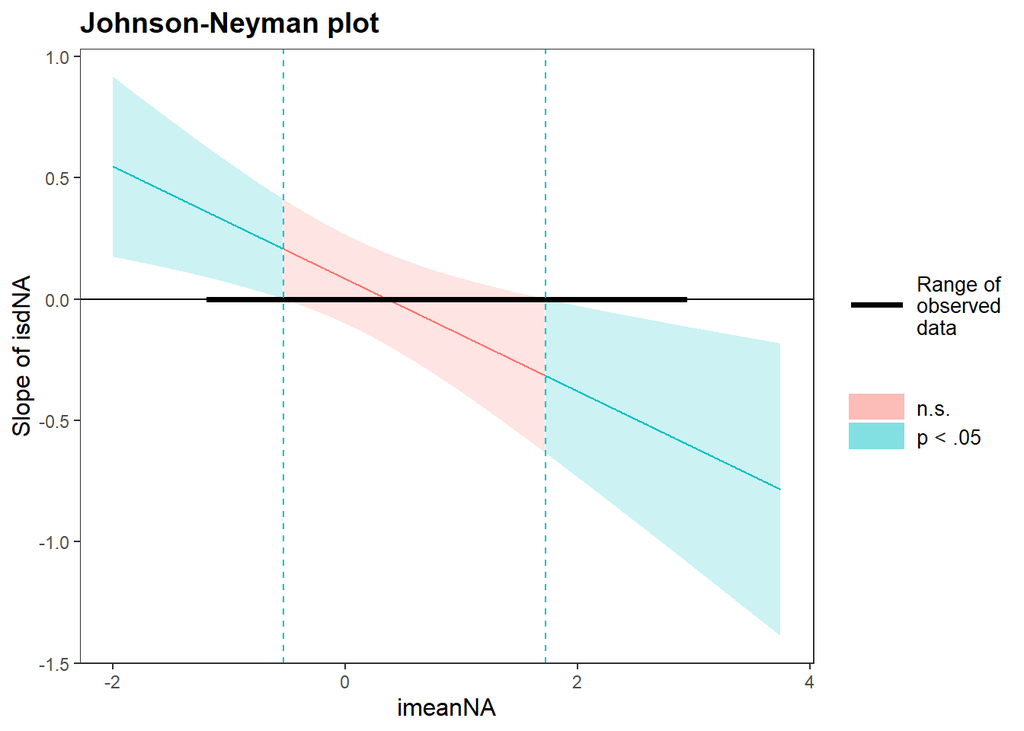

```r
johnson_neyman(lm_Base_NA_SDAR_mod, pred=isdNA, modx=imeanNA, plot = TRUE) #plot
```

##### 6.1.2.2.2 Follow-up Depression

Studies with available data:

- Dataset 1: RADAR
- Dataset 2: Swinging Moods
- Dataset 3: Mood in Emerging Adults

###### 6.1.2.2.2.1 Model 1: Main effects without controlling for affect level

```r
lm_FU_NA_SDAR_main1<-lm(DepF ~ DepB + study_2 + study_3 + isdNA + autocorNA + Age + Sex, data=mega_all_cen_std_3)
summ(lm_FU_NA_SDAR_main1,digits = getOption("jtools-digits", 3))
```

| Observations | 718 (165 missing obs. deleted) |
| --- | --- |
| Dependent variable | DepF |
| Type | OLS linear regression |

| F(7,710) | 34.267 |
| --- | --- |
| R² | 0.253 |
| Adj. R² | 0.245 |

|  | Est. | S.E. | t val. | p |
| --- | --- | --- | --- | --- |
| (Intercept) | -0.115 | 0.477 | -0.241 | 0.810 |
| DepB | 0.405 | 0.035 | 11.427 | 0.000 |
| study_2 | -0.066 | 0.093 | -0.708 | 0.479 |
| study_3 | -0.115 | 0.254 | -0.453 | 0.651 |
| isdNA | 0.422 | 0.083 | 5.117 | 0.000 |
| autocorNA | 0.093 | 0.253 | 0.366 | 0.715 |
| Age | 0.003 | 0.036 | 0.087 | 0.931 |
| Sex1 | 0.209 | 0.075 | 2.788 | 0.005 |

Standard errors: OLS

```r
summ(lm_FU_NA_SDAR_main1,digits = getOption("jtools-digits", 3),confint = TRUE,scale = TRUE, transform.response = TRUE)
```

| Observations | 718 (165 missing obs. deleted) |
| --- | --- |
| Dependent variable | DepF |
| Type | OLS linear regression |

| F(7,710) | 34.267 |
| --- | --- |
| R² | 0.253 |
| Adj. R² | 0.245 |

|  | Est. | 2.5% | 97.5% | t val. | p |
| --- | --- | --- | --- | --- | --- |
| (Intercept) | -0.080 | -0.269 | 0.109 | -0.830 | 0.407 |
| DepB | 0.392 | 0.325 | 0.460 | 11.427 | 0.000 |
| study_2 | -0.066 | -0.247 | 0.116 | -0.708 | 0.479 |
| study_3 | -0.115 | -0.612 | 0.382 | -0.453 | 0.651 |
| isdNA | 0.180 | 0.111 | 0.249 | 5.117 | 0.000 |
| autocorNA | 0.012 | -0.054 | 0.079 | 0.366 | 0.715 |
| Age | 0.009 | -0.201 | 0.220 | 0.087 | 0.931 |
| Sex1 | 0.209 | 0.062 | 0.356 | 2.788 | 0.005 |

Standard errors: OLS; Continuous variables are mean-centered and scaled by 1 s.d.

###### 6.1.2.2.2.2 Model 2: Main effects with controlling for affect level

```r
lm_FU_NA_SDAR_main2<-lm(DepF ~ DepB + study_2 + study_3 + isdNA + autocorNA + imeanNA + Age + Sex, data=mega_all_cen_std_3)
summ(lm_FU_NA_SDAR_main2,digits = getOption("jtools-digits", 3))
```

| Observations | 718 (165 missing obs. deleted) |
| --- | --- |
| Dependent variable | DepF |
| Type | OLS linear regression |

| F(8,709) | 32.472 |
| --- | --- |
| R² | 0.268 |
| Adj. R² | 0.260 |

|  | Est. | S.E. | t val. | p |
| --- | --- | --- | --- | --- |
| (Intercept) | -0.081 | 0.472 | -0.171 | 0.865 |
| DepB | 0.369 | 0.036 | 10.161 | 0.000 |
| study_2 | -0.058 | 0.092 | -0.629 | 0.529 |
| study_3 | -0.089 | 0.251 | -0.355 | 0.722 |
| isdNA | 0.169 | 0.105 | 1.617 | 0.106 |
| autocorNA | -0.362 | 0.276 | -1.311 | 0.190 |
| imeanNA | 0.237 | 0.061 | 3.890 | 0.000 |
| Age | 0.000 | 0.036 | 0.011 | 0.991 |
| Sex1 | 0.207 | 0.074 | 2.785 | 0.005 |

Standard errors: OLS

```r
summ(lm_FU_NA_SDAR_main2,digits = getOption("jtools-digits", 3),confint = TRUE,scale = TRUE, transform.response = TRUE)
```

| Observations | 718 (165 missing obs. deleted) |
| --- | --- |
| Dependent variable | DepF |
| Type | OLS linear regression |

| F(8,709) | 32.472 |
| --- | --- |
| R² | 0.268 |
| Adj. R² | 0.260 |

|  | Est. | 2.5% | 97.5% | t val. | p |
| --- | --- | --- | --- | --- | --- |
| (Intercept) | -0.088 | -0.276 | 0.100 | -0.921 | 0.358 |
| DepB | 0.357 | 0.288 | 0.426 | 10.161 | 0.000 |
| study_2 | -0.058 | -0.238 | 0.122 | -0.629 | 0.529 |
| study_3 | -0.089 | -0.582 | 0.403 | -0.355 | 0.722 |
| isdNA | 0.072 | -0.015 | 0.160 | 1.617 | 0.106 |
| autocorNA | -0.049 | -0.122 | 0.024 | -1.311 | 0.190 |
| imeanNA | 0.198 | 0.098 | 0.297 | 3.890 | 0.000 |
| Age | 0.001 | -0.207 | 0.209 | 0.011 | 0.991 |
| Sex1 | 0.206 | 0.061 | 0.352 | 2.785 | 0.005 |

Standard errors: OLS; Continuous variables are mean-centered and scaled by 1 s.d.

```r
car::vif(lm_FU_NA_SDAR_main2)
```

```
##      DepB   study_2   study_3     isdNA autocorNA   imeanNA       Age       Sex
##  1.197774  1.537481 12.524878  1.923912  1.345735  2.501935 10.900275  1.253689
```

###### 6.1.2.2.2.3 Model 3: Interaction effects affective dynamics and level

```r
lm_FU_NA_SDAR_mod<-lm(DepF ~ DepB + study_2 + study_3 + isdNA + autocorNA + imeanNA + isdNA:imeanNA + autocorNA:imeanNA + Age + Sex, data=mega_all_cen_std_3)
summ(lm_FU_NA_SDAR_mod,digits = getOption("jtools-digits", 3))
```

| Observations | 718 (165 missing obs. deleted) |
| --- | --- |
| Dependent variable | DepF |
| Type | OLS linear regression |

| F(10,707) | 25.924 |
| --- | --- |
| R² | 0.268 |
| Adj. R² | 0.258 |

|  | Est. | S.E. | t val. | p |
| --- | --- | --- | --- | --- |
| (Intercept) | -0.075 | 0.474 | -0.157 | 0.875 |
| DepB | 0.368 | 0.037 | 10.056 | 0.000 |
| study_2 | -0.064 | 0.094 | -0.685 | 0.494 |
| study_3 | -0.096 | 0.253 | -0.381 | 0.703 |
| isdNA | 0.160 | 0.108 | 1.481 | 0.139 |
| autocorNA | -0.339 | 0.284 | -1.191 | 0.234 |
| imeanNA | 0.249 | 0.069 | 3.599 | 0.000 |
| Age | 0.001 | 0.036 | 0.020 | 0.984 |
| Sex1 | 0.208 | 0.074 | 2.797 | 0.005 |
| isdNA:imeanNA | -0.012 | 0.092 | -0.135 | 0.893 |
| autocorNA:imeanNA | -0.088 | 0.276 | -0.319 | 0.750 |

Standard errors: OLS

```r
summ(lm_FU_NA_SDAR_mod,digits = getOption("jtools-digits", 3),confint = TRUE,scale = TRUE, transform.response = TRUE)
```

| Observations | 718 (165 missing obs. deleted) |
| --- | --- |
| Dependent variable | DepF |
| Type | OLS linear regression |

| F(10,707) | 25.924 |
| --- | --- |
| R² | 0.268 |
| Adj. R² | 0.258 |

|  | Est. | 2.5% | 97.5% | t val. | p |
| --- | --- | --- | --- | --- | --- |
| (Intercept) | -0.077 | -0.277 | 0.123 | -0.758 | 0.449 |
| DepB | 0.356 | 0.287 | 0.426 | 10.056 | 0.000 |
| study_2 | -0.064 | -0.249 | 0.120 | -0.685 | 0.494 |
| study_3 | -0.096 | -0.591 | 0.399 | -0.381 | 0.703 |
| isdNA | 0.068 | -0.022 | 0.159 | 1.482 | 0.139 |
| autocorNA | -0.045 | -0.121 | 0.030 | -1.182 | 0.238 |
| imeanNA | 0.208 | 0.094 | 0.322 | 3.589 | 0.000 |
| Age | 0.002 | -0.207 | 0.211 | 0.020 | 0.984 |
| Sex1 | 0.208 | 0.062 | 0.354 | 2.797 | 0.005 |
| isdNA:imeanNA | -0.004 | -0.069 | 0.060 | -0.135 | 0.893 |
| autocorNA:imeanNA | -0.010 | -0.071 | 0.051 | -0.319 | 0.750 |

Standard errors: OLS; Continuous variables are mean-centered and scaled by 1 s.d.

```r
car::vif(lm_FU_NA_SDAR_mod,type = 'predictor')
```

```
## GVIFs computed for predictors
```

```
##                GVIF Df GVIF^(1/(2*Df))   Interacts With
## DepB       1.212404  1        1.101092             --
## study_2    1.614623  1        1.270678             --
## study_3   12.637506  1        3.554927             --
## isdNA      2.280783  3        1.147310          imeanNA
## autocorNA  2.664620  3        1.177441          imeanNA
## imeanNA    1.314861  5        1.027751 isdNA, autocorNA
## Age       10.906375  1        3.302480             --
## Sex        1.260454  1        1.122700             --
##                                                 Other Predictors
## DepB       study_2, study_3, isdNA, autocorNA, imeanNA, Age, Sex
## study_2       DepB, study_3, isdNA, autocorNA, imeanNA, Age, Sex
## study_3       DepB, study_2, isdNA, autocorNA, imeanNA, Age, Sex
## isdNA                DepB, study_2, study_3, autocorNA, Age, Sex
## autocorNA                DepB, study_2, study_3, isdNA, Age, Sex
## imeanNA                         DepB, study_2, study_3, Age, Sex
## Age       DepB, study_2, study_3, isdNA, autocorNA, imeanNA, Sex
## Sex       DepB, study_2, study_3, isdNA, autocorNA, imeanNA, Age
```